# Validation of the two component model using artificial censoring

26 August 2026

**Associated manuscript: A flexible approach to sequential prediction under intervention**

# 1 Choice of methodology when evaluating model performance using artificial censoring

## 1.1 Motivation

The work of (Keogh and Van Geloven 2024) applies artificial censoring in the validation cohort when anyone deviates from the treatment strategy under which predictions are being made. Inverse probability of artificial censoring weights (IPACWs) are then estimated, and used in a weighted Kaplan-Meier estimator to estimate observed risk in the validation cohort. This observed risk is in a pseudo-population where everybody followed the assigned treatment strategy. This is then compared with the mean predicted risk under intervention. This analysis is also executed within subgroups defined by predicted risk. When using artificial censoring to assess the validation of the two-component model (see section 2), we do not follow this approach. There are a few reasons for this.

Firstly, our data is continuously observed, and 10-year risk scores contain 3652 different possible event times. Given the size of the cohort, the majority of these event times are observed. A weighted Kaplan-Meier requires time-varying weights at every possible event time using interval censored data, which presents a computational problem. One option would be to bin the data at 30/90/180 intervals, and apply weighted Kaplan-Meier estimator to this data. However, the impact of this choice, and magnitude of the bias induced by doing so, is unclear. There are alternative approaches (detailed subsequently in this document) which do not suffer this issue which we prefer.

Secondly, our non-artificial censoring mechanism is not independent from the outcome mechanism. This is primarily due to individuals at high risk of death (censoring event), are generally older and are also more likely to experience a cardiovascular event. Assessment of mean calibration through Kaplan-Meier observed risk vs mean predicted risk will be biased, as the Kaplan-Meier estimate will be biased. This is protected somewhat by looking at weighted Kaplan-Meier vs Mean Predicted risk within groups of individuals with similar risk (i.e. deciles). (Keogh and Van Geloven 2024) state that "*some estimators for evaluating predictive performance in the (non interventiuonal) prediction setting apply inverse probability of censoring weights to account for standard right censoring*". When using such estimators, and independence between the censoring mechanisms, combined weights can be calculated as the product of the inverse probability of censoring weights (IPCWs) and the IPACWs. These combined weights could be used to weight the Kaplan-Meier estimator, however, this feels like an overly complicated solution.

Thirdly, comparing Kaplan-Meier observed risk with mean predicted risk cannot be easily extended to produce calibration curves. Doing so within subgroups defined by predicted risk may often be sufficient, but has it's limitations (primarily results dependent on number of arbitrarily defined groups).(Riley et al. 2024) Given the aforementioned computational issues, and that we must use combined weights due to a dependent non-artificial censoring mechanism, and we prefer to use alternative approaches which do not require estimating both time-varying IPCWs and IPACWs, and that can be easily extended to produce calibration curves.

The methods we choose to use are pseudo-values, and cross sectional approaches looking at who has and hasn't had the event by the time point of interest. Both must be weighted using IPCW's and IPACW's (specifically the product of these, the combined weights). We demonstrate approaches to estimate mean calibration, and produce smoothed calibration curves.

## 1.2 Proposed methodology

We first introduce methodology than can be used to estimate calibration in a validation cohort with right censoring, using IPCWs.

### 1.2.1 Mean calibration

The first suggestion is to use a Horvitz-Thompson Estimator to estimate the mean observed risk, and compare this with mean predicted risk. An outcome indicator is defined for who has ($Y_i(t_{eval}) = 1$) and hasn't ($Y_i(t_{eval}) = 0$) had the event by $t_{eval}$. The indicator itself is multiplied by the weights, and then we take the mean.

$\widehat{R}_{HT}(t_{eval}) = \frac{1}{N} \sum_{i=1}^{N} w_iY_i(t_{eval}) = \frac{\sum_{i=1}^{N} w_iY_i(t_{eval})}{N}.$

The second suggestion is to use a weighted mean estimator in the subset of uncensored individuals at 10 years. This is a Hajek-style estimator. This includes those who have had the event prior to 10 years, or who have not had the event and are uncensored at 10 years. Rather than multiplying the outcome indicator $Y_i(t_{eval})$ by the weight and taking the mean across the whole validation cohort (Horvitz-Thompson), we take a weighted mean in the subset of uncensored individuals $U$:

$\widehat{R}_{Hajek}(t_{eval}) = \frac{ \sum_{i \in U} w_iY_i(t_{eval}) }{ \sum_{i \in U} w_i }.$ The difference between the Hajek style and Horvitz-Thompson estimator, is that the denominator when calculating the mean for the Hajek style estimator is 1/sum(weights), rather than 1/n. More generally, the Hajek style estimator is a stabilised version of the Horvitz-Thompson estimator.

A third approach is the use of weighted pseudo-values. See (Overgaard, Parner, and Pedersen 2019; Binder, Gerds, and Andersen 2014). The mean of the weighted pseudo-values would be compared against the mean predicted risk.

### 1.2.2 Moderate calibration

For the first approach, we extended the Horvitz-Thompson estimator approach for mean calibration to produce calibration curves. We multiply the outcome indicator ($Y_{eval}$) by the weights, and then apply calibration methods that would be used for a linear model (regression weighted outcome on predictions and then estimate fitted values as a function of the predictions). This is done within the entire validation cohort (not just those that are uncensored at $t_{eval}$). We refer to this as smoothed HT approach.

For the second approach, we look in the cohort of individuals uncensored at time $t_{eval}$, and apply methods for producing calibration curves for a binary logistic regression model, with the addition of IPCWs. We refer to this as the BLR-IPCW approach.

The third approach uses the weighted pseudo-values, again appling calibration methods that would be used for a linear model (weighted pseudo-values regressed on predictions and then estimate fitted values as a function of the predictions).

We also consider the use of proportional hazards regression to estimate the calibration curve, following the work of (Austin, Harrell, and Klaveren 2020). Given that this approach regresses the observed survival outcome on the predicted risks using a cox proportional hazards model, the implementation with respect to the IP weights is less clear. This is therefore implemented as a comparator, rather than a proposed analysis when working in an artificially censored cohort.

Finally, I will try and use the PH regression approach of (Austin, Harrell, and Klaveren 2020). Given that this approach regresses the observed survival outcome on the predicted risks using a cox proportional hazards model, the implementation with respect to the weights is less clear. I believe the correct thing to do would be to use the IPACWs, rather than the product of the IPCWs and IPACWs, however I am unsure. Furthermore, these weights should be time-varying.

We report the calibration plot and integrated calibration index (mean magnitude of bias of the calibration curve), E50 (median magnitude of bias), and E90 (90th percentile of the magnitude of bias) for each method.

### 1.2.3 Extension to assess validation in artificially censored cohorts

All these methods can be extended to the setting validating a model in a validation cohort with artificial censoring, in order to evaluate the performance of a prediction under intervention model.

The IPCWs are estimated by fitting a model in the non-artificially censored cohort, to predict the risk of being censored. The IPACWs are estimated by fitting a model in the artificially censored cohort, to predict the risk of being artificially censored. Both weights are calculated by evaluating the probability of being uncensored at $min\{t_{eval}, t_{event}, t_{censored}, t_{artif censored}\}$. The combined weights are defined as $IPCW*IPACW$, as detailed by (Keogh and Van Geloven 2024).

Note, it may feel natural to estimate the IPCWs at $min{t_{eval}, t_{event}, t_{censored}}$, which is the weight that would be estimated in a cohort without artificial censoring. I have tried this and this does not impact results. This minimum of these only changes for individuals who are artificially censored, and these individuals will always contribute zero to the outcome model, and $0*weight = 0$. Therefore either is fine.

# 2 Simulation

We implement a simulation to ensure application of the methodology of (Keogh and Van Geloven 2024) is being applied appropriately, given the metrics for evaluating model performance, data and setting is different from the referenced work.

## 2.1 Simulation setup

We simulate survival times, censoring times, and artificial censoring times. All have exponential hazard. We simulate a cohort of size $N = 500000$.

The regular censoring time and survival time share a single predictor (z) with a log-hazard of 1, proportional hazards. The artificial censoring time and survival time share a single predictor (x) with a log-hazard of 1, proportional hazards. This means both censoring mechanisms are dependent with the outcome. A perfectly specified prediction model is developed in the non-artificially censored cohort. Validation is then assessed in the artificially censored cohort. Weights are estimated following the process defined in the previous section, and compared with weights derived directly from the data generating mechanism, to ensure they are correct. The weights derived directly from the data generating mechanism are used when assessing validation.

## 2.2 Simulation results

We know the prediction model is perfectly specified and risks are correct. The assessment of calibration should therefore indicate near perfect calibration.

### 2.2.1 Mean calibration

Horvitz-Thompson (HT) Estimator of observed risk indicates the model is well calibrated:

```
## Observed HT: 0.418
##  Predicted: 0.413
##  Predicted/observed ratio: 0.987
```

The weighted mean estimator of observed risk in subset of uncensored individuals (Hajek style) also indicates the model is well calibrated:

```
## Observed Hajek: 0.417
##  Predicted: 0.413
##  Predicted/observed ratio: 0.991
```

### 2.2.2 Moderate calibration

Calibration plot and ICI for the smoothed-HT approach indicates the model is well calibrated:

```
## ICI: 0.005778362
```

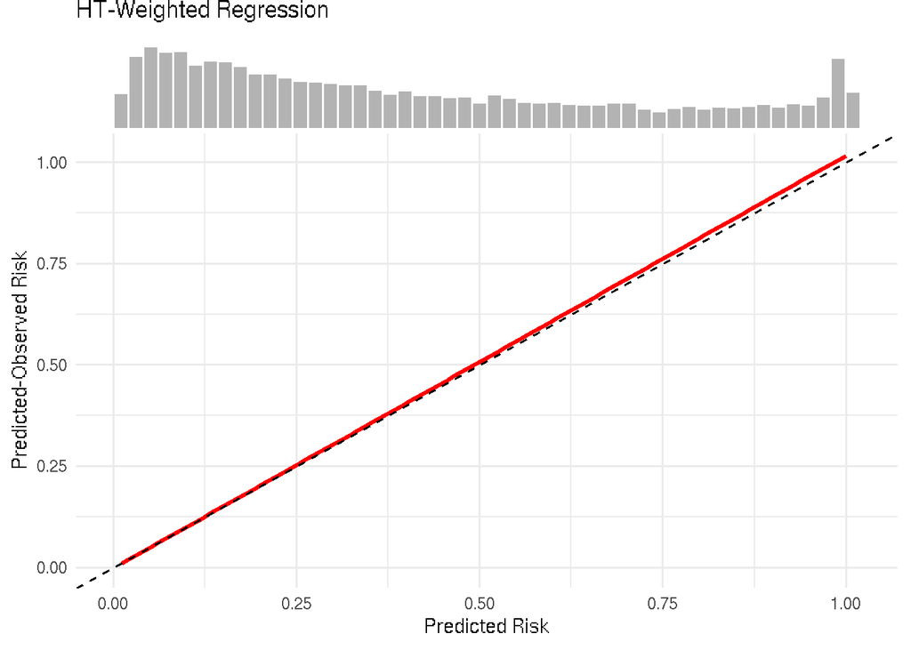

Calibration plot and ICI for the BLR-IPCW approach indicates the model is well calibrated:

```
## ICI: 0.00316427
```

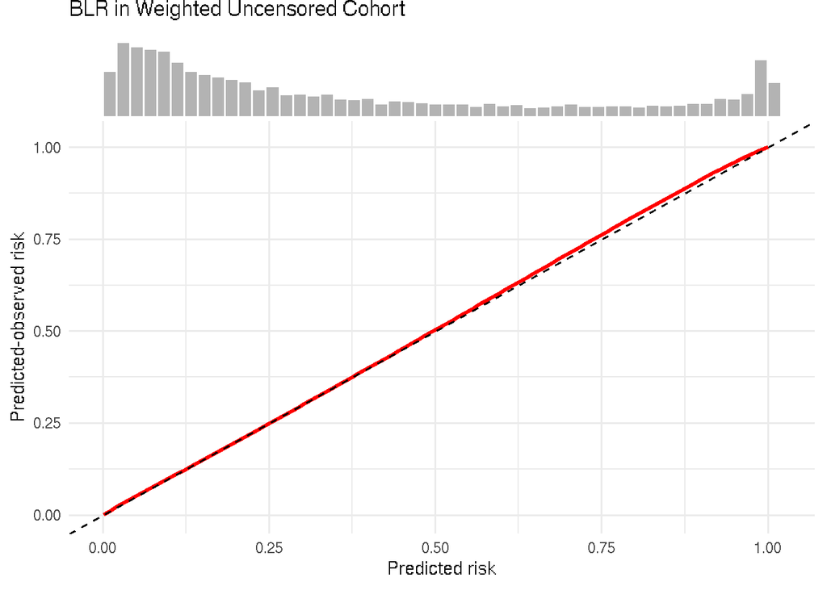

Calibration plot and ICI for the weighted pseudo-value approach indicates the model is well calibrated:

```
## ICI: 0.0058583
```

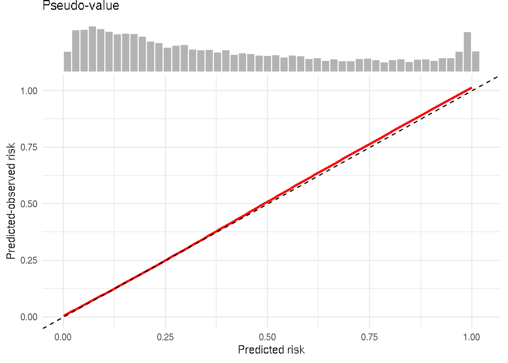

Finally, we will use the proportional hazards regression approach for assessing calibration.(Austin, Harrell, and Klaveren 2020) Given that this approach regresses the observed survival outcome on the predicted risks using a Cox proportional hazards model, the implementation with respect to the weights is less clear. I believe the correct thing to do would be to use the IPACWs, rather than the product of the IPACW and IPCW weights, given the Cox already makes assumptions about the censoring mechanism, however I am unsure about this. Furthermore, these weights should be time-varying.

We implement the method using combined weights (not time-varying), and as expected, this is not appropriate:

```
## ICI: 0.115728
```

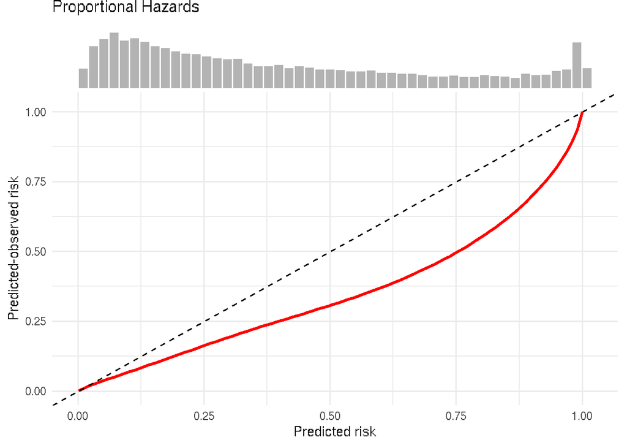

We also implement using just the IPACWs (not time-varying), and find similar results:

```
## ICI: 0.06777245
```

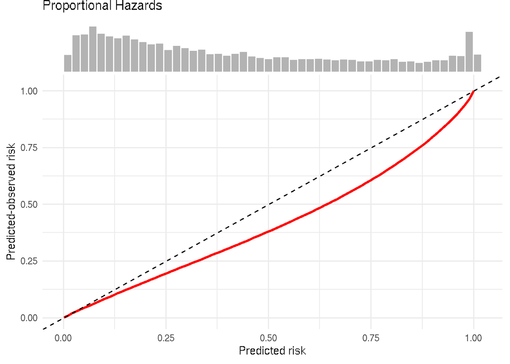

Interestingly though, if we use no weights at all, this approach indicates the model is well calibrated:

```
## ICI: 0.001316977
```

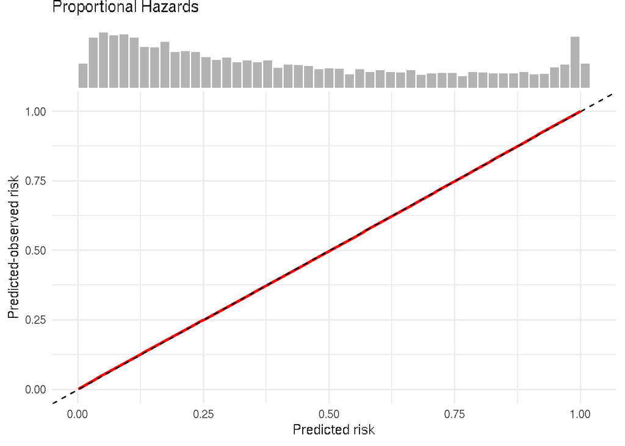

We believe this is because the prediction model is perfectly specified, and therefore the censoring mechanism (combined normal and artificial) is conditionally independent from the outcome in the validation dataset, given the predicted risks. When we start weighting the cohort, this no longer holds. If the prediction model was not perfectly specified, this would also violate this assumption, and the assessment of calibration would be biased. We will therefore avoid this approach in the real data examples.

## 2.3 A note on time-varying confounding

We have ignored time-varying confounding in these simulations. The goal of these simulations was to show how to assess calibration (mean or moderate) using approaches avoiding the Kaplan-Meier estimator. We assumed that we can accurately estimate or know the weights. If there is time-dependent confounding between treatment initiation (artificial censoring) and the outcome, this would need to be reflected in the process for estimating the weights. This could either be a pooled logistic regression model, or an interval censored survival model. However, this does induce extra considerations, as the IPCWs and IPACWs are estimated at $min\{t_{eval}, t_{event}, t_{censored}, t_{artif censored}\}$.

Currently, our models for estimating the weights (cox proportional hazard models) allow us to estimate probabilities of censoring at these exact times. If we use a pooled logistic regression models in order to estimate the weights, then we will lose the ability to do this. This is based on the assumption that the pooled logistic regression model would be implemented within intervals of say 30/90/180/365 days. While a pooled logistic regression model could be implemented with 1 day intervals, again this introduces a large computational burden, and potentially insufficient sample sizes/event rates for the individual logistic regression models.

An alternative is to use interval censored survival models to estimate the weights. This would allow us to both adjustment for time-varying confounding (at say 1 year intervals), and still estimate weights at the exact times of $min\{t_{eval}, t_{event}, t_{censored}, t_{artif censored}\}$. Once estimated, these weights (estimated with adjustment for time-varying confounding), can then be used in the same way as the weights have been throughout this manuscript, in conjunction with the Hajek style/Horvitz Thompson estimators of mean calibration, and the BLR-IPCW, smoothed-HT and weighted pseudo-values approaches for estimating calibration curves. We prefer these approaches over the Kaplan-Meier approach for computational reasons, and more explicit handling of the non-artificial censoring mechanism.

# 3 Validation of the two-component model using inverse probability of artificial censoring weights

## 3.1 Calibration results

We apply IPACW weights as soon as anyone deviates from their treatment at baseline, with respect to statin use, or antihypertensive use. IPCWs are estimated by modelling the entire validation cohort together. IPACWs are estimated using stratified models for those off treatment at baseline, antihypertensives at baseline, statins at baseline, or on both treatments at baseline. Predictors are the same for each model, but due to smaller sample sizes for the latter three cohorts, we do not include interaction terms between age and other predictors in these models. Sample size criteria of (Riley et al. 2024) are adhered to, to minimise risk of overfitting. This is all implemented in program p1_create_validation_data_and_assess_calibration.R. These are the results from the three methods.

**Female cohort:**

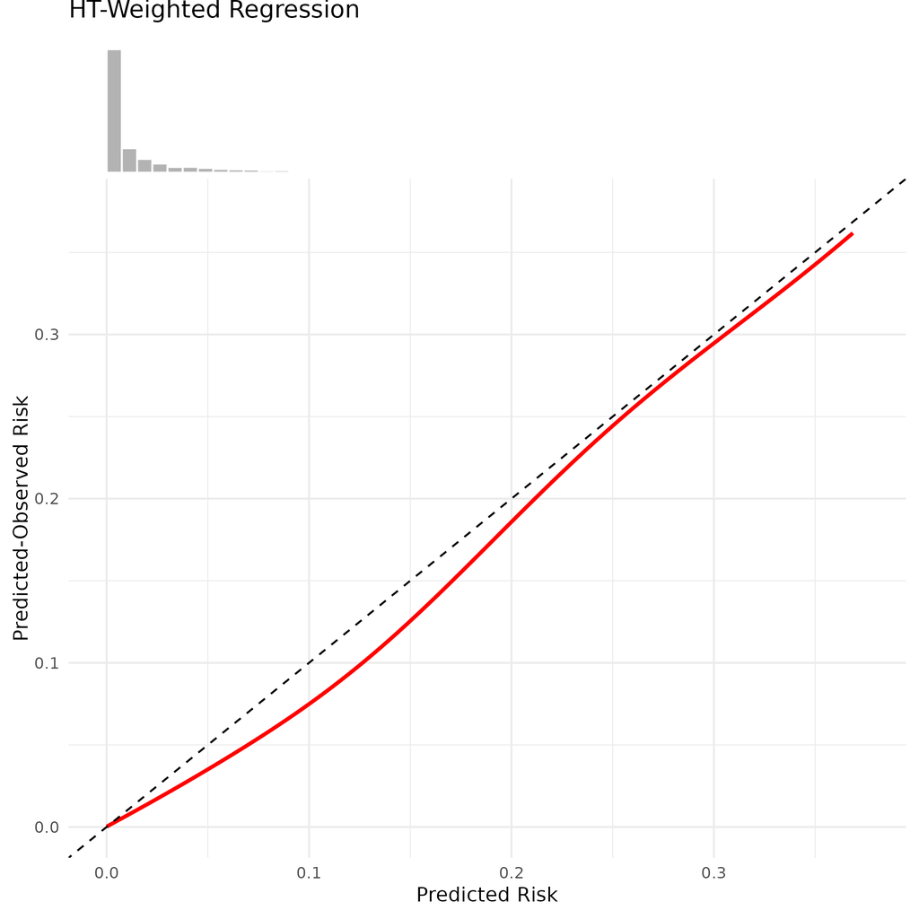

Smoothed-HT

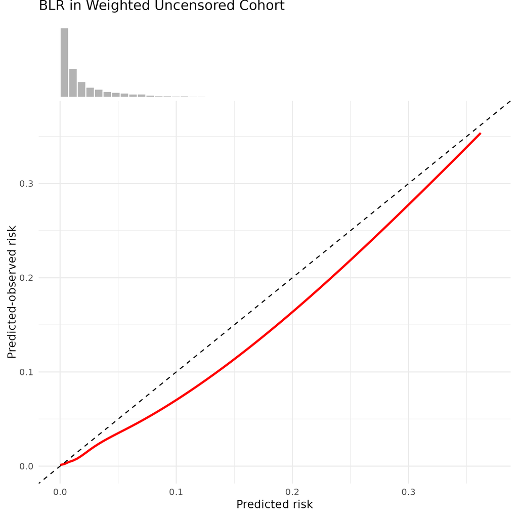

Hajek-style

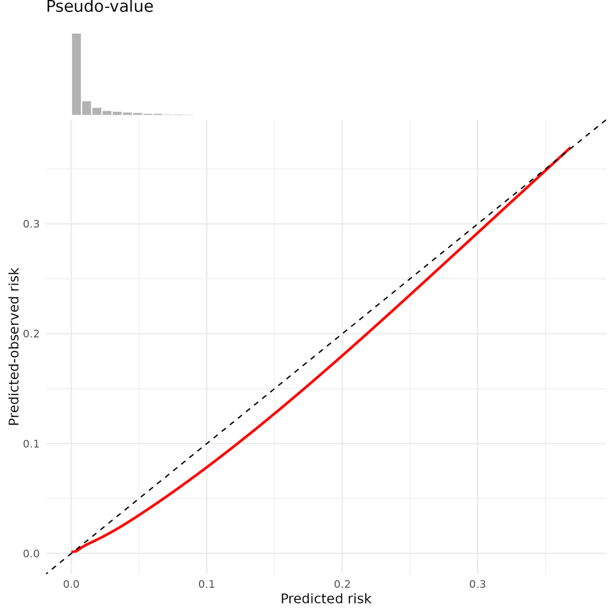

Weighted pseudo-value

**Male cohort:**

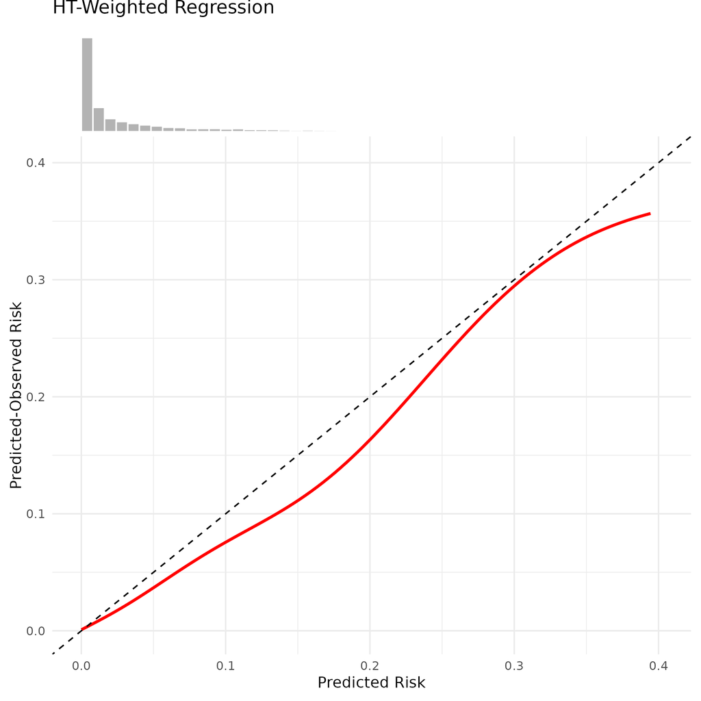

Smoothed-HT

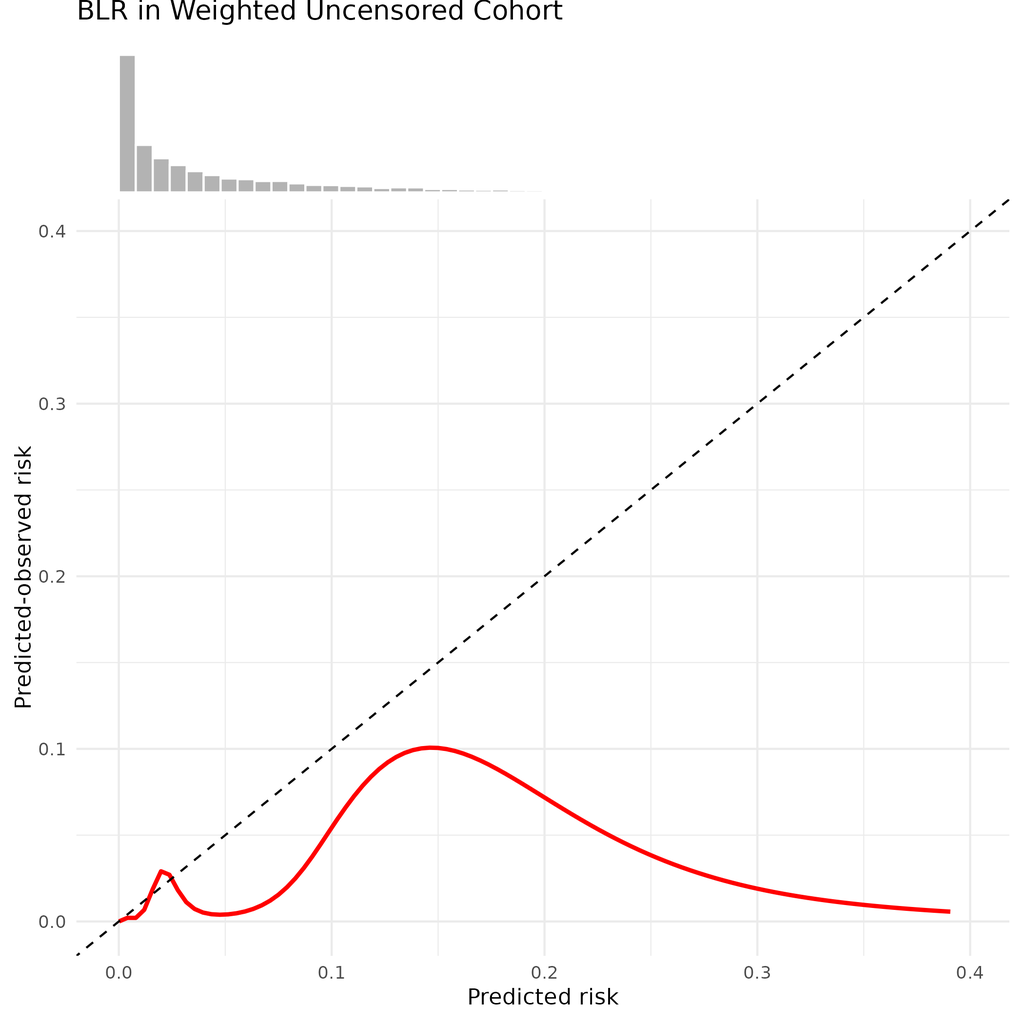

Hajek-style

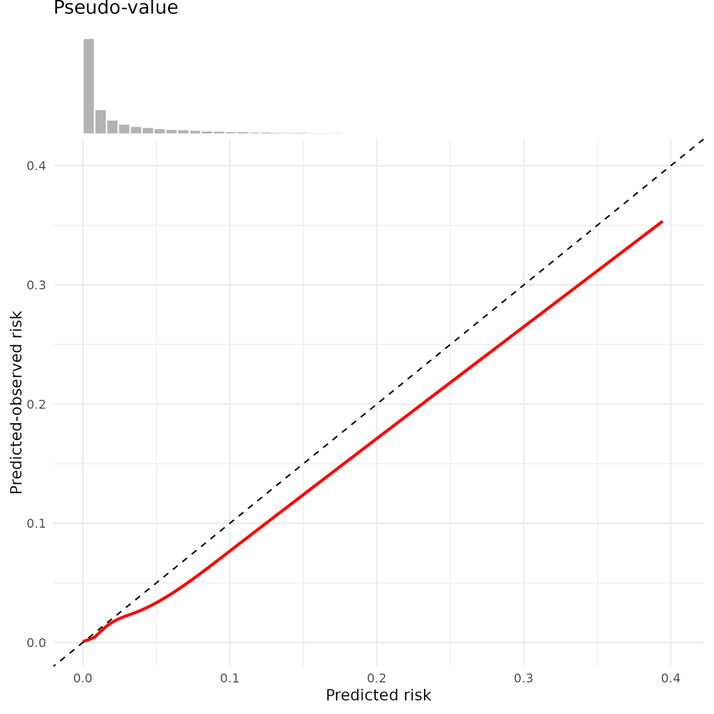

Weighted pseudo-value

Table of calibration metrics:

| Cohort | Method | ICI | E50 | E90 |
| --- | --- | --- | --- | --- |
| Female | BLR | 0.009 | 0.006 | 0.028 |
| Female | Smoothed HT | 0.005 | 0.002 | 0.019 |
| Female | Pseudo-value | 0.006 | 0.002 | 0.019 |
| Male | BLR | 0.039 | 0.008 | 0.068 |
| Male | Smoothed HT | 0.010 | 0.004 | 0.030 |
| Male | Pseudo-value | 0.010 | 0.003 | 0.027 |

We find the model to be miscalibrated for all methods in the same direction for both female and male cohorts. There appears to be a clear issue with the Hajek-style estimator in the male cohort, but the rest present a similar pattern.

It's impossible to say whether the model is really miscalibrated, or there is just a difference between the average conditional treatment effect taken from the literature, vs what can be recovered from the data using the IP weights. The weighting could be subject to a number of assumption violations. In particular, the positivity assumption (we need support to effectively estimate the effect of sustaining treatment for 10 years), as well as conditional exchangeability between the artificial censoring mechanism and the outcome.

A small exploration/summary of key variables in the data follows.

## 3.2 Exploration of the data

We inspect the distribution of the weights. There are some extremely large combined weights (IPCW*IPACW) indicating positivity violations. This is driven primarily by the artificial censoring mechanism, indicating we do not have support for estimating calibration of predictions under sustained treatment for 10 years.

| Cohort | Weights | 50% | 90% | 95% | 97.5% | 99% | 99.9% | 99.99% | 100% |
| --- | --- | --- | --- | --- | --- | --- | --- | --- | --- |
| Female | IPCW | 1.80 | 4.47 | 6.23 | 8.11 | 10.52 | 19.10 | 67.29 | 1390.62 |
| Female | IPACW | 1.08 | 1.54 | 1.92 | 2.37 | 3.11 | 9.75 | 77.83 | 21576.13 |
| Female | Combined | 2.22 | 5.61 | 7.71 | 9.96 | 12.99 | 37.05 | 330.72 | 49144.48 |
| Male | IPCW | 1.84 | 4.36 | 5.44 | 6.29 | 7.48 | 12.21 | 22.92 | 271.75 |
| Male | IPACW | 1.05 | 1.48 | 1.82 | 2.24 | 3.01 | 8.45 | 69.48 | 1545462.00 |
| Male | Combined | 2.19 | 5.20 | 6.28 | 7.40 | 9.66 | 26.71 | 224.09 | 3346185.96 |

We next present a summary of how the number of outcome events and follow-up time changes after artificial censoring is applied. Variables are presented in the original cohort (orig), artificially censored (ac) cohorts. There are also columns for the ratio of number of events and follow-up time in the artificially censored cohort, compared to the original cohort (i.e. what proportion of follow-up time and number of events remains in artificially censored cohort). This is stratified by treatment status at baseline:

| Cohort | on statins | on antihyp | Prop events orig | N events orig | Followup time orig | Prop events ac | N events ac | Followup time ac | Followup time ratio (ac/orig) | N events ratio (ac/orig) |
| --- | --- | --- | --- | --- | --- | --- | --- | --- | --- | --- |
| Male | 0 | 0 | 0.0311914 | 28679 | 5778.51291 | 0.0167948 | 15442 | 5069.95060 | 0.8773798 | 0.5384428 |
| Male | 0 | 1 | 0.1581179 | 9584 | 435.73580 | 0.0811707 | 4920 | 234.89620 | 0.5390794 | 0.5133556 |
| Male | 1 | 0 | 0.1319863 | 1117 | 56.25386 | 0.0450195 | 381 | 25.63067 | 0.4556252 | 0.3410922 |
| Male | 1 | 1 | 0.1766757 | 2027 | 77.43268 | 0.1135710 | 1303 | 53.77249 | 0.6944418 | 0.6428219 |
| Female | 0 | 0 | 0.0195045 | 17622 | 5458.34513 | 0.0096548 | 8723 | 4655.77264 | 0.8529641 | 0.4950062 |
| Female | 0 | 1 | 0.1277524 | 10049 | 604.36603 | 0.0651538 | 5125 | 323.13226 | 0.5346632 | 0.5100010 |
| Female | 1 | 0 | 0.1093318 | 751 | 48.71951 | 0.0366866 | 252 | 21.27467 | 0.4366767 | 0.3355526 |
| Female | 1 | 1 | 0.1641940 | 1804 | 81.18179 | 0.0946573 | 1040 | 53.32090 | 0.6568087 | 0.5764967 |

Furthermore, and most likely, there could be positivity issues, indicated by large weights. We are predicting the risk of a cardiovascular event if sustaining treatment for 10 years. There are a very small percentage of individuals who sustain treatment for this length of time, and do not have an event, meaning the risk set gets very small. We present data on the proportion of individuals who sustain treatment and are followed up for 10 years.

| Cohort | on statins | on antihyp | N | N sustained treatment | Proportion sustained treatment |
| --- | --- | --- | --- | --- | --- |
| Male | 0 | 0 | 919451 | 185817 | 0.2020956 |
| Male | 0 | 1 | 60613 | 7115 | 0.1173841 |
| Male | 1 | 0 | 8463 | 551 | 0.0651069 |
| Male | 1 | 1 | 11473 | 1827 | 0.1592434 |
| Female | 0 | 0 | 903484 | 171654 | 0.1899912 |
| Female | 0 | 1 | 78660 | 10675 | 0.1357107 |
| Female | 1 | 0 | 6869 | 456 | 0.0663852 |
| Female | 1 | 1 | 10987 | 1838 | 0.1672886 |

Truncating the weights to a maximum of 100, or 10, does not have a major impact on the calibration plots, beyond the male plot using the Hajek method now aligning with the others. We still see considerable over-prediction in both the female and male cohorts.

**Female cohort, truncated at 100:**

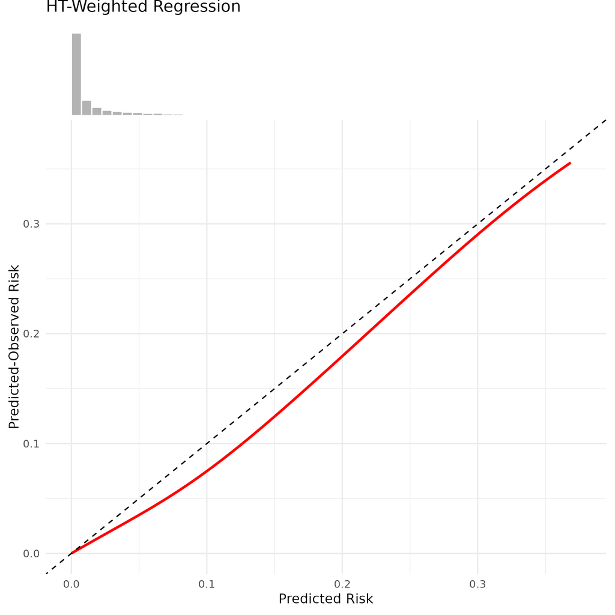

Smoothed-HT

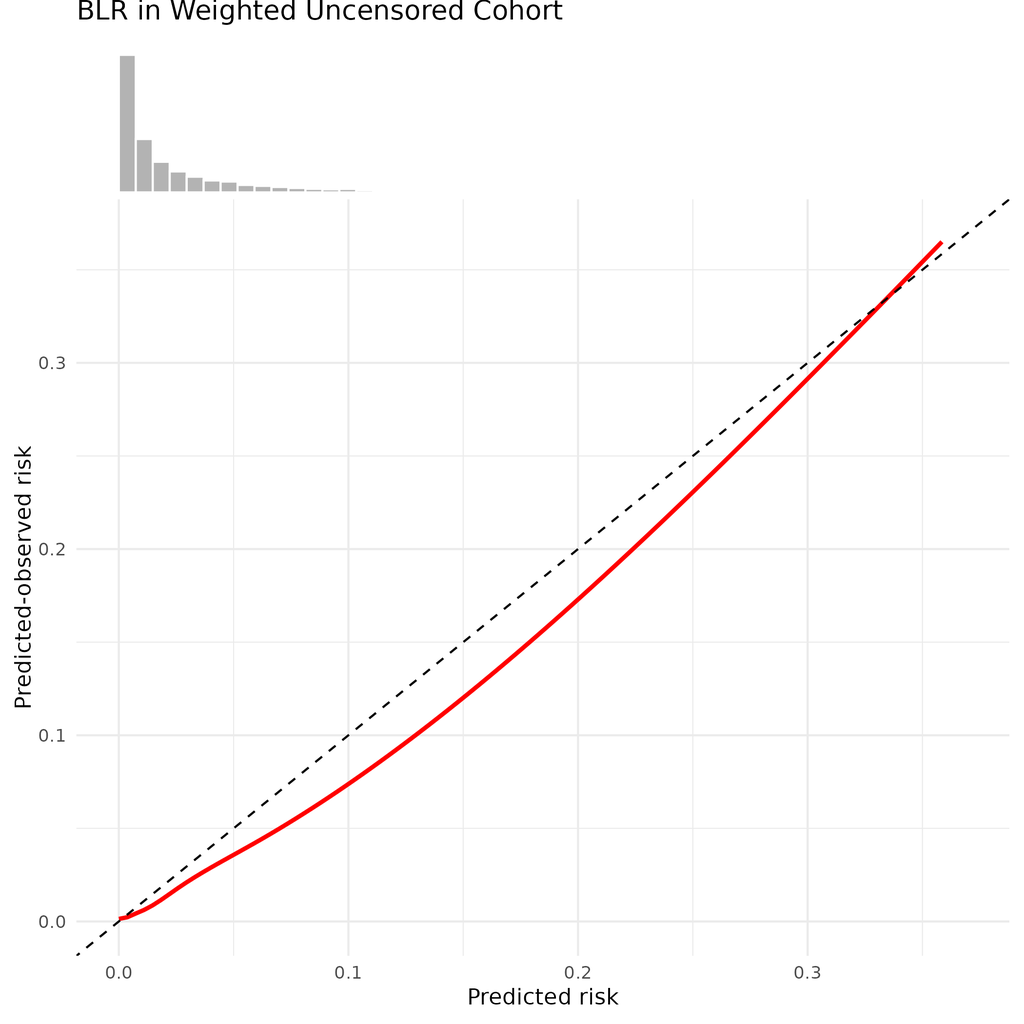

Hajek-style

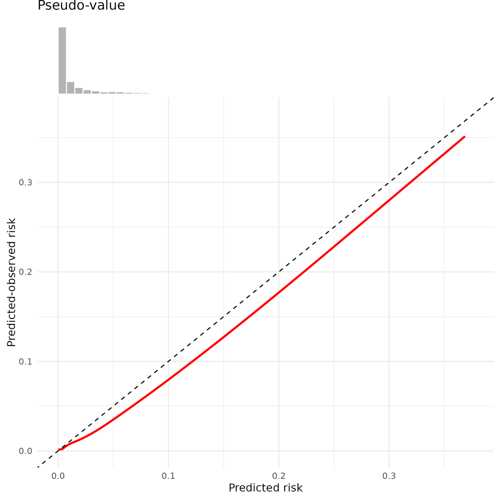

Weighted pseudo-value

**Male cohort, truncated at 100:**

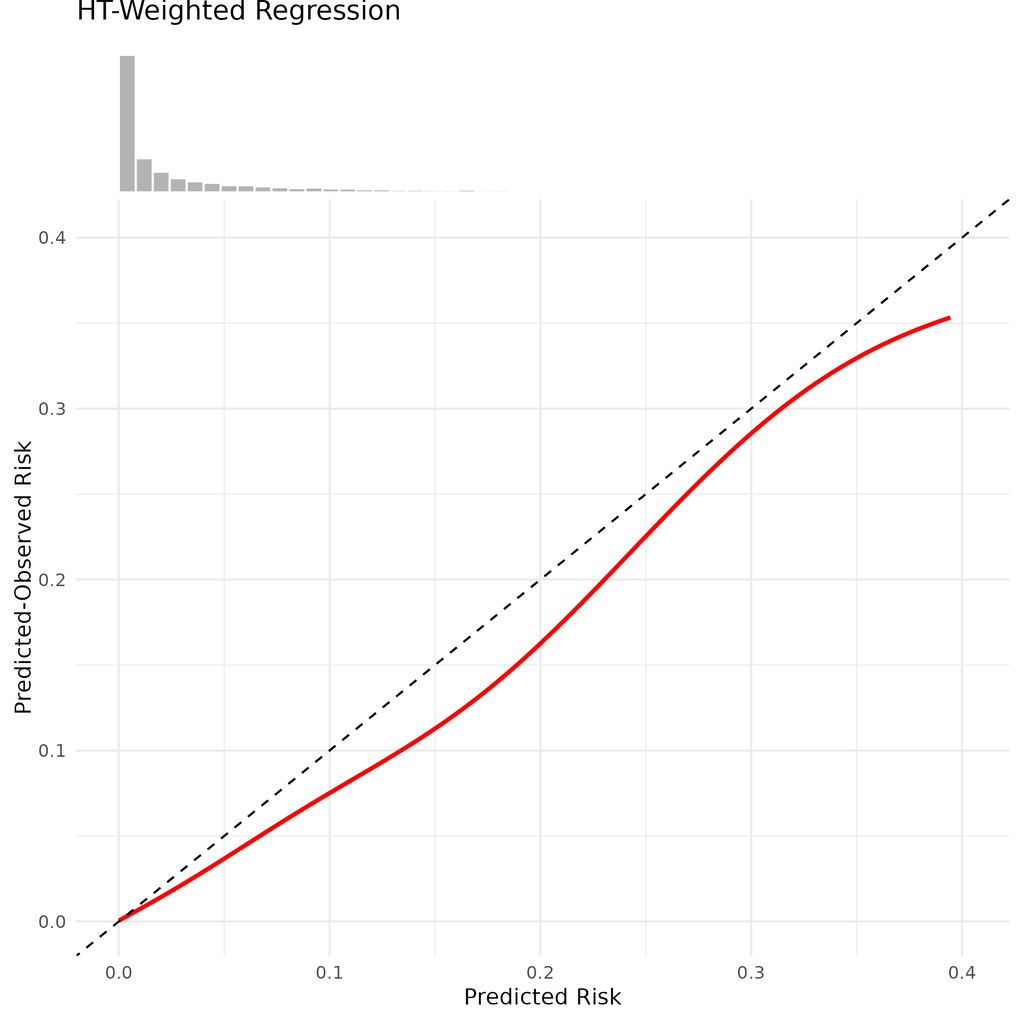

Smoothed-HT

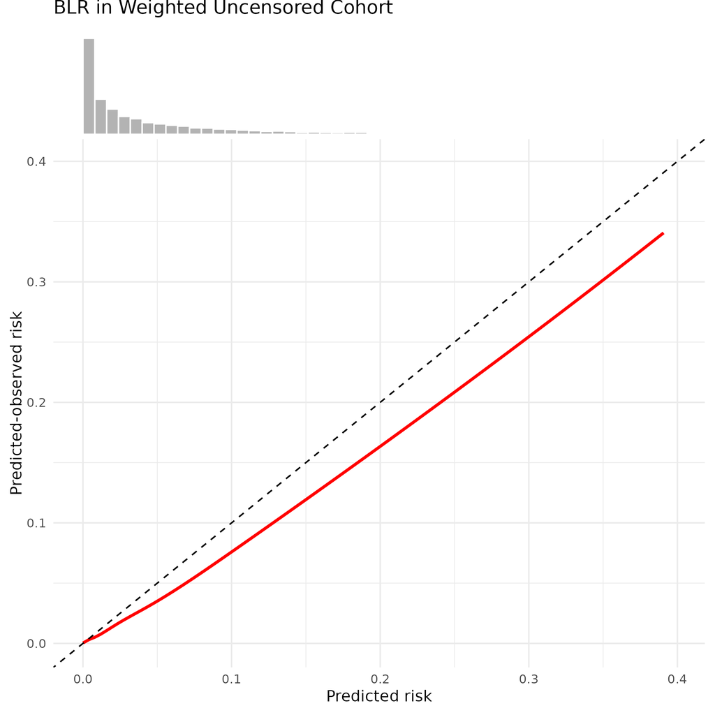

Hajek-style

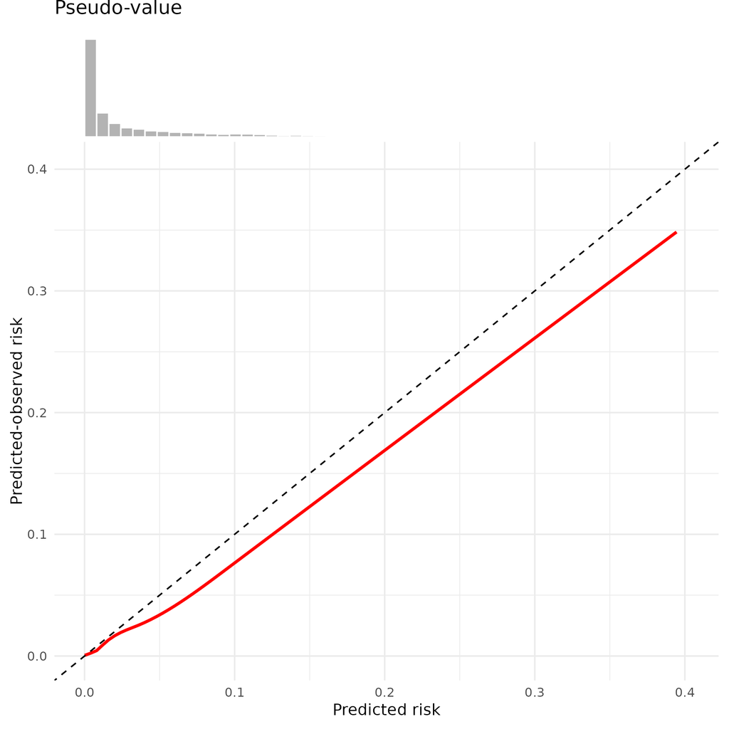

Weighted pseudo-value

**Female cohort, truncated at 10:**

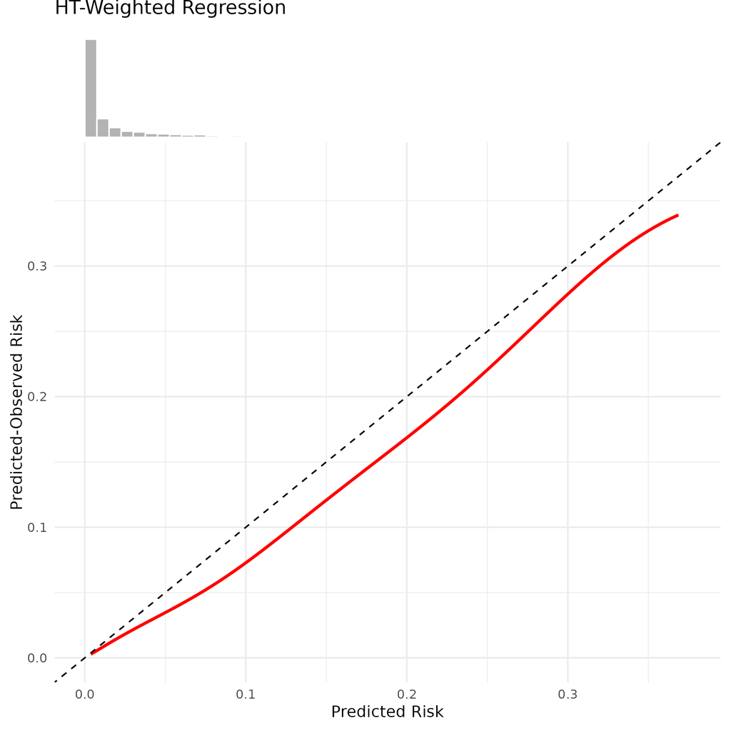

Smoothed-HT

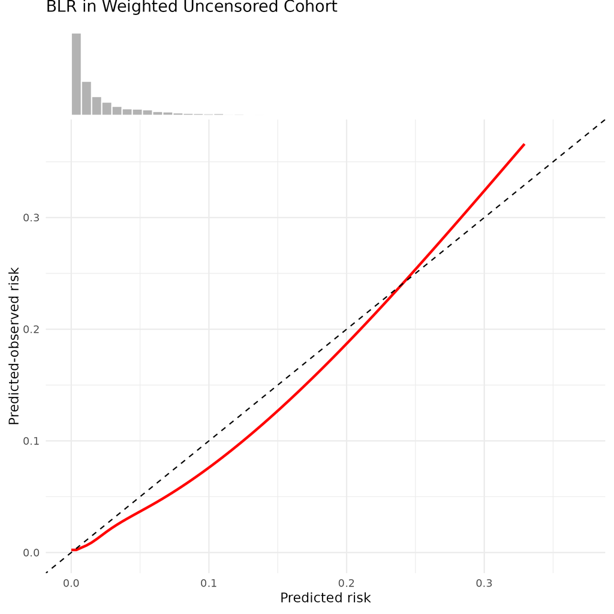

Hajek-style

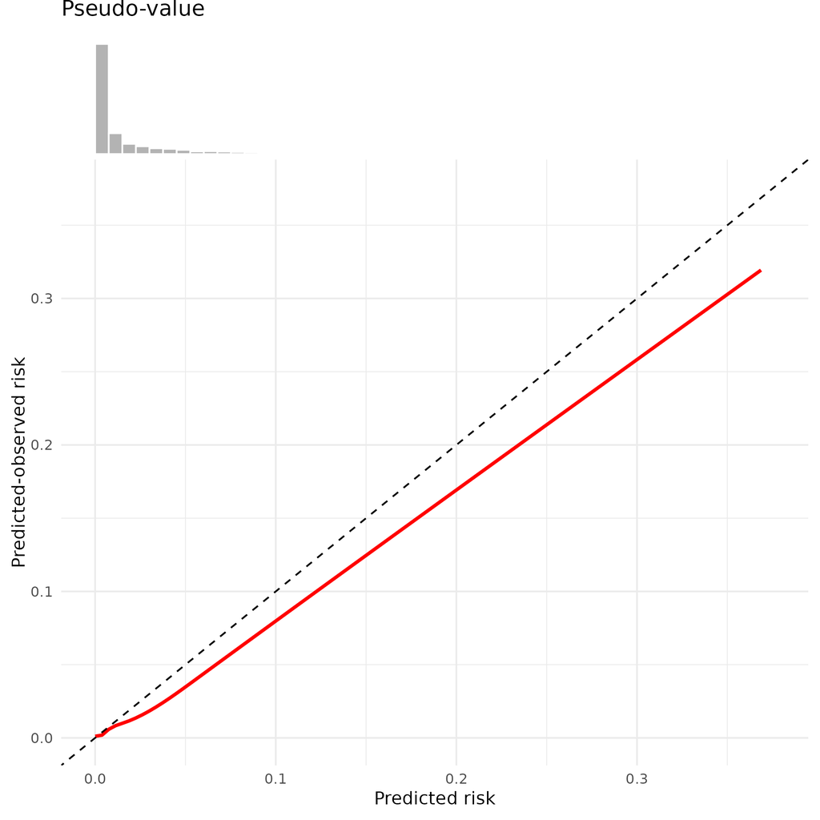

Weighted pseudo-value

**Male cohort, truncated at 10:**

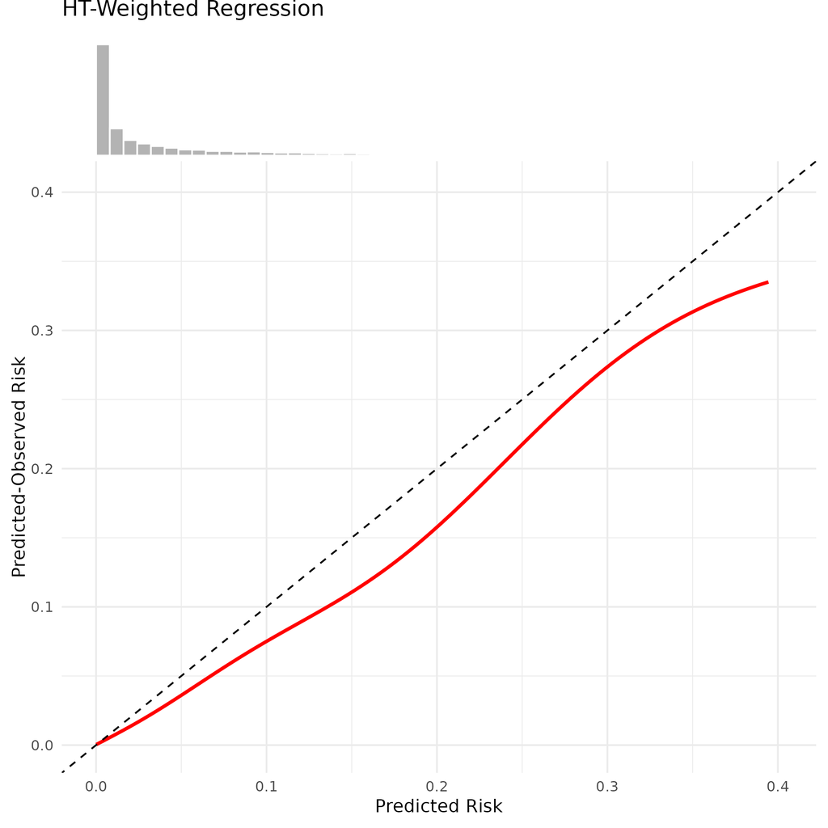

Smoothed-HT

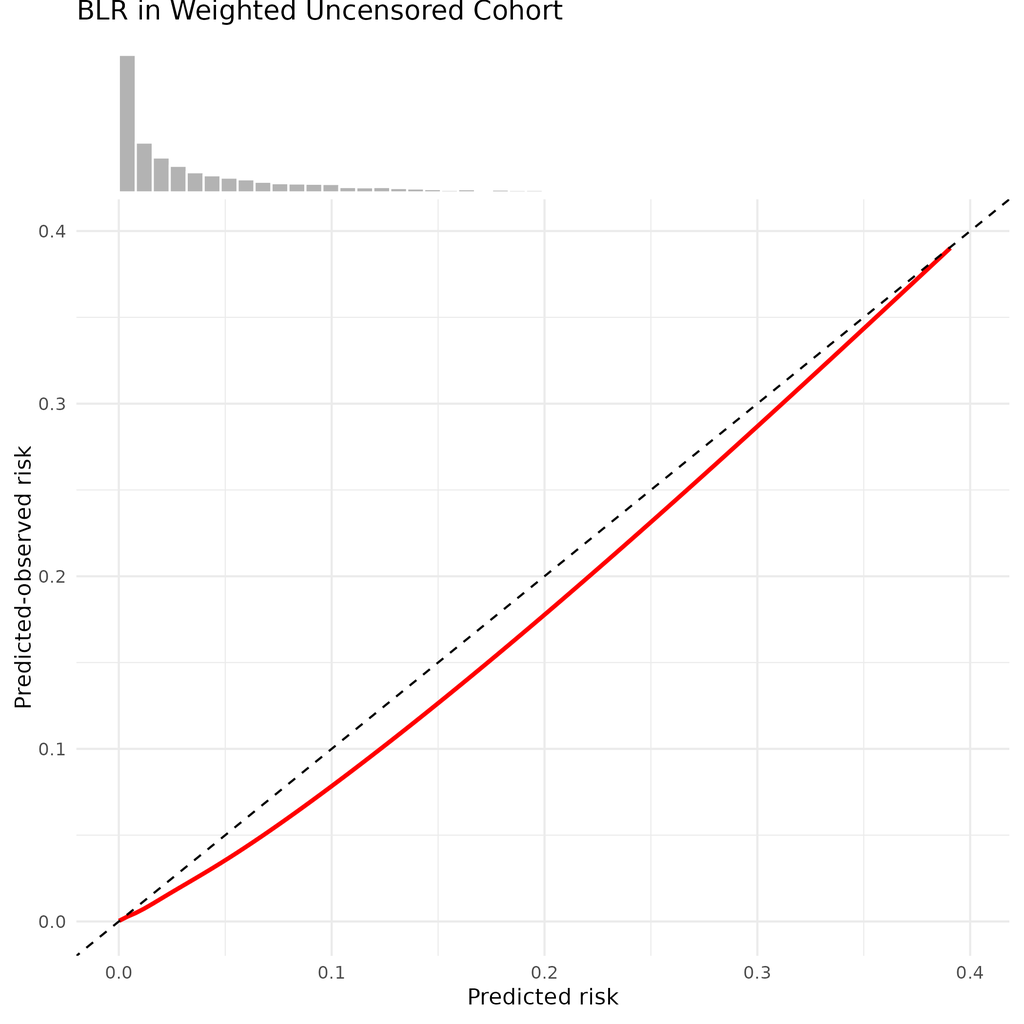

Hajek-style

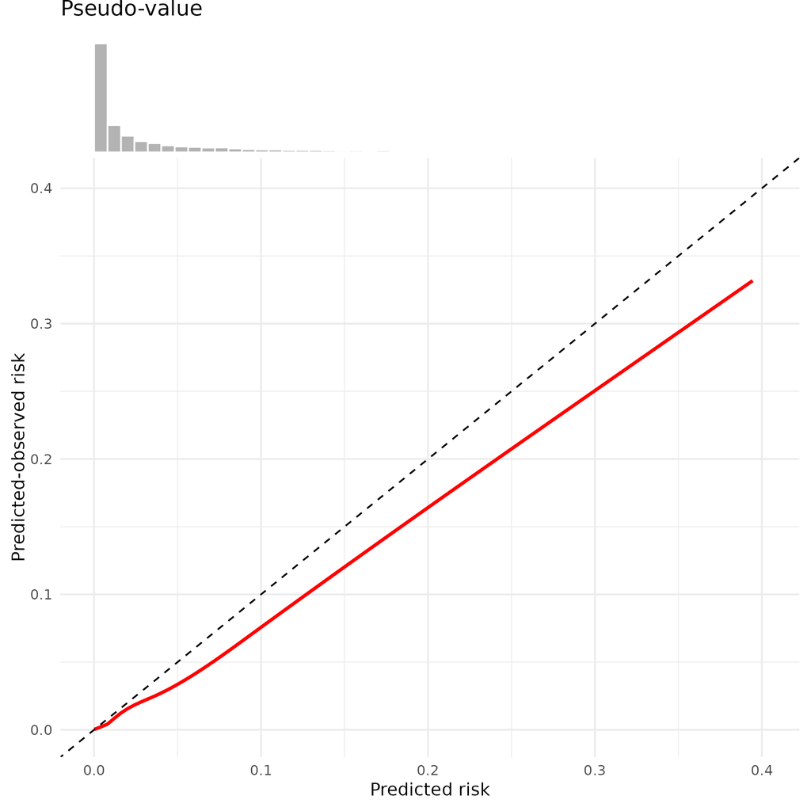

Weighted pseudo-value

To investigate further, we exploit a feature of the artificial censoring approach: in estimating observed risk under a sustained treatment strategy, it implicitly recovers the effect of that strategy through the censoring weights. If those weights were adequate, it would be possible to recover the effects of statin and antihypertensive use, obtaining estimates broadly consistent with the trial evidence. If they are not, the same weights cannot support a calibration estimate either. We therefore attempt this explicitly, at the ten-year horizon and at shorter intervals where positivity violations induced by artificial censoring are less severe. The analysis is reported in Appendix A. The results indicate that there is not sufficient support to estimate the effect of sustaining statin or antihypertensive treatment for 10 years. Relative risk estimates indicate statins and antihypertensive use leading to higher risk of cardiovascular outcomes, in the opposite direction to the trial evidence.

# 4 Summary

In summary, evaluation of calibration using the artificial censoring approach of Keogh and van Geloven indicates a miscalibrated model. There are two possible explanations: either the model is miscalibrated, or the assumptions underpinning the analysis are violated and the evaluation of calibration is not correct. The diagnostics we have examined point to clear violations in positivity, and the recovered causal effects are qualitatively reversed compared with the trial estimates. Because the assumptions required for this evaluation are not met, the exercise cannot inform us about the calibration of the model.

# 5 References

# 6 Appendix

This section summarises the results of an analysis to estimate the causal effect of sustained statin and antihypertensive treatment on cardiovascular disease risk. Analyses were conducted separately for statins and antihypertensives. We use artificial censoring in combination with IP weighting to estimate the effects. The process of artificial censoring and estimation of weights (IPCW and IPACW) is similar to the analysis used to estimate the calibration (Keogh and Van Geloven 2024). Given the effect of statins and antihypertensives are broadly known, this allows us to compare the estimates to a ground truth, unlike when assessing the calibration of the prediction models. This provides further evidence about the validity of estimation and usage of such weights in this cohort.

The entire cohort (development + validation) were combined. We aimed to estimate the risk under no-intervention (p0) and risk under sustained treatment (p1). The relative risk reduction is estimated as the ratio of these (p1/p0). Values below 1 indicate a protective effect of treatment. We therefore created two cohorts. One where individuals were artificially censored as soon as they initiated treatment (instantly censoring those on treatment at baseline), and a second where individuals were artificially censored as soon as they stopped receiving treatment (instantly censoring those off treatment at baseline). We estimate the risk at 1/3/5/10 years follow-up in these two cohorts using weights via a Horvitz-Thompson style estimator, and a Hajek-style estimator.

The weights used to estimate p0 and p1 were combined weights IPCW × IPACW × IPTW. The IPCWs and IPACWs were estimated as defined previously. The IPTWs are inverse probability of treatment weights when estimating p1, or inverse probability of untreated if calculating p0, and are the inverse of the probability of the receiving treatment which individuals were on at baseline. Under these weights, we can create pseudo-populations as if the whole population had either been treated, or untreated, over the follow-up horizon of interest.

Treatment use was defined in the same way as in the main analysis with a 180 wash-out period. We used all the same predictors for estimating the weights and included splines on continuous variables. Two weighting models were used, one with no interaction terms, and another where all predictors were interacted with age.

As a result of finding highly unstable relative risk estimates and some really extreme weights/small effective sample sizes, indicative of violations of the positivity assumption, we also implement these analyses in overlap cohorts. This is where the cohort is restricted to individuals who had a reasonable probability of receiving either treatment (our threshold is 1%). We create two overlap cohorts. The first (*`Overlap cohort 1`*) restricts to individuals with sufficient probability of receiving either treatment at baseline (> 1%). The second (*`Overlap cohort 2`*) applies this restriction, but also restricts to those with probability of sustaining the treatment they did receive for the follow-up interval, i.e. probability of not being artificially censored over prediction interval > 1%; and probability of being observed for follow-up interval, i.e. not being censored from standard censoring mechanism > 1%. While these analyses alter the target population, we assume the effect of statins and antihypertensives to be reasonably homogeneous, the estimand should remain similar, but this should reduce violations of the positivity assumption, leading to more stable estimates.

We prefer estimation in overlap cohorts as opposed to truncating the weights. Extreme weights indicate there is little information in the data about this treatment strategy for the highly weighted individuals. Truncation will bias the estimator in order to improve variance, but the issue of positivity remains. Overlap restriction removes observations with little or no support before estimation, dealing with the cause of extreme weights, whereas truncation addresses the consequences of extreme weights. Both do have value, but we have opted to create overlap cohorts.

## 6.1 Relative Risk Estimates

Green RR values indicate a protective treatment effect (RR < 1). Red values indicate the estimate is in the wrong direction, which may signal positivity violations or other issues (see diagnostics sections below).

The **effective sample size (ESS)** for each treatment group is also included in the Table. This is calculated using the Kish formula:

$\text{ESS} = \frac{(\sum w_i)^2}{\sum w_i^2}$

The ESS equals N when all weights are equal, and falls below N when weights are variable. A low ESS (expressed as a % of N) indicates that a small number of highly-weighted individuals are driving the analysis, which undermines the reliability of the estimates regardless of the nominal sample size. The table below shows the ESS at the final combined weighting stage (IPCW × IPACW × IPTW) alongside the actual sample size, for both cohorts. ESS% values below 10% are shown in red; below 25% in orange.

Relative risk estimates and ESS by cohort, medication, gender, follow-up, and model

| Cohort | Med | Gender | Follow-up (years) | Age interactions | p0_hajek | p1_hajek | RR_hajek | p0_ht | p1_ht | RR_ht | N (untreated) | ESS (untreated) | ESS% (untreated) | N (treated) | ESS (treated) | ESS% (treated) |
| --- | --- | --- | --- | --- | --- | --- | --- | --- | --- | --- | --- | --- | --- | --- | --- | --- |
| Entire cohort | statins | Female | 1 | No | 0.0031 | 0.0057 | 1.797 | 0.0032 | 0.0056 | 1.775 | 9545467 | 7338860 | 76.9 | 354098 | 1360 | 0.4 |
|  |  |  | 1 | Yes | 0.0030 | 0.0052 | 1.748 | 0.0030 | 0.0054 | 1.827 | 9545467 | 1800737 | 18.9 | 354098 | 915 | 0.3 |
|  |  |  | 3 | No | 0.0093 | 0.0146 | 1.566 | 0.0098 | 0.0158 | 1.611 | 9545467 | 1828 | 0.0 | 354098 | 538 | 0.2 |
|  |  |  | 3 | Yes | 0.0091 | 0.0146 | 1.611 | 0.0091 | 0.0167 | 1.828 | 9545467 | 997476 | 10.4 | 354098 | 418 | 0.1 |
|  |  |  | 5 | No | 0.0141 | 0.0221 | 1.568 | 0.0175 | 0.0267 | 1.526 | 9545467 | 121 | 0.0 | 354098 | 354 | 0.1 |
|  |  |  | 5 | Yes | 0.0146 | 0.0200 | 1.371 | 0.0159 | 0.0258 | 1.624 | 9545467 | 972 | 0.0 | 354098 | 252 | 0.1 |
|  |  |  | 10 | No | 0.0006 | 0.0185 | 28.531 | 0.0678 | 0.0525 | 0.775 | 9545467 | 1 | 0.0 | 354098 | 18 | 0.0 |
|  |  |  | 10 | Yes | 0.0124 | 0.0347 | 2.795 | 0.1536 | 0.0495 | 0.322 | 9545467 | 1 | 0.0 | 354098 | 68 | 0.0 |
|  |  | Male | 1 | No | 0.0031 | 0.0057 | 1.796 | 0.0032 | 0.0056 | 1.774 | 9545467 | 7341302 | 76.9 | 354098 | 1362 | 0.4 |
|  |  |  | 1 | Yes | 0.0030 | 0.0051 | 1.742 | 0.0030 | 0.0054 | 1.832 | 9545467 | 1789405 | 18.7 | 354098 | 899 | 0.3 |
|  |  |  | 3 | No | 0.0093 | 0.0146 | 1.567 | 0.0098 | 0.0158 | 1.611 | 9545467 | 1846 | 0.0 | 354098 | 541 | 0.2 |
|  |  |  | 3 | Yes | 0.0091 | 0.0146 | 1.614 | 0.0091 | 0.0167 | 1.828 | 9545467 | 998103 | 10.5 | 354098 | 418 | 0.1 |
|  |  |  | 5 | No | 0.0141 | 0.0221 | 1.570 | 0.0175 | 0.0267 | 1.526 | 9545467 | 120 | 0.0 | 354098 | 356 | 0.1 |
|  |  |  | 5 | Yes | 0.0146 | 0.0200 | 1.369 | 0.0159 | 0.0258 | 1.622 | 9545467 | 1090 | 0.0 | 354098 | 254 | 0.1 |
|  |  |  | 10 | No | 0.0007 | 0.0185 | 27.930 | 0.0684 | 0.0525 | 0.768 | 9545467 | 1 | 0.0 | 354098 | 18 | 0.0 |
|  |  |  | 10 | Yes | 0.0125 | 0.0351 | 2.798 | 0.1533 | 0.0500 | 0.326 | 9545467 | 1 | 0.0 | 354098 | 68 | 0.0 |
|  | Antihyp | Female | 1 | No | 0.0040 | 0.0073 | 1.803 | 0.0041 | 0.0055 | 1.323 | 9015065 | 1129540 | 12.5 | 884500 | 58091 | 6.6 |
|  |  |  | 1 | Yes | 0.0032 | 0.0064 | 1.989 | 0.0032 | 0.0052 | 1.594 | 9015065 | 1121163 | 12.4 | 884500 | 48032 | 5.4 |
|  |  |  | 3 | No | 0.0122 | 0.0145 | 1.188 | 0.0128 | 0.0155 | 1.214 | 9015065 | 74955 | 0.8 | 884500 | 4702 | 0.5 |
|  |  |  | 3 | Yes | 0.0092 | 0.0123 | 1.327 | 0.0093 | 0.0145 | 1.558 | 9015065 | 463458 | 5.1 | 884500 | 4102 | 0.5 |
|  |  |  | 5 | No | 0.0219 | 0.0150 | 0.687 | 0.0283 | 0.0258 | 0.912 | 9015065 | 164 | 0.0 | 884500 | 639 | 0.1 |
|  |  |  | 5 | Yes | 0.0176 | 0.0141 | 0.801 | 0.0182 | 0.0248 | 1.362 | 9015065 | 149290 | 1.7 | 884500 | 789 | 0.1 |
|  |  |  | 10 | No | 0.0421 | 0.0067 | 0.159 | 0.1059 | 0.0618 | 0.583 | 9015065 | 1 | 0.0 | 884500 | 23 | 0.0 |
|  |  |  | 10 | Yes | 0.0213 | 0.0117 | 0.549 | 0.0427 | 0.0694 | 1.627 | 9015065 | 127 | 0.0 | 884500 | 103 | 0.0 |
|  |  | Male | 1 | No | 0.0040 | 0.0073 | 1.810 | 0.0041 | 0.0055 | 1.327 | 9015065 | 1182960 | 13.1 | 884500 | 58051 | 6.6 |
|  |  |  | 1 | Yes | 0.0032 | 0.0064 | 1.994 | 0.0032 | 0.0052 | 1.592 | 9015065 | 1121051 | 12.4 | 884500 | 48172 | 5.4 |
|  |  |  | 3 | No | 0.0121 | 0.0145 | 1.198 | 0.0127 | 0.0155 | 1.220 | 9015065 | 68228 | 0.8 | 884500 | 4724 | 0.5 |
|  |  |  | 3 | Yes | 0.0092 | 0.0123 | 1.328 | 0.0093 | 0.0145 | 1.556 | 9015065 | 580854 | 6.4 | 884500 | 4169 | 0.5 |
|  |  |  | 5 | No | 0.0521 | 0.0151 | 0.289 | 0.0691 | 0.0258 | 0.373 | 9015065 | 172 | 0.0 | 884500 | 642 | 0.1 |
|  |  |  | 5 | Yes | 0.0177 | 0.0143 | 0.811 | 0.0182 | 0.0248 | 1.359 | 9015065 | 161745 | 1.8 | 884500 | 766 | 0.1 |

[output cut: 66 more lines]

## 6.2 Diagnostics

We look at effective sample size (ESS), broken down by each weight, and the distribution of weights.

The following tables break down the ESS loss at each weighting stage — IPCW, IPACW, IPTW, and the combined weight. This helps identify which component of the weighting is driving the ESS collapse. ESS% values below 10% are shown in red; below 25% in orange.

**IPCW** (Inverse Probability of Censoring Weights) corrects for informative censoring — individuals who are lost to follow-up for reasons related to their risk. High IPCW weights indicate that some individuals had a very low predicted probability of remaining uncensored, meaning the model is trying to upweight a small group to represent a much larger one.

**IPACW** (Inverse Probability of Adherence to Censoring Weights) corrects for artificial censoring — individuals who deviate from their assigned treatment strategy (sustained treatment or sustained non-treatment) are censored, and IPACW reweights the remaining individuals to represent the full population. High IPACW weights arise when some individuals have a very low predicted probability of sustaining their assigned strategy.

**IPTW** (Inverse Probability of Treatment Weights) balances the treated and untreated groups at baseline on measured confounders. High IPTW weights arise when some individuals have a propensity score close to 0 or 1, indicating near-deterministic treatment assignment.

### 6.2.1 Entire cohort — Statins — Female — Age interactions: No

**Table: ESS diagnostics**

| Follow-up | Stage | ESS (overall) | ESS% (overall) | ESS (untreated) | ESS% (untreated) | ESS (treated) | ESS% (treated) |
| --- | --- | --- | --- | --- | --- | --- | --- |
| 1 | IPCW | 9821720 | 99.2 | 9471105 | 99.2 | 353023 | 99.7 |
|  | IPACW | 9881094 | 99.8 | 9535869 | 99.9 | 351805 | 99.4 |
|  | IPCW×IPACW | 9826069 | 99.3 | 9477788 | 99.3 | 349234 | 98.6 |
|  | IPTW | 1857246 | 18.8 | 8339922 | 87.4 | 2655 | 0.7 |
|  | Combined | 564386 | 5.7 | 7338860 | 76.9 | 1360 | 0.4 |
| 3 | IPCW | 9154962 | 92.5 | 8827894 | 92.5 | 345236 | 97.5 |
|  | IPACW | 134607 | 1.4 | 123271 | 1.3 | 344942 | 97.4 |
|  | IPCW×IPACW | 221571 | 2.2 | 206096 | 2.2 | 324680 | 91.7 |
|  | IPTW | 1857246 | 18.8 | 8339922 | 87.4 | 2655 | 0.7 |
|  | Combined | 2021 | 0.0 | 1828 | 0.0 | 538 | 0.2 |
| 5 | IPCW | 8169156 | 82.5 | 7874409 | 82.5 | 331204 | 93.5 |
|  | IPACW | 11129 | 0.1 | 10162 | 0.1 | 337625 | 95.3 |
|  | IPCW×IPACW | 20125 | 0.2 | 18739 | 0.2 | 284469 | 80.3 |
|  | IPTW | 1857246 | 18.8 | 8339922 | 87.4 | 2655 | 0.7 |
|  | Combined | 134 | 0.0 | 121 | 0.0 | 354 | 0.1 |
| 10 | IPCW | 5197972 | 52.5 | 5010831 | 52.5 | 249235 | 70.4 |
|  | IPACW | 6 | 0.0 | 6 | 0.0 | 309124 | 87.3 |
|  | IPCW×IPACW | 6 | 0.0 | 6 | 0.0 | 17621 | 5.0 |
|  | IPTW | 1857246 | 18.8 | 8339922 | 87.4 | 2655 | 0.7 |
|  | Combined | 1 | 0.0 | 1 | 0.0 | 18 | 0.0 |

**Table: Weight distributions**

| Follow-up (years) | Stage | Group | N | Median | P90 | P95 | P99 | P99.9 | Max |
| --- | --- | --- | --- | --- | --- | --- | --- | --- | --- |
| 1 | IPCW | Treated | 354098 | 1.090 | 1.162 | 1.197 | 1.292 | 1.522 | 5.4 |
|  | IPACW |  |  | 1.131 | 1.233 | 1.282 | 1.468 | 1.977 | 6.4 |
|  | IPCW x IPACW |  |  | 1.244 | 1.393 | 1.477 | 1.783 | 2.559 | 8.2 |
|  | IPTW |  |  | 0.141 | 0.881 | 1.569 | 10.052 | 137.162 | 1037.8 |
|  | Combined |  |  | 0.174 | 1.137 | 2.090 | 15.226 | 254.799 | 3273.7 |
|  | IPCW | Untreated | 9545467 | 1.193 | 1.320 | 1.359 | 1.479 | 1.634 | 6.2 |
|  | IPACW |  |  | 1.002 | 1.031 | 1.045 | 1.094 | 1.358 | 29.8 |
|  | IPCW x IPACW |  |  | 1.199 | 1.323 | 1.364 | 1.490 | 1.658 | 31.7 |
|  | IPTW |  |  | 0.966 | 1.025 | 1.100 | 1.471 | 6.066 | 87.6 |
|  | Combined |  |  | 1.179 | 1.298 | 1.368 | 1.727 | 8.542 | 537.7 |
| 3 | IPCW | Treated | 354098 | 1.236 | 1.464 | 1.575 | 1.892 | 2.635 | 14.3 |
|  | IPACW |  |  |  | 1.452 | 1.552 | 1.919 | 3.015 | 17.2 |
|  | IPCW x IPACW |  |  | 1.576 | 2.016 | 2.245 | 3.077 | 5.760 | 36.2 |
|  | IPTW |  |  | 0.141 | 0.881 | 1.569 | 10.052 | 137.162 | 1037.8 |
|  | Combined |  |  | 0.213 | 1.433 | 2.677 | 20.148 | 346.188 | 22131.1 |
|  | IPCW | Untreated | 9545467 | 1.432 | 2.131 | 2.334 | 2.949 | 4.354 | 107.3 |
|  | IPACW |  |  | 1.004 | 1.084 | 1.126 | 1.264 | 2.044 | 27864.4 |
|  | IPCW x IPACW |  |  | 1.485 | 2.143 | 2.347 | 2.993 | 4.522 | 33009.1 |
|  | IPTW |  |  | 0.966 | 1.025 | 1.100 | 1.471 | 6.066 | 87.6 |
|  | Combined |  |  | 1.481 | 2.098 | 2.309 | 3.170 | 13.297 | 368041.9 |
| 5 | IPCW | Treated | 354098 | 1.344 | 1.759 | 1.957 | 2.564 | 4.072 | 30.2 |
|  | IPACW |  |  | 1.294 | 1.606 | 1.751 | 2.248 | 3.808 | 22.0 |
|  | IPCW x IPACW |  |  | 1.827 | 2.648 | 3.067 | 4.570 | 9.385 | 186.9 |
|  | IPTW |  |  | 0.141 | 0.881 | 1.569 | 10.052 | 137.162 | 1037.8 |
|  | Combined |  |  | 0.244 | 1.667 | 3.152 | 23.518 | 405.233 | 24291.2 |
|  | IPCW | Untreated | 9545467 | 1.576 | 2.903 | 3.417 | 4.726 | 7.822 | 198.0 |
|  | IPACW |  |  | 1.005 | 1.126 | 1.195 | 1.416 | 2.608 | 72558.2 |
|  | IPCW x IPACW |  |  | 1.696 | 2.933 | 3.448 | 4.841 | 8.474 | 100755.3 |
|  | IPTW |  |  | 0.966 | 1.025 | 1.100 | 1.471 | 6.066 | 87.6 |
|  | Combined |  |  | 1.689 | 2.885 | 3.397 | 5.127 | 17.770 | 1703732.6 |
| 10 | IPCW | Treated | 354098 | 1.435 | 2.390 | 2.813 | 4.169 | 7.934 | 311.7 |
|  | IPACW |  |  | 1.336 | 1.878 | 2.125 | 2.927 | 5.752 | 103.6 |
|  | IPCW x IPACW |  |  | 1.971 | 4.210 | 5.191 | 8.870 | 23.115 | 6264.6 |
|  | IPTW |  |  | 0.141 | 0.881 | 1.569 | 10.052 | 137.162 | 1037.8 |
|  | Combined |  |  | 0.298 | 2.095 | 4.119 | 29.326 | 499.344 | 549617.6 |
|  | IPCW | Untreated | 9545467 | 1.781 | 4.435 | 6.170 | 10.707 | 24.654 | 1071.6 |
|  | IPACW |  |  | 1.007 | 1.192 | 1.323 | 1.741 | 3.603 | 10810492.2 |
|  | IPCW x IPACW |  |  | 1.964 | 4.570 | 6.296 | 10.953 | 26.777 | 22489535.7 |
|  | IPTW |  |  | 0.966 | 1.025 | 1.100 | 1.471 | 6.066 | 87.6 |
|  | Combined |  |  | 1.952 | 4.548 | 6.248 | 11.108 | 35.325 | 825785273.0 |

### 6.2.2 Entire cohort — Statins — Female — Age interactions: Yes

**Table: ESS diagnostics**

| Follow-up | Stage | ESS (overall) | ESS% (overall) | ESS (untreated) | ESS% (untreated) | ESS (treated) | ESS% (treated) |
| --- | --- | --- | --- | --- | --- | --- | --- |
| 1 | IPCW | 1984701 | 20.0 | 1866883 | 19.6 | 350772 | 99.1 |
|  | IPACW | 9883127 | 99.8 | 9538153 | 99.9 | 351644 | 99.3 |
|  | IPCW×IPACW | 2010275 | 20.3 | 1877564 | 19.7 | 346373 | 97.8 |
|  | IPTW | 1266915 | 12.8 | 8738573 | 91.5 | 1620 | 0.5 |
|  | Combined | 337903 | 3.4 | 1800737 | 18.9 | 915 | 0.3 |
| 3 | IPCW | 8993381 | 90.8 | 8685522 | 91.0 | 315672 | 89.1 |
|  | IPACW | 9633046 | 97.3 | 9306145 | 97.5 | 344247 | 97.2 |
|  | IPCW×IPACW | 8819613 | 89.1 | 8534937 | 89.4 | 289071 | 81.6 |
|  | IPTW | 1266915 | 12.8 | 8738573 | 91.5 | 1620 | 0.5 |
|  | Combined | 113860 | 1.2 | 997476 | 10.4 | 418 | 0.1 |
| 5 | IPCW | 7134413 | 72.1 | 7051499 | 73.9 | 127042 | 35.9 |
|  | IPACW | 1025691 | 10.4 | 941080 | 9.9 | 335554 | 94.8 |
|  | IPCW×IPACW | 575638 | 5.8 | 539637 | 5.7 | 76065 | 21.5 |
|  | IPTW | 1266915 | 12.8 | 8738573 | 91.5 | 1620 | 0.5 |
|  | Combined | 1083 | 0.0 | 972 | 0.0 | 252 | 0.1 |
| 10 | IPCW | 3787067 | 38.3 | 4378099 | 45.9 | 14034 | 4.0 |
|  | IPACW | 3 | 0.0 | 3 | 0.0 | 291314 | 82.3 |
|  | IPCW×IPACW | 2 | 0.0 | 2 | 0.0 | 9364 | 2.6 |
|  | IPTW | 1266915 | 12.8 | 8738573 | 91.5 | 1620 | 0.5 |
|  | Combined | 1 | 0.0 | 1 | 0.0 | 68 | 0.0 |

**Table: Weight distributions**

| Follow-up (years) | Stage | Group | N | Median | P90 | P95 | P99 | P99.9 | Max |
| --- | --- | --- | --- | --- | --- | --- | --- | --- | --- |
| 1 | IPCW | Treated | 354098 | 1.086 | 1.185 | 1.236 | 1.386 | 1.865 | 25.4 |
|  | IPACW |  |  | 1.130 | 1.233 | 1.285 | 1.482 | 2.026 | 6.3 |
|  | IPCW x IPACW |  |  | 1.239 | 1.425 | 1.533 | 1.871 | 2.760 | 31.0 |
|  | IPTW |  |  | 0.127 | 0.809 | 1.408 | 8.690 | 132.387 | 1699.8 |
|  | Combined |  |  | 0.158 | 1.034 | 1.853 | 13.092 | 257.396 | 4100.5 |
|  | IPCW | Untreated | 9545467 | 1.196 | 1.321 | 1.348 | 1.451 | 1.624 | 7471.3 |
|  | IPACW |  |  | 1.001 | 1.032 | 1.046 | 1.089 | 1.329 | 12.2 |
|  | IPCW x IPACW |  |  | 1.203 | 1.324 | 1.352 | 1.481 | 1.645 | 7518.7 |
|  | IPTW |  |  | 0.965 | 1.024 | 1.101 | 1.538 | 5.068 | 115.0 |
|  | Combined |  |  | 1.182 | 1.294 | 1.344 | 1.836 | 7.024 | 7580.5 |
| 3 | IPCW | Treated | 354098 | 1.223 | 1.519 | 1.688 | 2.251 | 4.348 | 101.9 |
|  | IPACW |  |  | 1.236 | 1.452 | 1.555 | 1.943 | 3.156 | 21.9 |
|  | IPCW x IPACW |  |  | 1.560 | 2.098 | 2.433 | 3.586 | 7.683 | 163.0 |
|  | IPTW |  |  | 0.127 | 0.809 | 1.408 | 8.690 | 132.387 | 1699.8 |
|  | Combined |  |  | 0.198 | 1.296 | 2.358 | 17.603 | 355.661 | 16229.5 |
|  | IPCW | Untreated | 9545467 | 1.438 | 2.147 | 2.335 | 2.709 | 4.498 | 545.2 |
|  | IPACW |  |  | 1.003 | 1.089 | 1.129 | 1.252 | 1.927 | 246.9 |
|  | IPCW x IPACW |  |  | 1.486 | 2.159 | 2.348 | 2.750 | 4.649 | 549.4 |
|  | IPTW |  |  | 0.965 | 1.024 | 1.101 | 1.538 | 5.068 | 115.0 |
|  | Combined |  |  | 1.481 | 2.118 | 2.311 | 3.066 | 10.752 | 12534.6 |
| 5 | IPCW | Treated | 354098 | 1.327 | 1.832 | 2.124 | 3.226 | 7.750 | 905.9 |
|  | IPACW |  |  | 1.294 | 1.604 | 1.754 | 2.289 | 3.941 | 33.1 |
|  | IPCW x IPACW |  |  | 1.809 | 2.748 | 3.363 | 5.632 | 14.194 | 1902.5 |
|  | IPTW |  |  | 0.127 | 0.809 | 1.408 | 8.690 | 132.387 | 1699.8 |
|  | Combined |  |  | 0.229 | 1.507 | 2.778 | 20.889 | 399.230 | 26597.6 |
|  | IPCW | Untreated | 9545467 | 1.577 | 2.931 | 3.431 | 4.373 | 8.143 | 1251.0 |
|  | IPACW |  |  | 1.005 | 1.134 | 1.200 | 1.400 | 2.408 | 9012.3 |
|  | IPCW x IPACW |  |  | 1.689 | 2.964 | 3.463 | 4.439 | 8.905 | 23046.8 |
|  | IPTW |  |  | 0.965 | 1.024 | 1.101 | 1.538 | 5.068 | 115.0 |
|  | Combined |  |  | 1.680 | 2.922 | 3.417 | 4.626 | 15.053 | 612917.8 |
| 10 | IPCW | Treated | 354098 | 1.436 | 2.456 | 3.029 | 5.369 | 15.868 | 3051.7 |
|  | IPACW |  |  | 1.335 | 1.874 | 2.125 | 2.965 | 6.029 | 212.9 |
|  | IPCW x IPACW |  |  | 1.982 | 4.283 | 5.555 | 11.389 | 37.173 | 4830.7 |
|  | IPTW |  |  | 0.127 | 0.809 | 1.408 | 8.690 | 132.387 | 1699.8 |
|  | Combined |  |  | 0.280 | 1.901 | 3.668 | 26.636 | 492.607 | 118978.4 |
|  | IPCW | Untreated | 9545467 | 1.763 | 4.499 | 6.247 | 10.498 | 19.124 | 2562.9 |
|  | IPACW |  |  | 1.006 | 1.202 | 1.336 | 1.725 | 3.285 | 24292472.0 |
|  | IPCW x IPACW |  |  | 1.956 | 4.650 | 6.388 | 10.714 | 21.160 | 105106497.6 |
|  | IPTW |  |  | 0.965 | 1.024 | 1.101 | 1.538 | 5.068 | 115.0 |
|  | Combined |  |  | 1.942 | 4.627 | 6.345 | 10.784 | 30.025 | 2795257655.2 |

### 6.2.3 Entire cohort — Statins — Male — Age interactions: No

**Table: ESS diagnostics**

| Follow-up | Stage | ESS (overall) | ESS% (overall) | ESS (untreated) | ESS% (untreated) | ESS (treated) | ESS% (treated) |
| --- | --- | --- | --- | --- | --- | --- | --- |
| 1 | IPCW | 9821622 | 99.2 | 9471009 | 99.2 | 353019 | 99.7 |
|  | IPACW | 9881104 | 99.8 | 9535879 | 99.9 | 351805 | 99.4 |
|  | IPCW×IPACW | 9825981 | 99.3 | 9477701 | 99.3 | 349234 | 98.6 |
|  | IPTW | 1854526 | 18.7 | 8339844 | 87.4 | 2653 | 0.7 |
|  | Combined | 565012 | 5.7 | 7341302 | 76.9 | 1362 | 0.4 |
| 3 | IPCW | 9154486 | 92.5 | 8827439 | 92.5 | 345195 | 97.5 |
|  | IPACW | 136119 | 1.4 | 124657 | 1.3 | 344950 | 97.4 |
|  | IPCW×IPACW | 223918 | 2.3 | 208280 | 2.2 | 324672 | 91.7 |
|  | IPTW | 1854526 | 18.7 | 8339844 | 87.4 | 2653 | 0.7 |
|  | Combined | 2041 | 0.0 | 1846 | 0.0 | 541 | 0.2 |
| 5 | IPCW | 8168584 | 82.5 | 7873879 | 82.5 | 331098 | 93.5 |
|  | IPACW | 11177 | 0.1 | 10206 | 0.1 | 337630 | 95.3 |
|  | IPCW×IPACW | 20185 | 0.2 | 18794 | 0.2 | 284430 | 80.3 |
|  | IPTW | 1854526 | 18.7 | 8339844 | 87.4 | 2653 | 0.7 |
|  | Combined | 134 | 0.0 | 120 | 0.0 | 356 | 0.1 |
| 10 | IPCW | 5194220 | 52.5 | 5007591 | 52.5 | 247439 | 69.9 |
|  | IPACW | 6 | 0.0 | 6 | 0.0 | 309290 | 87.3 |
|  | IPCW×IPACW | 7 | 0.0 | 6 | 0.0 | 17688 | 5.0 |
|  | IPTW | 1854526 | 18.7 | 8339844 | 87.4 | 2653 | 0.7 |
|  | Combined | 1 | 0.0 | 1 | 0.0 | 18 | 0.0 |

**Table: Weight distributions**

| Follow-up (years) | Stage | Group | N | Median | P90 | P95 | P99 | P99.9 | Max |
| --- | --- | --- | --- | --- | --- | --- | --- | --- | --- |
| 1 | IPCW | Treated | 354098 | 1.090 | 1.163 | 1.197 | 1.292 | 1.522 | 5.4 |
|  | IPACW |  |  | 1.131 | 1.233 | 1.282 | 1.467 | 1.976 | 6.4 |
|  | IPCW x IPACW |  |  | 1.244 | 1.393 | 1.477 | 1.783 | 2.567 | 8.2 |
|  | IPTW |  |  | 0.141 | 0.881 | 1.570 | 10.058 | 137.329 | 1038.3 |
|  | Combined |  |  | 0.174 | 1.137 | 2.090 | 15.236 | 254.853 | 3266.2 |
|  | IPCW | Untreated | 9545467 | 1.192 | 1.320 | 1.359 | 1.478 | 1.634 | 6.2 |
|  | IPACW |  |  | 1.002 | 1.031 | 1.045 | 1.094 | 1.358 | 29.7 |
|  | IPCW x IPACW |  |  | 1.199 | 1.323 | 1.364 | 1.489 | 1.657 | 31.6 |
|  | IPTW |  |  | 0.966 | 1.025 | 1.100 | 1.471 | 6.066 | 87.6 |
|  | Combined |  |  | 1.179 | 1.298 | 1.368 | 1.728 | 8.540 | 534.9 |
| 3 | IPCW | Treated | 354098 | 1.236 | 1.465 | 1.575 | 1.894 | 2.644 | 14.3 |
|  | IPACW |  |  |  | 1.452 | 1.552 | 1.920 | 3.018 | 17.1 |
|  | IPCW x IPACW |  |  | 1.576 | 2.016 | 2.246 | 3.080 | 5.769 | 36.1 |
|  | IPTW |  |  | 0.141 | 0.881 | 1.570 | 10.058 | 137.329 | 1038.3 |
|  | Combined |  |  | 0.213 | 1.432 | 2.676 | 20.159 | 346.016 | 22020.5 |
|  | IPCW | Untreated | 9545467 | 1.432 | 2.133 | 2.335 | 2.948 | 4.350 | 106.3 |
|  | IPACW |  |  | 1.004 | 1.084 | 1.126 | 1.264 | 2.045 | 27706.4 |
|  | IPCW x IPACW |  |  | 1.484 | 2.144 | 2.349 | 2.991 | 4.519 | 32831.7 |
|  | IPTW |  |  | 0.966 | 1.025 | 1.100 | 1.471 | 6.066 | 87.6 |
|  | Combined |  |  | 1.481 | 2.100 | 2.310 | 3.168 | 13.299 | 366224.4 |
| 5 | IPCW | Treated | 354098 | 1.344 | 1.759 | 1.958 | 2.567 | 4.077 | 30.0 |
|  | IPACW |  |  | 1.294 | 1.606 | 1.751 | 2.246 | 3.804 | 21.8 |
|  | IPCW x IPACW |  |  | 1.827 | 2.649 | 3.067 | 4.569 | 9.415 | 186.4 |
|  | IPTW |  |  | 0.141 | 0.881 | 1.570 | 10.058 | 137.329 | 1038.3 |
|  | Combined |  |  | 0.244 | 1.667 | 3.153 | 23.530 | 410.405 | 24168.7 |
|  | IPCW | Untreated | 9545467 | 1.576 | 2.905 | 3.420 | 4.726 | 7.815 | 198.3 |
|  | IPACW |  |  | 1.005 | 1.126 | 1.195 | 1.416 | 2.607 | 72109.3 |
|  | IPCW x IPACW |  |  | 1.696 | 2.935 | 3.451 | 4.841 | 8.475 | 100956.8 |
|  | IPTW |  |  | 0.966 | 1.025 | 1.100 | 1.471 | 6.066 | 87.6 |
|  | Combined |  |  | 1.689 | 2.886 | 3.400 | 5.126 | 17.766 | 1708223.3 |
| 10 | IPCW | Treated | 354098 | 1.435 | 2.392 | 2.815 | 4.171 | 7.932 | 309.0 |
|  | IPACW |  |  | 1.336 | 1.878 | 2.125 | 2.927 | 5.738 | 102.9 |
|  | IPCW x IPACW |  |  | 1.971 | 4.211 | 5.192 | 8.875 | 23.132 | 6247.8 |
|  | IPTW |  |  | 0.141 | 0.881 | 1.570 | 10.058 | 137.329 | 1038.3 |
|  | Combined |  |  | 0.298 | 2.095 | 4.120 | 29.358 | 502.410 | 548315.1 |
|  | IPCW | Untreated | 9545467 | 1.781 | 4.435 | 6.171 | 10.720 | 24.653 | 1101.3 |
|  | IPACW |  |  | 1.007 | 1.192 | 1.323 | 1.741 | 3.603 | 10641038.8 |
|  | IPCW x IPACW |  |  | 1.964 | 4.569 | 6.297 | 10.966 | 26.755 | 22159748.3 |
|  | IPTW |  |  | 0.966 | 1.025 | 1.100 | 1.471 | 6.066 | 87.6 |
|  | Combined |  |  | 1.952 | 4.548 | 6.250 | 11.119 | 35.305 | 813991723.7 |

### 6.2.4 Entire cohort — Statins — Male — Age interactions: Yes

**Table: ESS diagnostics**

| Follow-up | Stage | ESS (overall) | ESS% (overall) | ESS (untreated) | ESS% (untreated) | ESS (treated) | ESS% (treated) |
| --- | --- | --- | --- | --- | --- | --- | --- |
| 1 | IPCW | 1971741 | 19.9 | 1854617 | 19.4 | 350779 | 99.1 |
|  | IPACW | 9883122 | 99.8 | 9538150 | 99.9 | 351643 | 99.3 |
|  | IPCW×IPACW | 1997222 | 20.2 | 1865273 | 19.5 | 346379 | 97.8 |
|  | IPTW | 1238722 | 12.5 | 8738161 | 91.5 | 1588 | 0.4 |
|  | Combined | 330351 | 3.3 | 1789405 | 18.7 | 899 | 0.3 |
| 3 | IPCW | 8994771 | 90.9 | 8686544 | 91.0 | 316188 | 89.3 |
|  | IPACW | 9585453 | 96.8 | 9257597 | 97.0 | 344251 | 97.2 |
|  | IPCW×IPACW | 8765735 | 88.5 | 8479731 | 88.8 | 289740 | 81.8 |
|  | IPTW | 1238722 | 12.5 | 8738161 | 91.5 | 1588 | 0.4 |
|  | Combined | 113269 | 1.1 | 998103 | 10.5 | 418 | 0.1 |
| 5 | IPCW | 7196061 | 72.7 | 7082149 | 74.2 | 141161 | 39.9 |
|  | IPACW | 1139810 | 11.5 | 1046512 | 11.0 | 335532 | 94.8 |
|  | IPCW×IPACW | 640673 | 6.5 | 600397 | 6.3 | 87717 | 24.8 |
|  | IPTW | 1238722 | 12.5 | 8738161 | 91.5 | 1588 | 0.4 |
|  | Combined | 1213 | 0.0 | 1090 | 0.0 | 254 | 0.1 |
| 10 | IPCW | 3865932 | 39.1 | 4421410 | 46.3 | 15083 | 4.3 |
|  | IPACW | 3 | 0.0 | 3 | 0.0 | 291361 | 82.3 |
|  | IPCW×IPACW | 2 | 0.0 | 2 | 0.0 | 9941 | 2.8 |
|  | IPTW | 1238722 | 12.5 | 8738161 | 91.5 | 1588 | 0.4 |
|  | Combined | 1 | 0.0 | 1 | 0.0 | 68 | 0.0 |

**Table: Weight distributions**

| Follow-up (years) | Stage | Group | N | Median | P90 | P95 | P99 | P99.9 | Max |
| --- | --- | --- | --- | --- | --- | --- | --- | --- | --- |
| 1 | IPCW | Treated | 354098 | 1.085 | 1.186 | 1.236 | 1.386 | 1.864 | 25.3 |
|  | IPACW |  |  | 1.130 | 1.233 | 1.285 | 1.482 | 2.029 | 6.2 |
|  | IPCW x IPACW |  |  | 1.239 | 1.425 | 1.533 | 1.871 | 2.753 | 31.1 |
|  | IPTW |  |  | 0.127 | 0.809 | 1.408 | 8.694 | 132.510 | 1697.0 |
|  | Combined |  |  | 0.158 | 1.034 | 1.853 | 13.100 | 258.912 | 4079.3 |
|  | IPCW | Untreated | 9545467 | 1.195 | 1.322 | 1.349 | 1.451 | 1.623 | 7502.1 |
|  | IPACW |  |  | 1.001 | 1.032 | 1.046 | 1.089 | 1.329 | 11.9 |
|  | IPCW x IPACW |  |  | 1.203 | 1.324 | 1.352 | 1.481 | 1.645 | 7549.6 |
|  | IPTW |  |  | 0.965 | 1.024 | 1.101 | 1.537 | 5.067 | 115.1 |
|  | Combined |  |  | 1.182 | 1.295 | 1.345 | 1.836 | 7.027 | 7611.7 |
| 3 | IPCW | Treated | 354098 | 1.222 | 1.520 | 1.689 | 2.253 | 4.353 | 101.2 |
|  | IPACW |  |  | 1.236 | 1.452 | 1.555 | 1.943 | 3.168 | 22.0 |
|  | IPCW x IPACW |  |  | 1.560 | 2.099 | 2.434 | 3.588 | 7.684 | 161.8 |
|  | IPTW |  |  | 0.127 | 0.809 | 1.408 | 8.694 | 132.510 | 1697.0 |
|  | Combined |  |  | 0.198 | 1.296 | 2.359 | 17.625 | 356.210 | 16258.8 |
|  | IPCW | Untreated | 9545467 | 1.438 | 2.150 | 2.339 | 2.710 | 4.497 | 542.1 |
|  | IPACW |  |  | 1.003 | 1.089 | 1.129 | 1.252 | 1.927 | 306.6 |
|  | IPCW x IPACW |  |  | 1.486 | 2.162 | 2.351 | 2.750 | 4.646 | 604.3 |
|  | IPTW |  |  | 0.965 | 1.024 | 1.101 | 1.537 | 5.067 | 115.1 |
|  | Combined |  |  | 1.481 | 2.121 | 2.314 | 3.066 | 10.751 | 12128.7 |
| 5 | IPCW | Treated | 354098 | 1.327 | 1.832 | 2.126 | 3.230 | 7.814 | 800.6 |
|  | IPACW |  |  | 1.294 | 1.604 | 1.754 | 2.290 | 3.935 | 33.1 |
|  | IPCW x IPACW |  |  | 1.808 | 2.750 | 3.366 | 5.636 | 14.268 | 1680.1 |
|  | IPTW |  |  | 0.127 | 0.809 | 1.408 | 8.694 | 132.510 | 1697.0 |
|  | Combined |  |  | 0.229 | 1.507 | 2.778 | 20.942 | 399.047 | 26419.9 |
|  | IPCW | Untreated | 9545467 | 1.577 | 2.936 | 3.440 | 4.380 | 8.150 | 1251.5 |
|  | IPACW |  |  | 1.005 | 1.134 | 1.200 | 1.400 | 2.408 | 8387.8 |
|  | IPCW x IPACW |  |  | 1.689 | 2.969 | 3.471 | 4.445 | 8.910 | 21641.3 |
|  | IPTW |  |  | 0.965 | 1.024 | 1.101 | 1.537 | 5.067 | 115.1 |
|  | Combined |  |  | 1.680 | 2.927 | 3.425 | 4.627 | 15.045 | 577737.6 |
| 10 | IPCW | Treated | 354098 | 1.436 | 2.457 | 3.030 | 5.369 | 15.966 | 2777.5 |
|  | IPACW |  |  | 1.335 | 1.874 | 2.125 | 2.963 | 6.015 | 212.7 |
|  | IPCW x IPACW |  |  | 1.981 | 4.283 | 5.560 | 11.416 | 37.488 | 4828.0 |
|  | IPTW |  |  | 0.127 | 0.809 | 1.408 | 8.694 | 132.510 | 1697.0 |
|  | Combined |  |  | 0.280 | 1.901 | 3.669 | 26.656 | 493.722 | 120484.0 |
|  | IPCW | Untreated | 9545467 | 1.763 | 4.491 | 6.258 | 10.546 | 19.137 | 2338.8 |
|  | IPACW |  |  | 1.006 | 1.202 | 1.336 | 1.725 | 3.287 | 21239281.6 |
|  | IPCW x IPACW |  |  | 1.956 | 4.644 | 6.398 | 10.760 | 21.164 | 92939650.6 |
|  | IPTW |  |  | 0.965 | 1.024 | 1.101 | 1.537 | 5.067 | 115.1 |
|  | Combined |  |  | 1.942 | 4.622 | 6.358 | 10.830 | 30.034 | 2481120847.8 |

### 6.2.5 Entire cohort — Antihypertensives — Female — Age interactions: No

**Table: ESS diagnostics**

| Follow-up | Stage | ESS (overall) | ESS% (overall) | ESS (untreated) | ESS% (untreated) | ESS (treated) | ESS% (treated) |
| --- | --- | --- | --- | --- | --- | --- | --- |
| 1 | IPCW | 9820176 | 99.2 | 8945311 | 99.2 | 882342 | 99.8 |
|  | IPACW | 9739971 | 98.4 | 9004383 | 99.9 | 798762 | 90.3 |
|  | IPCW×IPACW | 9668304 | 97.7 | 8948565 | 99.3 | 760438 | 86.0 |
|  | IPTW | 3554347 | 35.9 | 3591538 | 39.8 | 140684 | 15.9 |
|  | Combined | 1063301 | 10.7 | 1129540 | 12.5 | 58091 | 6.6 |
| 3 | IPCW | 9142454 | 92.4 | 8329635 | 92.4 | 867444 | 98.1 |
|  | IPACW | 8716744 | 88.1 | 8800105 | 97.6 | 494448 | 55.9 |
|  | IPCW×IPACW | 7153162 | 72.3 | 8244650 | 91.5 | 215910 | 24.4 |
|  | IPTW | 3554347 | 35.9 | 3591538 | 39.8 | 140684 | 15.9 |
|  | Combined | 71239 | 0.7 | 74955 | 0.8 | 4702 | 0.5 |
| 5 | IPCW | 8148910 | 82.3 | 7417457 | 82.3 | 840629 | 95.0 |
|  | IPACW | 2001253 | 20.2 | 1837082 | 20.4 | 180339 | 20.4 |
|  | IPCW×IPACW | 1126711 | 11.4 | 1761603 | 19.5 | 21122 | 2.4 |
|  | IPTW | 3554347 | 35.9 | 3591538 | 39.8 | 140684 | 15.9 |
|  | Combined | 228 | 0.0 | 164 | 0.0 | 639 | 0.1 |
| 10 | IPCW | 5177683 | 52.3 | 4695792 | 52.1 | 715348 | 80.9 |
|  | IPACW | 3 | 0.0 | 3 | 0.0 | 8703 | 1.0 |
|  | IPCW×IPACW | 2 | 0.0 | 2 | 0.0 | 156 | 0.0 |
|  | IPTW | 3554347 | 35.9 | 3591538 | 39.8 | 140684 | 15.9 |
|  | Combined | 1 | 0.0 | 1 | 0.0 | 23 | 0.0 |

**Table: Weight distributions**

| Follow-up (years) | Stage | Group | N | Median | P90 | P95 | P99 | P99.9 | Max |
| --- | --- | --- | --- | --- | --- | --- | --- | --- | --- |
| 1 | IPCW | Treated | 884500 | 1.079 | 1.147 | 1.183 | 1.275 | 1.446 | 4.900000e+00 |
|  | IPACW |  |  | 1.107 | 1.354 | 1.632 | 2.951 | 5.657 | 2.660000e+01 |
|  | IPCW x IPACW |  |  | 1.201 | 1.522 | 1.862 | 3.602 | 7.393 | 3.760000e+01 |
|  | IPTW |  |  | 0.115 | 2.721 | 5.527 | 10.655 | 14.581 | 2.910000e+01 |
|  | Combined |  |  | 0.137 | 3.999 | 9.486 | 27.977 | 82.597 | 6.076000e+02 |
|  | IPCW | Untreated | 9015065 | 1.199 | 1.322 | 1.362 | 1.482 | 1.636 | 6.200000e+00 |
|  | IPACW |  |  | 1.016 | 1.044 | 1.062 | 1.149 | 1.420 | 1.090000e+01 |
|  | IPCW x IPACW |  |  | 1.226 | 1.344 | 1.387 | 1.511 | 1.678 | 1.300000e+01 |
|  | IPTW |  |  | 0.924 | 0.965 | 0.988 | 4.187 | 12.779 | 6.494000e+02 |
|  | Combined |  |  | 1.144 | 1.250 | 1.317 | 5.067 | 18.944 | 5.626500e+03 |
| 3 | IPCW | Treated | 884500 | 1.209 | 1.403 | 1.500 | 1.795 | 2.444 | 1.430000e+01 |
|  | IPACW |  |  | 1.190 | 1.585 | 1.917 | 3.993 | 14.190 | 4.405000e+02 |
|  | IPCW x IPACW |  |  | 1.462 | 2.089 | 2.602 | 6.038 | 29.333 | 1.270200e+03 |
|  | IPTW |  |  | 0.115 | 2.721 | 5.527 | 10.655 | 14.581 | 2.910000e+01 |
|  | Combined |  |  | 0.171 | 4.732 | 10.764 | 38.144 | 240.544 | 2.050410e+04 |
|  | IPCW | Untreated | 9015065 | 1.443 | 2.138 | 2.340 | 2.966 | 4.383 | 1.073000e+02 |
|  | IPACW |  |  | 1.040 | 1.112 | 1.161 | 1.366 | 2.239 | 1.743000e+02 |
|  | IPCW x IPACW |  |  | 1.549 | 2.239 | 2.446 | 3.110 | 4.631 | 2.735000e+02 |
|  | IPTW |  |  | 0.924 | 0.965 | 0.988 | 4.187 | 12.779 | 6.494000e+02 |
|  | Combined |  |  | 1.463 | 2.118 | 2.373 | 6.127 | 30.233 | 4.450760e+04 |
| 5 | IPCW | Treated | 884500 | 1.313 | 1.655 | 1.818 | 2.331 | 3.629 | 3.020000e+01 |
|  | IPACW |  |  | 1.242 | 1.722 | 2.101 | 4.600 | 20.470 | 1.218100e+03 |
|  | IPCW x IPACW |  |  | 1.675 | 2.601 | 3.316 | 8.075 | 53.305 | 5.933400e+03 |
|  | IPTW |  |  | 0.115 | 2.721 | 5.527 | 10.655 | 14.581 | 2.910000e+01 |
|  | Combined |  |  | 0.202 | 5.238 | 11.424 | 44.041 | 392.839 | 5.969420e+04 |
|  | IPCW | Untreated | 9015065 | 1.577 | 2.904 | 3.419 | 4.753 | 7.887 | 1.980000e+02 |
|  | IPACW |  |  | 1.056 | 1.170 | 1.247 | 1.549 | 3.099 | 4.854800e+03 |
|  | IPCW x IPACW |  |  | 1.767 | 3.140 | 3.683 | 5.152 | 8.833 | 1.040550e+04 |
|  | IPTW |  |  | 0.924 | 0.965 | 0.988 | 4.187 | 12.779 | 6.494000e+02 |
|  | Combined |  |  | 1.677 | 3.026 | 3.639 | 7.454 | 41.658 | 1.693098e+06 |
| 10 | IPCW | Treated | 884500 | 1.430 | 2.233 | 2.579 | 3.659 | 6.725 | 3.117000e+02 |
|  | IPACW |  |  | 1.310 | 1.885 | 2.437 | 5.607 | 31.702 | 1.088300e+04 |
|  | IPCW x IPACW |  |  | 1.979 | 3.836 | 5.086 | 12.993 | 120.208 | 1.989618e+05 |
|  | IPTW |  |  | 0.115 | 2.721 | 5.527 | 10.655 | 14.581 | 2.910000e+01 |
|  | Combined |  |  | 0.270 | 6.165 | 12.479 | 53.649 | 774.458 | 2.492237e+06 |
|  | IPCW | Untreated | 9015065 | 1.746 | 4.346 | 6.046 | 10.600 | 24.533 | 1.071600e+03 |
|  | IPACW |  |  | 1.064 | 1.287 | 1.428 | 1.952 | 5.116 | 1.895614e+07 |
|  | IPCW x IPACW |  |  | 1.973 | 5.088 | 7.035 | 12.261 | 29.446 | 9.215467e+07 |
|  | IPTW |  |  | 0.924 | 0.965 | 0.988 | 4.187 | 12.779 | 6.494000e+02 |
|  | Combined |  |  | 1.884 | 5.013 | 7.071 | 14.049 | 72.935 | 1.499461e+10 |

### 6.2.6 Entire cohort — Antihypertensives — Female — Age interactions: Yes

**Table: ESS diagnostics**

| Follow-up | Stage | ESS (overall) | ESS% (overall) | ESS (untreated) | ESS% (untreated) | ESS (treated) | ESS% (treated) |
| --- | --- | --- | --- | --- | --- | --- | --- |
| 1 | IPCW | 1978233 | 20.0 | 1693135 | 18.8 | 880543 | 99.6 |
|  | IPACW | 9730707 | 98.3 | 9006488 | 99.9 | 792487 | 89.6 |
|  | IPCW×IPACW | 1785948 | 18.0 | 1492304 | 16.6 | 754077 | 85.3 |
|  | IPTW | 4580756 | 46.3 | 5329648 | 59.1 | 119496 | 13.5 |
|  | Combined | 948143 | 9.6 | 1121163 | 12.4 | 48032 | 5.4 |
| 3 | IPCW | 8984198 | 90.8 | 8189664 | 90.8 | 843510 | 95.4 |
|  | IPACW | 8908242 | 90.0 | 8919059 | 98.9 | 523319 | 59.2 |
|  | IPCW×IPACW | 7548786 | 76.3 | 8145386 | 90.4 | 276869 | 31.3 |
|  | IPTW | 4580756 | 46.3 | 5329648 | 59.1 | 119496 | 13.5 |
|  | Combined | 128043 | 1.3 | 463458 | 5.1 | 4102 | 0.5 |
| 5 | IPCW | 7492523 | 75.7 | 6865876 | 76.2 | 670068 | 75.8 |
|  | IPACW | 6488898 | 65.5 | 8558213 | 94.9 | 214058 | 24.2 |
|  | IPCW×IPACW | 2954601 | 29.8 | 6381420 | 70.8 | 43053 | 4.9 |
|  | IPTW | 4580756 | 46.3 | 5329648 | 59.1 | 119496 | 13.5 |
|  | Combined | 19148 | 0.2 | 149290 | 1.7 | 789 | 0.1 |
| 10 | IPCW | 4382398 | 44.3 | 4160302 | 46.1 | 229515 | 25.9 |
|  | IPACW | 124244 | 1.3 | 103256 | 1.1 | 24934 | 2.8 |
|  | IPCW×IPACW | 35722 | 0.4 | 40069 | 0.4 | 1494 | 0.2 |
|  | IPTW | 4580756 | 46.3 | 5329648 | 59.1 | 119496 | 13.5 |
|  | Combined | 206 | 0.0 | 127 | 0.0 | 103 | 0.0 |

**Table: Weight distributions**

| Follow-up (years) | Stage | Group | N | Median | P90 | P95 | P99 | P99.9 | Max |
| --- | --- | --- | --- | --- | --- | --- | --- | --- | --- |
| 1 | IPCW | Treated | 884500 | 1.072 | 1.160 | 1.206 | 1.310 | 1.607 | 25.4 |
|  | IPACW |  |  | 1.107 | 1.334 | 1.662 | 3.086 | 6.017 | 20.6 |
|  | IPCW x IPACW |  |  | 1.193 | 1.531 | 1.909 | 3.762 | 7.891 | 34.4 |
|  | IPTW |  |  | 0.115 | 2.485 | 6.115 | 12.458 | 18.877 | 62.4 |
|  | Combined |  |  | 0.137 | 3.801 | 10.332 | 33.961 | 108.148 | 1083.2 |
|  | IPCW | Untreated | 9015065 | 1.202 | 1.323 | 1.350 | 1.463 | 1.625 | 7471.3 |
|  | IPACW |  |  | 1.016 | 1.045 | 1.067 | 1.153 | 1.362 | 5.7 |
|  | IPCW x IPACW |  |  | 1.229 | 1.345 | 1.372 | 1.501 | 1.654 | 8256.8 |
|  | IPTW |  |  | 0.922 | 0.970 | 0.999 | 4.175 | 10.180 | 231.6 |
|  | Combined |  |  | 1.147 | 1.249 | 1.291 | 5.088 | 14.357 | 9051.4 |
| 3 | IPCW | Treated | 884500 | 1.189 | 1.427 | 1.560 | 1.972 | 3.190 | 80.2 |
|  | IPACW |  |  | 1.190 | 1.536 | 1.929 | 4.310 | 14.859 | 239.9 |
|  | IPCW x IPACW |  |  | 1.439 | 2.127 | 2.721 | 6.518 | 29.458 | 576.6 |
|  | IPTW |  |  | 0.115 | 2.485 | 6.115 | 12.458 | 18.877 | 62.4 |
|  | Combined |  |  | 0.168 | 4.540 | 11.902 | 45.721 | 290.840 | 31646.9 |
|  | IPCW | Untreated | 9015065 | 1.448 | 2.153 | 2.341 | 2.722 | 4.528 | 545.2 |
|  | IPACW |  |  | 1.039 | 1.115 | 1.171 | 1.376 | 2.058 | 126.8 |
|  | IPCW x IPACW |  |  | 1.551 | 2.256 | 2.445 | 2.845 | 4.699 | 613.2 |
|  | IPTW |  |  | 0.922 | 0.970 | 0.999 | 4.175 | 10.180 | 231.6 |
|  | Combined |  |  | 1.465 | 2.133 | 2.349 | 6.204 | 22.590 | 18073.3 |
| 5 | IPCW | Treated | 884500 | 1.286 | 1.677 | 1.901 | 2.659 | 5.291 | 476.9 |
|  | IPACW |  |  | 1.243 | 1.661 | 2.081 | 4.980 | 21.913 | 1117.2 |
|  | IPCW x IPACW |  |  | 1.641 | 2.653 | 3.495 | 8.969 | 55.848 | 3493.3 |
|  | IPTW |  |  | 0.115 | 2.485 | 6.115 | 12.458 | 18.877 | 62.4 |
|  | Combined |  |  | 0.198 | 4.991 | 12.643 | 52.701 | 461.471 | 79382.6 |
|  | IPCW | Untreated | 9015065 | 1.578 | 2.932 | 3.433 | 4.385 | 8.257 | 1042.7 |
|  | IPACW |  |  | 1.056 | 1.174 | 1.261 | 1.567 | 2.817 | 233.3 |
|  | IPCW x IPACW |  |  | 1.758 | 3.177 | 3.698 | 4.705 | 9.086 | 1733.3 |
|  | IPTW |  |  | 0.922 | 0.970 | 0.999 | 4.175 | 10.180 | 231.6 |
|  | Combined |  |  | 1.668 | 3.065 | 3.643 | 7.566 | 31.213 | 19930.0 |
| 10 | IPCW | Treated | 884500 | 1.418 | 2.232 | 2.664 | 4.273 | 10.734 | 1395.1 |
|  | IPACW |  |  | 1.314 | 1.848 | 2.355 | 6.066 | 36.416 | 3613.1 |
|  | IPCW x IPACW |  |  | 1.961 | 3.853 | 5.307 | 15.108 | 138.117 | 26927.0 |
|  | IPTW |  |  | 0.115 | 2.485 | 6.115 | 12.458 | 18.877 | 62.4 |
|  | Combined |  |  | 0.264 | 5.763 | 13.702 | 64.202 | 902.439 | 753549.0 |
|  | IPCW | Untreated | 9015065 | 1.732 | 4.402 | 6.116 | 10.387 | 19.066 | 2562.9 |
|  | IPACW |  |  | 1.063 | 1.289 | 1.443 | 1.997 | 4.796 | 29539.7 |
|  | IPCW x IPACW |  |  | 1.974 | 5.172 | 7.148 | 12.019 | 23.041 | 117096.6 |
|  | IPTW |  |  | 0.922 | 0.970 | 0.999 | 4.175 | 10.180 | 231.6 |
|  | Combined |  |  | 1.886 | 5.107 | 7.173 | 13.060 | 60.585 | 1567514.7 |

### 6.2.7 Entire cohort — Antihypertensives — Male — Age interactions: No

**Table: ESS diagnostics**

| Follow-up | Stage | ESS (overall) | ESS% (overall) | ESS (untreated) | ESS% (untreated) | ESS (treated) | ESS% (treated) |
| --- | --- | --- | --- | --- | --- | --- | --- |
| 1 | IPCW | 9820074 | 99.2 | 8945214 | 99.2 | 882340 | 99.8 |
|  | IPACW | 9740199 | 98.4 | 9004367 | 99.9 | 798912 | 90.3 |
|  | IPCW×IPACW | 9668833 | 97.7 | 8948557 | 99.3 | 760783 | 86.0 |
|  | IPTW | 3599755 | 36.4 | 3646346 | 40.4 | 140424 | 15.9 |
|  | Combined | 1099846 | 11.1 | 1182960 | 13.1 | 58051 | 6.6 |
| 3 | IPCW | 9141940 | 92.3 | 8329172 | 92.4 | 867403 | 98.1 |
|  | IPACW | 8713465 | 88.0 | 8791774 | 97.5 | 495261 | 56.0 |
|  | IPCW×IPACW | 7162230 | 72.3 | 8240238 | 91.4 | 217091 | 24.5 |
|  | IPTW | 3599755 | 36.4 | 3646346 | 40.4 | 140424 | 15.9 |
|  | Combined | 66774 | 0.7 | 68228 | 0.8 | 4724 | 0.5 |
| 5 | IPCW | 8148213 | 82.3 | 7416850 | 82.3 | 840519 | 95.0 |
|  | IPACW | 2099539 | 21.2 | 1942332 | 21.5 | 181052 | 20.5 |
|  | IPCW×IPACW | 1156042 | 11.7 | 1834394 | 20.3 | 21311 | 2.4 |
|  | IPTW | 3599755 | 36.4 | 3646346 | 40.4 | 140424 | 15.9 |
|  | Combined | 238 | 0.0 | 172 | 0.0 | 642 | 0.1 |
| 10 | IPCW | 5173309 | 52.3 | 4691803 | 52.0 | 714947 | 80.8 |
|  | IPACW | 3 | 0.0 | 3 | 0.0 | 8772 | 1.0 |
|  | IPCW×IPACW | 2 | 0.0 | 2 | 0.0 | 158 | 0.0 |
|  | IPTW | 3599755 | 36.4 | 3646346 | 40.4 | 140424 | 15.9 |
|  | Combined | 1 | 0.0 | 1 | 0.0 | 23 | 0.0 |

**Table: Weight distributions**

| Follow-up (years) | Stage | Group | N | Median | P90 | P95 | P99 | P99.9 | Max |
| --- | --- | --- | --- | --- | --- | --- | --- | --- | --- |
| 1 | IPCW | Treated | 884500 | 1.079 | 1.147 | 1.183 | 1.276 | 1.446 | 4.900000e+00 |
|  | IPACW |  |  | 1.107 | 1.354 | 1.632 | 2.952 | 5.640 | 2.650000e+01 |
|  | IPCW x IPACW |  |  | 1.201 | 1.521 | 1.862 | 3.600 | 7.385 | 3.760000e+01 |
|  | IPTW |  |  | 0.115 | 2.713 | 5.483 | 10.681 | 14.589 | 2.910000e+01 |
|  | Combined |  |  | 0.137 | 3.985 | 9.458 | 27.968 | 82.648 | 6.051000e+02 |
|  | IPCW | Untreated | 9015065 | 1.198 | 1.322 | 1.362 | 1.482 | 1.635 | 6.200000e+00 |
|  | IPACW |  |  | 1.016 | 1.044 | 1.062 | 1.149 | 1.420 | 1.070000e+01 |
|  | IPCW x IPACW |  |  | 1.226 | 1.344 | 1.387 | 1.510 | 1.677 | 1.270000e+01 |
|  | IPTW |  |  | 0.924 | 0.965 | 0.988 | 4.189 | 12.745 | 6.360000e+02 |
|  | Combined |  |  | 1.144 | 1.250 | 1.317 | 5.071 | 18.921 | 5.278200e+03 |
| 3 | IPCW | Treated | 884500 | 1.209 | 1.403 | 1.500 | 1.795 | 2.448 | 1.430000e+01 |
|  | IPACW |  |  | 1.190 | 1.585 | 1.917 | 3.991 | 14.148 | 4.394000e+02 |
|  | IPCW x IPACW |  |  | 1.462 | 2.088 | 2.602 | 6.033 | 29.240 | 1.265000e+03 |
|  | IPTW |  |  | 0.115 | 2.713 | 5.483 | 10.681 | 14.589 | 2.910000e+01 |
|  | Combined |  |  | 0.171 | 4.711 | 10.732 | 38.063 | 240.011 | 2.037810e+04 |
|  | IPCW | Untreated | 9015065 | 1.442 | 2.139 | 2.342 | 2.965 | 4.380 | 1.063000e+02 |
|  | IPACW |  |  | 1.040 | 1.112 | 1.162 | 1.367 | 2.238 | 1.703000e+02 |
|  | IPCW x IPACW |  |  | 1.549 | 2.240 | 2.447 | 3.109 | 4.626 | 2.677000e+02 |
|  | IPTW |  |  | 0.924 | 0.965 | 0.988 | 4.189 | 12.745 | 6.360000e+02 |
|  | Combined |  |  | 1.463 | 2.119 | 2.374 | 6.129 | 30.221 | 4.338000e+04 |
| 5 | IPCW | Treated | 884500 | 1.313 | 1.655 | 1.819 | 2.332 | 3.624 | 3.000000e+01 |
|  | IPACW |  |  | 1.242 | 1.722 | 2.101 | 4.598 | 20.380 | 1.205000e+03 |
|  | IPCW x IPACW |  |  | 1.675 | 2.601 | 3.315 | 8.070 | 53.150 | 5.889100e+03 |
|  | IPTW |  |  | 0.115 | 2.713 | 5.483 | 10.681 | 14.589 | 2.910000e+01 |
|  | Combined |  |  | 0.202 | 5.212 | 11.384 | 43.948 | 391.673 | 5.943640e+04 |
|  | IPCW | Untreated | 9015065 | 1.577 | 2.906 | 3.422 | 4.753 | 7.881 | 1.983000e+02 |
|  | IPACW |  |  | 1.056 | 1.171 | 1.248 | 1.551 | 3.094 | 4.671200e+03 |
|  | IPCW x IPACW |  |  | 1.767 | 3.141 | 3.684 | 5.151 | 8.824 | 1.003130e+04 |
|  | IPTW |  |  | 0.924 | 0.965 | 0.988 | 4.189 | 12.745 | 6.360000e+02 |
|  | Combined |  |  | 1.678 | 3.027 | 3.641 | 7.452 | 41.516 | 1.625741e+06 |
| 10 | IPCW | Treated | 884500 | 1.430 | 2.234 | 2.580 | 3.661 | 6.736 | 3.090000e+02 |
|  | IPACW |  |  | 1.310 | 1.885 | 2.437 | 5.602 | 31.806 | 1.084240e+04 |
|  | IPCW x IPACW |  |  | 1.979 | 3.837 | 5.086 | 12.963 | 119.550 | 1.975701e+05 |
|  | IPTW |  |  | 0.115 | 2.713 | 5.483 | 10.681 | 14.589 | 2.910000e+01 |
|  | Combined |  |  | 0.270 | 6.140 | 12.448 | 53.551 | 770.590 | 2.477797e+06 |
|  | IPCW | Untreated | 9015065 | 1.746 | 4.347 | 6.049 | 10.613 | 24.517 | 1.101300e+03 |
|  | IPACW |  |  | 1.064 | 1.288 | 1.429 | 1.954 | 5.121 | 1.755336e+07 |
|  | IPCW x IPACW |  |  | 1.973 | 5.088 | 7.036 | 12.271 | 29.415 | 8.563318e+07 |
|  | IPTW |  |  | 0.924 | 0.965 | 0.988 | 4.189 | 12.745 | 6.360000e+02 |
|  | Combined |  |  | 1.884 | 5.014 | 7.072 | 14.044 | 72.958 | 1.387835e+10 |

### 6.2.8 Entire cohort — Antihypertensives — Male — Age interactions: Yes

**Table: ESS diagnostics**

| Follow-up | Stage | ESS (overall) | ESS% (overall) | ESS (untreated) | ESS% (untreated) | ESS (treated) | ESS% (treated) |
| --- | --- | --- | --- | --- | --- | --- | --- |
| 1 | IPCW | 1965327 | 19.9 | 1681927 | 18.7 | 880552 | 99.6 |
|  | IPACW | 9727385 | 98.3 | 9006449 | 99.9 | 790510 | 89.4 |
|  | IPCW×IPACW | 1776803 | 17.9 | 1484559 | 16.5 | 752403 | 85.1 |
|  | IPTW | 4585359 | 46.3 | 5331076 | 59.1 | 119254 | 13.5 |
|  | Combined | 951328 | 9.6 | 1121051 | 12.4 | 48172 | 5.4 |
| 3 | IPCW | 8985369 | 90.8 | 8190858 | 90.9 | 843435 | 95.4 |
|  | IPACW | 8578328 | 86.7 | 8926264 | 99.0 | 442027 | 50.0 |
|  | IPCW×IPACW | 7293039 | 73.7 | 8155810 | 90.5 | 240683 | 27.2 |
|  | IPTW | 4585359 | 46.3 | 5331076 | 59.1 | 119254 | 13.5 |
|  | Combined | 136044 | 1.4 | 580854 | 6.4 | 4169 | 0.5 |
| 5 | IPCW | 7524802 | 76.0 | 6898918 | 76.5 | 666704 | 75.4 |
|  | IPACW | 4048843 | 40.9 | 8578962 | 95.2 | 86632 | 9.8 |
|  | IPCW×IPACW | 2188142 | 22.1 | 6456920 | 71.6 | 27543 | 3.1 |
|  | IPTW | 4585359 | 46.3 | 5331076 | 59.1 | 119254 | 13.5 |
|  | Combined | 18778 | 0.2 | 161745 | 1.8 | 766 | 0.1 |
| 10 | IPCW | 4423620 | 44.7 | 4208178 | 46.7 | 225642 | 25.5 |
|  | IPACW | 124756 | 1.3 | 104807 | 1.2 | 22086 | 2.5 |
|  | IPCW×IPACW | 36547 | 0.4 | 40547 | 0.4 | 1570 | 0.2 |
|  | IPTW | 4585359 | 46.3 | 5331076 | 59.1 | 119254 | 13.5 |
|  | Combined | 299 | 0.0 | 198 | 0.0 | 106 | 0.0 |

**Table: Weight distributions**

| Follow-up (years) | Stage | Group | N | Median | P90 | P95 | P99 | P99.9 | Max |
| --- | --- | --- | --- | --- | --- | --- | --- | --- | --- |
| 1 | IPCW | Treated | 884500 | 1.072 | 1.160 | 1.206 | 1.310 | 1.606 | 25.3 |
|  | IPACW |  |  | 1.107 | 1.335 | 1.662 | 3.090 | 6.033 | 36.6 |
|  | IPCW x IPACW |  |  | 1.193 | 1.532 | 1.908 | 3.762 | 7.890 | 47.3 |
|  | IPTW |  |  | 0.115 | 2.488 | 6.009 | 12.494 | 18.833 | 62.1 |
|  | Combined |  |  | 0.137 | 3.790 | 10.259 | 33.805 | 107.197 | 1063.5 |
|  | IPCW | Untreated | 9015065 | 1.201 | 1.323 | 1.350 | 1.463 | 1.625 | 7502.1 |
|  | IPACW |  |  | 1.016 | 1.046 | 1.067 | 1.153 | 1.362 | 5.2 |
|  | IPCW x IPACW |  |  | 1.229 | 1.345 | 1.372 | 1.502 | 1.654 | 8282.8 |
|  | IPTW |  |  | 0.922 | 0.970 | 0.999 | 4.177 | 10.192 | 227.6 |
|  | Combined |  |  | 1.146 | 1.249 | 1.291 | 5.091 | 14.386 | 9070.0 |
| 3 | IPCW | Treated | 884500 | 1.189 | 1.428 | 1.561 | 1.975 | 3.195 | 79.7 |
|  | IPACW |  |  | 1.191 | 1.537 | 1.931 | 4.310 | 14.818 | 571.1 |
|  | IPCW x IPACW |  |  | 1.439 | 2.127 | 2.722 | 6.507 | 29.197 | 944.8 |
|  | IPTW |  |  | 0.115 | 2.488 | 6.009 | 12.494 | 18.833 | 62.1 |
|  | Combined |  |  | 0.168 | 4.520 | 11.828 | 45.450 | 287.709 | 30715.1 |
|  | IPCW | Untreated | 9015065 | 1.448 | 2.157 | 2.344 | 2.722 | 4.527 | 542.1 |
|  | IPACW |  |  | 1.039 | 1.116 | 1.172 | 1.376 | 2.061 | 91.2 |
|  | IPCW x IPACW |  |  | 1.551 | 2.259 | 2.447 | 2.845 | 4.697 | 609.0 |
|  | IPTW |  |  | 0.922 | 0.970 | 0.999 | 4.177 | 10.192 | 227.6 |
|  | Combined |  |  | 1.465 | 2.135 | 2.351 | 6.210 | 22.676 | 15544.2 |
| 5 | IPCW | Treated | 884500 | 1.286 | 1.678 | 1.902 | 2.664 | 5.295 | 483.4 |
|  | IPACW |  |  | 1.243 | 1.662 | 2.082 | 4.979 | 22.062 | 3345.3 |
|  | IPCW x IPACW |  |  | 1.641 | 2.654 | 3.496 | 8.952 | 55.417 | 7018.9 |
|  | IPTW |  |  | 0.115 | 2.488 | 6.009 | 12.494 | 18.833 | 62.1 |
|  | Combined |  |  | 0.198 | 4.967 | 12.585 | 52.412 | 457.156 | 76839.6 |
|  | IPCW | Untreated | 9015065 | 1.579 | 2.937 | 3.442 | 4.391 | 8.263 | 955.3 |
|  | IPACW |  |  | 1.056 | 1.175 | 1.262 | 1.568 | 2.822 | 199.5 |
|  | IPCW x IPACW |  |  | 1.758 | 3.179 | 3.706 | 4.711 | 9.098 | 1589.3 |
|  | IPTW |  |  | 0.922 | 0.970 | 0.999 | 4.177 | 10.192 | 227.6 |
|  | Combined |  |  | 1.668 | 3.069 | 3.651 | 7.573 | 31.340 | 19969.7 |
| 10 | IPCW | Treated | 884500 | 1.418 | 2.233 | 2.666 | 4.277 | 10.821 | 1422.0 |
|  | IPACW |  |  | 1.313 | 1.847 | 2.356 | 6.071 | 36.263 | 3506.7 |
|  | IPCW x IPACW |  |  | 1.961 | 3.854 | 5.311 | 15.105 | 137.579 | 26171.9 |
|  | IPTW |  |  | 0.115 | 2.488 | 6.009 | 12.494 | 18.833 | 62.1 |
|  | Combined |  |  | 0.264 | 5.733 | 13.643 | 63.965 | 896.031 | 730838.8 |
|  | IPCW | Untreated | 9015065 | 1.732 | 4.398 | 6.129 | 10.435 | 19.072 | 2338.8 |
|  | IPACW |  |  | 1.063 | 1.290 | 1.445 | 1.999 | 4.800 | 30207.3 |
|  | IPCW x IPACW |  |  | 1.974 | 5.166 | 7.151 | 12.064 | 23.075 | 119670.2 |
|  | IPTW |  |  | 0.922 | 0.970 | 0.999 | 4.177 | 10.192 | 227.6 |
|  | Combined |  |  | 1.886 | 5.102 | 7.182 | 13.098 | 60.734 | 1085571.0 |

### 6.2.9 Overlap cohort 1 — Statins — Female — Age interactions: No

**Table: ESS diagnostics**

| Follow-up | Stage | ESS (overall) | ESS% (overall) | ESS (untreated) | ESS% (untreated) | ESS (treated) | ESS% (treated) |
| --- | --- | --- | --- | --- | --- | --- | --- |
| 1 | IPCW | 3044884 | 99.7 | 2700427 | 99.7 | 344466 | 99.6 |
|  | IPACW | 3043905 | 99.7 | 2702543 | 99.8 | 344492 | 99.6 |
|  | IPCW×IPACW | 3034216 | 99.4 | 2695900 | 99.6 | 342103 | 98.9 |
|  | IPTW | 2036883 | 66.7 | 2014411 | 74.4 | 114332 | 33.1 |
|  | Combined | 1716498 | 56.2 | 1688837 | 62.4 | 108284 | 31.3 |
| 3 | IPCW | 2980494 | 97.6 | 2647016 | 97.8 | 333554 | 96.4 |
|  | IPACW | 2974930 | 97.4 | 2639764 | 97.5 | 340287 | 98.4 |
|  | IPCW×IPACW | 2880215 | 94.3 | 2568162 | 94.9 | 320961 | 92.8 |
|  | IPTW | 2036883 | 66.7 | 2014411 | 74.4 | 114332 | 33.1 |
|  | Combined | 1011249 | 33.1 | 914394 | 33.8 | 99573 | 28.8 |
| 5 | IPCW | 2828620 | 92.6 | 2521271 | 93.1 | 307909 | 89.0 |
|  | IPACW | 2726186 | 89.3 | 2391481 | 88.3 | 335465 | 97.0 |
|  | IPCW×IPACW | 2418213 | 79.2 | 2144125 | 79.2 | 279510 | 80.8 |
|  | IPTW | 2036883 | 66.7 | 2014411 | 74.4 | 114332 | 33.1 |
|  | Combined | 308266 | 10.1 | 254461 | 9.4 | 86208 | 24.9 |
| 10 | IPCW | 1037034 | 34.0 | 2072993 | 76.6 | 21792 | 6.3 |
|  | IPACW | 39228 | 1.3 | 29944 | 1.1 | 321710 | 93.0 |
|  | IPCW×IPACW | 18926 | 0.6 | 14677 | 0.5 | 12300 | 3.6 |
|  | IPTW | 2036883 | 66.7 | 2014411 | 74.4 | 114332 | 33.1 |
|  | Combined | 1501 | 0.0 | 1217 | 0.0 | 5066 | 1.5 |

**Table: Weight distributions**

| Follow-up (years) | Stage | Group | N | Median | P90 | P95 | P99 | P99.9 | Max |
| --- | --- | --- | --- | --- | --- | --- | --- | --- | --- |
| 1 | IPCW | Treated | 345885 | 1.092 | 1.174 | 1.215 | 1.328 | 1.635 | 8.5 |
|  | IPACW |  |  | 1.129 | 1.221 | 1.259 | 1.381 | 1.626 | 3.0 |
|  | IPCW x IPACW |  |  | 1.244 | 1.392 | 1.467 | 1.692 | 2.166 | 10.7 |
|  | IPTW |  |  | 0.422 | 2.252 | 3.375 | 6.689 | 10.439 | 13.1 |
|  | Combined |  |  | 0.522 | 2.881 | 4.399 | 8.876 | 14.602 | 24.8 |
|  | IPCW | Untreated | 2707256 | 1.089 | 1.154 | 1.191 | 1.283 | 1.483 | 22.2 |
|  | IPACW |  |  | 1.027 | 1.064 | 1.085 | 1.198 | 1.530 | 4.9 |
|  | IPCW x IPACW |  |  | 1.125 | 1.201 | 1.247 | 1.408 | 1.791 | 22.5 |
|  | IPTW |  |  | 0.925 | 1.084 | 1.232 | 2.689 | 9.003 | 134.0 |
|  | Combined |  |  | 1.049 | 1.262 | 1.450 | 3.587 | 12.897 | 265.4 |
| 3 | IPCW | Treated | 345885 | 1.242 | 1.500 | 1.637 | 2.039 | 3.107 | 29.3 |
|  | IPACW |  |  | 1.233 | 1.433 | 1.518 | 1.774 | 2.363 | 6.0 |
|  | IPCW x IPACW |  |  | 1.582 | 2.031 | 2.280 | 3.039 | 4.948 | 36.1 |
|  | IPTW |  |  | 0.422 | 2.252 | 3.375 | 6.689 | 10.439 | 13.1 |
|  | Combined |  |  | 0.649 | 3.608 | 5.565 | 11.534 | 21.641 | 70.1 |
|  | IPCW | Untreated | 2707256 | 1.247 | 1.448 | 1.558 | 1.883 | 2.522 | 88.4 |
|  | IPACW |  |  | 1.070 | 1.178 | 1.238 | 1.487 | 2.846 | 113.0 |
|  | IPCW x IPACW |  |  | 1.370 | 1.606 | 1.757 | 2.281 | 4.173 | 153.5 |
|  | IPTW |  |  | 0.925 | 1.084 | 1.232 | 2.689 | 9.003 | 134.0 |
|  | Combined |  |  | 1.280 | 1.667 | 1.939 | 4.892 | 22.771 | 736.2 |
| 5 | IPCW | Treated | 345885 | 1.348 | 1.817 | 2.070 | 2.884 | 5.184 | 95.7 |
|  | IPACW |  |  | 1.291 | 1.584 | 1.710 | 2.073 | 2.986 | 7.8 |
|  | IPCW x IPACW |  |  | 1.836 | 2.688 | 3.162 | 4.729 | 9.149 | 173.9 |
|  | IPTW |  |  | 0.422 | 2.252 | 3.375 | 6.689 | 10.439 | 13.1 |
|  | Combined |  |  | 0.750 | 4.153 | 6.538 | 14.042 | 29.768 | 306.4 |
|  | IPCW | Untreated | 2707256 | 1.380 | 1.739 | 1.926 | 2.561 | 3.824 | 226.5 |
|  | IPACW |  |  | 1.099 | 1.272 | 1.370 | 1.726 | 4.312 | 183.2 |
|  | IPCW x IPACW |  |  | 1.597 | 2.030 | 2.306 | 3.268 | 7.746 | 316.0 |
|  | IPTW |  |  | 0.925 | 1.084 | 1.232 | 2.689 | 9.003 | 134.0 |
|  | Combined |  |  | 1.493 | 2.100 | 2.516 | 5.917 | 36.697 | 2915.2 |
| 10 | IPCW | Treated | 345885 | 1.428 | 2.488 | 3.002 | 4.950 | 11.424 | 2953.2 |
|  | IPACW |  |  | 1.331 | 1.855 | 2.079 | 2.699 | 4.393 | 24.7 |
|  | IPCW x IPACW |  |  | 1.953 | 4.323 | 5.414 | 9.860 | 25.613 | 5938.0 |
|  | IPTW |  |  | 0.422 | 2.252 | 3.375 | 6.689 | 10.439 | 13.1 |
|  | Combined |  |  | 0.922 | 5.195 | 8.562 | 20.856 | 57.632 | 10459.3 |
|  | IPCW | Untreated | 2707256 | 1.563 | 2.420 | 2.801 | 4.303 | 8.146 | 514.8 |
|  | IPACW |  |  | 1.131 | 1.450 | 1.624 | 2.260 | 7.660 | 17249.6 |
|  | IPCW x IPACW |  |  | 1.900 | 3.140 | 3.756 | 6.210 | 21.242 | 44003.3 |
|  | IPTW |  |  | 0.925 | 1.084 | 1.232 | 2.689 | 9.003 | 134.0 |
|  | Combined |  |  | 1.842 | 3.177 | 4.037 | 8.616 | 76.790 | 161604.3 |

### 6.2.10 Overlap cohort 1 — Statins — Female — Age interactions: Yes

**Table: ESS diagnostics**

| Follow-up | Stage | ESS (overall) | ESS% (overall) | ESS (untreated) | ESS% (untreated) | ESS (treated) | ESS% (treated) |
| --- | --- | --- | --- | --- | --- | --- | --- |
| 1 | IPCW | 2737028 | 96.5 | 2393126 | 96.2 | 344081 | 99.2 |
|  | IPACW | 2825843 | 99.7 | 2483940 | 99.8 | 344937 | 99.5 |
|  | IPCW×IPACW | 2731968 | 96.4 | 2393242 | 96.2 | 340751 | 98.3 |
|  | IPTW | 1901350 | 67.1 | 1912677 | 76.9 | 112135 | 32.3 |
|  | Combined | 1594978 | 56.3 | 1614933 | 64.9 | 102749 | 29.6 |
| 3 | IPCW | 2716352 | 95.8 | 2390768 | 96.1 | 325887 | 94.0 |
|  | IPACW | 2748327 | 96.9 | 2413952 | 97.0 | 338995 | 97.8 |
|  | IPCW×IPACW | 2600174 | 91.7 | 2305439 | 92.6 | 306440 | 88.4 |
|  | IPTW | 1901350 | 67.1 | 1912677 | 76.9 | 112135 | 32.3 |
|  | Combined | 741071 | 26.1 | 654436 | 26.3 | 87376 | 25.2 |
| 5 | IPCW | 1770411 | 62.4 | 1527482 | 61.4 | 246409 | 71.1 |
|  | IPACW | 1699997 | 60.0 | 1401274 | 56.3 | 329925 | 95.2 |
|  | IPCW×IPACW | 1004635 | 35.4 | 829129 | 33.3 | 188460 | 54.4 |
|  | IPTW | 1901350 | 67.1 | 1912677 | 76.9 | 112135 | 32.3 |
|  | Combined | 12166 | 0.4 | 9338 | 0.4 | 62494 | 18.0 |
| 10 | IPCW | 749047 | 26.4 | 1406295 | 56.5 | 19422 | 5.6 |
|  | IPACW | 137 | 0.0 | 106 | 0.0 | 312111 | 90.0 |
|  | IPCW×IPACW | 44 | 0.0 | 34 | 0.0 | 7750 | 2.2 |
|  | IPTW | 1901350 | 67.1 | 1912677 | 76.9 | 112135 | 32.3 |
|  | Combined | 2 | 0.0 | 2 | 0.0 | 2173 | 0.6 |

**Table: Weight distributions**

| Follow-up (years) | Stage | Group | N | Median | P90 | P95 | P99 | P99.9 | Max |
| --- | --- | --- | --- | --- | --- | --- | --- | --- | --- |
| 1 | IPCW | Treated | 346705 | 1.089 | 1.180 | 1.226 | 1.360 | 1.767 | 30.1 |
|  | IPACW |  |  | 1.128 | 1.223 | 1.265 | 1.410 | 1.748 | 10.8 |
|  | IPCW x IPACW |  |  | 1.241 | 1.404 | 1.494 | 1.761 | 2.421 | 40.6 |
|  | IPTW |  |  | 0.417 | 2.359 | 3.576 | 7.141 | 10.310 | 13.4 |
|  | Combined |  |  | 0.518 | 3.008 | 4.647 | 9.713 | 15.572 | 51.9 |
|  | IPCW | Untreated | 2488539 | 1.087 | 1.151 | 1.188 | 1.286 | 1.518 | 334.6 |
|  | IPACW |  |  | 1.030 | 1.067 | 1.088 | 1.204 | 1.559 | 5.4 |
|  | IPCW x IPACW |  |  | 1.126 | 1.202 | 1.249 | 1.436 | 1.835 | 338.0 |
|  | IPTW |  |  | 0.918 | 1.098 | 1.281 | 2.676 | 7.823 | 166.7 |
|  | Combined |  |  | 1.042 | 1.282 | 1.520 | 3.532 | 11.344 | 315.2 |
| 3 | IPCW | Treated | 346705 | 1.236 | 1.511 | 1.663 | 2.148 | 3.720 | 61.8 |
|  | IPACW |  |  | 1.233 | 1.436 | 1.526 | 1.825 | 2.599 | 32.1 |
|  | IPCW x IPACW |  |  | 1.572 | 2.053 | 2.338 | 3.273 | 5.956 | 81.7 |
|  | IPTW |  |  | 0.417 | 2.359 | 3.576 | 7.141 | 10.310 | 13.4 |
|  | Combined |  |  | 0.649 | 3.740 | 5.873 | 12.679 | 25.099 | 238.1 |
|  | IPCW | Untreated | 2488539 | 1.240 | 1.435 | 1.546 | 1.877 | 2.692 | 175.5 |
|  | IPACW |  |  | 1.079 | 1.186 | 1.246 | 1.503 | 2.932 | 84.3 |
|  | IPCW x IPACW |  |  | 1.373 | 1.611 | 1.761 | 2.376 | 4.402 | 186.0 |
|  | IPTW |  |  | 0.918 | 1.098 | 1.281 | 2.676 | 7.823 | 166.7 |
|  | Combined |  |  | 1.273 | 1.683 | 2.025 | 4.891 | 20.852 | 2228.7 |
| 5 | IPCW | Treated | 346705 | 1.343 | 1.825 | 2.102 | 3.059 | 6.410 | 278.6 |
|  | IPACW |  |  | 1.291 | 1.586 | 1.720 | 2.136 | 3.284 | 86.4 |
|  | IPCW x IPACW |  |  | 1.827 | 2.707 | 3.237 | 5.131 | 11.142 | 597.9 |
|  | IPTW |  |  | 0.417 | 2.359 | 3.576 | 7.141 | 10.310 | 13.4 |
|  | Combined |  |  | 0.752 | 4.301 | 6.898 | 15.295 | 36.065 | 930.8 |
|  | IPCW | Untreated | 2488539 | 1.369 | 1.715 | 1.905 | 2.545 | 4.176 | 1309.3 |
|  | IPACW |  |  | 1.113 | 1.286 | 1.382 | 1.745 | 4.433 | 1266.8 |
|  | IPCW x IPACW |  |  | 1.604 | 2.039 | 2.315 | 3.407 | 8.302 | 2670.7 |
|  | IPTW |  |  | 0.918 | 1.098 | 1.281 | 2.676 | 7.823 | 166.7 |
|  | Combined |  |  | 1.489 | 2.119 | 2.586 | 6.099 | 33.160 | 44023.4 |
| 10 | IPCW | Treated | 346705 | 1.423 | 2.488 | 3.027 | 5.203 | 13.442 | 3791.1 |
|  | IPACW |  |  | 1.331 | 1.856 | 2.089 | 2.781 | 4.950 | 86.4 |
|  | IPCW x IPACW |  |  | 1.948 | 4.324 | 5.467 | 10.548 | 30.998 | 9744.3 |
|  | IPTW |  |  | 0.417 | 2.359 | 3.576 | 7.141 | 10.310 | 13.4 |
|  | Combined |  |  | 0.929 | 5.347 | 8.974 | 22.357 | 69.464 | 17543.8 |
|  | IPCW | Untreated | 2488539 | 1.544 | 2.361 | 2.737 | 4.244 | 8.826 | 885.2 |
|  | IPACW |  |  | 1.155 | 1.474 | 1.648 | 2.279 | 7.982 | 340760.8 |
|  | IPCW x IPACW |  |  | 1.896 | 3.170 | 3.775 | 6.353 | 22.728 | 1177150.9 |
|  | IPTW |  |  | 0.918 | 1.098 | 1.281 | 2.676 | 7.823 | 166.7 |
|  | Combined |  |  | 1.833 | 3.220 | 4.093 | 9.092 | 69.756 | 19403799.9 |

### 6.2.11 Overlap cohort 1 — Statins — Male — Age interactions: No

**Table: ESS diagnostics**

| Follow-up | Stage | ESS (overall) | ESS% (overall) | ESS (untreated) | ESS% (untreated) | ESS (treated) | ESS% (treated) |
| --- | --- | --- | --- | --- | --- | --- | --- |
| 1 | IPCW | 3044852 | 99.7 | 2700394 | 99.7 | 344467 | 99.6 |
|  | IPACW | 3043922 | 99.7 | 2702561 | 99.8 | 344491 | 99.6 |
|  | IPCW×IPACW | 3034186 | 99.4 | 2695872 | 99.6 | 342101 | 98.9 |
|  | IPTW | 2036822 | 66.7 | 2014356 | 74.4 | 114330 | 33.1 |
|  | Combined | 1716634 | 56.2 | 1689070 | 62.4 | 108272 | 31.3 |
| 3 | IPCW | 2980383 | 97.6 | 2646889 | 97.8 | 333568 | 96.4 |
|  | IPACW | 2974956 | 97.4 | 2639790 | 97.5 | 340287 | 98.4 |
|  | IPCW×IPACW | 2880133 | 94.3 | 2568057 | 94.9 | 320969 | 92.8 |
|  | IPTW | 2036822 | 66.7 | 2014356 | 74.4 | 114330 | 33.1 |
|  | Combined | 1010685 | 33.1 | 913858 | 33.8 | 99537 | 28.8 |
| 5 | IPCW | 2830112 | 92.7 | 2522756 | 93.2 | 307928 | 89.0 |
|  | IPACW | 2726262 | 89.3 | 2391554 | 88.3 | 335468 | 97.0 |
|  | IPCW×IPACW | 2418862 | 79.2 | 2144802 | 79.2 | 279505 | 80.8 |
|  | IPTW | 2036822 | 66.7 | 2014356 | 74.4 | 114330 | 33.1 |
|  | Combined | 307717 | 10.1 | 253988 | 9.4 | 86191 | 24.9 |
| 10 | IPCW | 1107983 | 36.3 | 2083843 | 77.0 | 24254 | 7.0 |
|  | IPACW | 39286 | 1.3 | 29989 | 1.1 | 321735 | 93.0 |
|  | IPCW×IPACW | 18971 | 0.6 | 14683 | 0.5 | 13300 | 3.8 |
|  | IPTW | 2036822 | 66.7 | 2014356 | 74.4 | 114330 | 33.1 |
|  | Combined | 1500 | 0.0 | 1216 | 0.0 | 5170 | 1.5 |

**Table: Weight distributions**

| Follow-up (years) | Stage | Group | N | Median | P90 | P95 | P99 | P99.9 | Max |
| --- | --- | --- | --- | --- | --- | --- | --- | --- | --- |
| 1 | IPCW | Treated | 345885 | 1.092 | 1.174 | 1.215 | 1.328 | 1.638 | 8.5 |
|  | IPACW |  |  | 1.129 | 1.221 | 1.259 | 1.381 | 1.624 | 3.0 |
|  | IPCW x IPACW |  |  | 1.244 | 1.392 | 1.467 | 1.693 | 2.166 | 10.7 |
|  | IPTW |  |  | 0.423 | 2.253 | 3.375 | 6.687 | 10.448 | 13.1 |
|  | Combined |  |  | 0.522 | 2.882 | 4.399 | 8.886 | 14.596 | 24.7 |
|  | IPCW | Untreated | 2707273 | 1.089 | 1.155 | 1.192 | 1.284 | 1.485 | 22.2 |
|  | IPACW |  |  | 1.027 | 1.064 | 1.085 | 1.198 | 1.531 | 4.9 |
|  | IPCW x IPACW |  |  | 1.125 | 1.201 | 1.248 | 1.409 | 1.791 | 22.6 |
|  | IPTW |  |  | 0.925 | 1.084 | 1.232 | 2.689 | 9.006 | 134.0 |
|  | Combined |  |  | 1.049 | 1.262 | 1.450 | 3.587 | 12.894 | 263.9 |
| 3 | IPCW | Treated | 345885 | 1.242 | 1.501 | 1.638 | 2.040 | 3.100 | 29.3 |
|  | IPACW |  |  | 1.233 | 1.433 | 1.518 | 1.775 | 2.359 | 5.9 |
|  | IPCW x IPACW |  |  | 1.582 | 2.031 | 2.281 | 3.043 | 4.926 | 36.2 |
|  | IPTW |  |  | 0.423 | 2.253 | 3.375 | 6.687 | 10.448 | 13.1 |
|  | Combined |  |  | 0.648 | 3.607 | 5.567 | 11.527 | 21.636 | 69.8 |
|  | IPCW | Untreated | 2707273 | 1.247 | 1.448 | 1.560 | 1.885 | 2.542 | 87.6 |
|  | IPACW |  |  | 1.070 | 1.178 | 1.238 | 1.487 | 2.846 | 112.9 |
|  | IPCW x IPACW |  |  | 1.369 | 1.607 | 1.758 | 2.283 | 4.177 | 153.7 |
|  | IPTW |  |  | 0.925 | 1.084 | 1.232 | 2.689 | 9.006 | 134.0 |
|  | Combined |  |  | 1.279 | 1.668 | 1.940 | 4.893 | 22.770 | 737.4 |
| 5 | IPCW | Treated | 345885 | 1.348 | 1.817 | 2.071 | 2.886 | 5.180 | 95.4 |
|  | IPACW |  |  | 1.291 | 1.584 | 1.710 | 2.074 | 2.983 | 7.8 |
|  | IPCW x IPACW |  |  | 1.835 | 2.689 | 3.163 | 4.733 | 9.169 | 173.3 |
|  | IPTW |  |  | 0.423 | 2.253 | 3.375 | 6.687 | 10.448 | 13.1 |
|  | Combined |  |  | 0.750 | 4.153 | 6.537 | 14.026 | 29.878 | 305.2 |
|  | IPCW | Untreated | 2707273 | 1.379 | 1.739 | 1.930 | 2.566 | 3.853 | 215.9 |
|  | IPACW |  |  | 1.099 | 1.272 | 1.370 | 1.727 | 4.311 | 183.2 |
|  | IPCW x IPACW |  |  | 1.596 | 2.033 | 2.308 | 3.272 | 7.783 | 317.2 |
|  | IPTW |  |  | 0.925 | 1.084 | 1.232 | 2.689 | 9.006 | 134.0 |
|  | Combined |  |  | 1.493 | 2.101 | 2.517 | 5.923 | 36.686 | 2928.1 |
| 10 | IPCW | Treated | 345885 | 1.428 | 2.488 | 3.001 | 4.957 | 11.456 | 2678.2 |
|  | IPACW |  |  | 1.331 | 1.855 | 2.079 | 2.700 | 4.395 | 24.4 |
|  | IPCW x IPACW |  |  | 1.952 | 4.322 | 5.416 | 9.879 | 25.697 | 5895.1 |
|  | IPTW |  |  | 0.423 | 2.253 | 3.375 | 6.687 | 10.448 | 13.1 |
|  | Combined |  |  | 0.921 | 5.195 | 8.560 | 20.894 | 58.021 | 10379.3 |
|  | IPCW | Untreated | 2707273 | 1.563 | 2.419 | 2.804 | 4.319 | 8.189 | 513.0 |
|  | IPACW |  |  | 1.131 | 1.450 | 1.624 | 2.260 | 7.662 | 17231.0 |
|  | IPCW x IPACW |  |  | 1.900 | 3.142 | 3.763 | 6.219 | 21.305 | 43996.6 |
|  | IPTW |  |  | 0.925 | 1.084 | 1.232 | 2.689 | 9.006 | 134.0 |
|  | Combined |  |  | 1.841 | 3.181 | 4.042 | 8.629 | 76.896 | 161677.7 |

### 6.2.12 Overlap cohort 1 — Statins — Male — Age interactions: Yes

**Table: ESS diagnostics**

| Follow-up | Stage | ESS (overall) | ESS% (overall) | ESS (untreated) | ESS% (untreated) | ESS (treated) | ESS% (treated) |
| --- | --- | --- | --- | --- | --- | --- | --- |
| 1 | IPCW | 2738710 | 96.6 | 2394807 | 96.2 | 344071 | 99.2 |
|  | IPACW | 2825793 | 99.7 | 2483892 | 99.8 | 344936 | 99.5 |
|  | IPCW×IPACW | 2733505 | 96.4 | 2394835 | 96.2 | 340734 | 98.3 |
|  | IPTW | 1901244 | 67.1 | 1912579 | 76.9 | 112132 | 32.3 |
|  | Combined | 1595397 | 56.3 | 1615639 | 64.9 | 102728 | 29.6 |
| 3 | IPCW | 2718422 | 95.9 | 2392803 | 96.2 | 325935 | 94.0 |
|  | IPACW | 2748422 | 96.9 | 2414023 | 97.0 | 339020 | 97.8 |
|  | IPCW×IPACW | 2602416 | 91.8 | 2307653 | 92.7 | 306552 | 88.4 |
|  | IPTW | 1901244 | 67.1 | 1912579 | 76.9 | 112132 | 32.3 |
|  | Combined | 745155 | 26.3 | 658605 | 26.5 | 87397 | 25.2 |
| 5 | IPCW | 1787709 | 63.1 | 1543184 | 62.0 | 247801 | 71.5 |
|  | IPACW | 1701475 | 60.0 | 1402575 | 56.4 | 330019 | 95.2 |
|  | IPCW×IPACW | 1019451 | 36.0 | 841698 | 33.8 | 190571 | 55.0 |
|  | IPTW | 1901244 | 67.1 | 1912579 | 76.9 | 112132 | 32.3 |
|  | Combined | 12443 | 0.4 | 9551 | 0.4 | 62474 | 18.0 |
| 10 | IPCW | 759725 | 26.8 | 1422875 | 57.2 | 19746 | 5.7 |
|  | IPACW | 137 | 0.0 | 106 | 0.0 | 312253 | 90.1 |
|  | IPCW×IPACW | 45 | 0.0 | 36 | 0.0 | 7891 | 2.3 |
|  | IPTW | 1901244 | 67.1 | 1912579 | 76.9 | 112132 | 32.3 |
|  | Combined | 2 | 0.0 | 2 | 0.0 | 2212 | 0.6 |

**Table: Weight distributions**

| Follow-up (years) | Stage | Group | N | Median | P90 | P95 | P99 | P99.9 | Max |
| --- | --- | --- | --- | --- | --- | --- | --- | --- | --- |
| 1 | IPCW | Treated | 346705 | 1.089 | 1.180 | 1.227 | 1.362 | 1.767 | 30.4 |
|  | IPACW |  |  | 1.128 | 1.223 | 1.265 | 1.410 | 1.746 | 10.7 |
|  | IPCW x IPACW |  |  | 1.241 | 1.404 | 1.494 | 1.762 | 2.422 | 40.9 |
|  | IPTW |  |  | 0.417 | 2.360 | 3.576 | 7.144 | 10.313 | 13.4 |
|  | Combined |  |  | 0.518 | 3.008 | 4.647 | 9.710 | 15.596 | 51.4 |
|  | IPCW | Untreated | 2488491 | 1.087 | 1.152 | 1.188 | 1.287 | 1.519 | 331.2 |
|  | IPACW |  |  | 1.030 | 1.067 | 1.088 | 1.204 | 1.559 | 5.4 |
|  | IPCW x IPACW |  |  | 1.125 | 1.203 | 1.249 | 1.436 | 1.834 | 334.5 |
|  | IPTW |  |  | 0.918 | 1.098 | 1.281 | 2.676 | 7.826 | 166.9 |
|  | Combined |  |  | 1.042 | 1.282 | 1.520 | 3.532 | 11.362 | 311.9 |
| 3 | IPCW | Treated | 346705 | 1.236 | 1.511 | 1.664 | 2.150 | 3.707 | 61.9 |
|  | IPACW |  |  | 1.233 | 1.436 | 1.526 | 1.826 | 2.592 | 31.8 |
|  | IPCW x IPACW |  |  | 1.572 | 2.053 | 2.340 | 3.275 | 5.948 | 81.8 |
|  | IPTW |  |  | 0.417 | 2.360 | 3.576 | 7.144 | 10.313 | 13.4 |
|  | Combined |  |  | 0.648 | 3.741 | 5.876 | 12.695 | 25.167 | 236.5 |
|  | IPCW | Untreated | 2488491 | 1.240 | 1.436 | 1.548 | 1.881 | 2.698 | 165.2 |
|  | IPACW |  |  | 1.079 | 1.186 | 1.246 | 1.503 | 2.930 | 84.3 |
|  | IPCW x IPACW |  |  | 1.373 | 1.612 | 1.762 | 2.379 | 4.409 | 175.1 |
|  | IPTW |  |  | 0.918 | 1.098 | 1.281 | 2.676 | 7.826 | 166.9 |
|  | Combined |  |  | 1.272 | 1.684 | 2.026 | 4.891 | 20.836 | 2212.9 |
| 5 | IPCW | Treated | 346705 | 1.342 | 1.826 | 2.104 | 3.063 | 6.470 | 268.2 |
|  | IPACW |  |  | 1.291 | 1.586 | 1.720 | 2.137 | 3.288 | 85.6 |
|  | IPCW x IPACW |  |  | 1.827 | 2.709 | 3.239 | 5.144 | 11.134 | 575.2 |
|  | IPTW |  |  | 0.417 | 2.360 | 3.576 | 7.144 | 10.313 | 13.4 |
|  | Combined |  |  | 0.752 | 4.301 | 6.897 | 15.297 | 36.151 | 923.4 |
|  | IPCW | Untreated | 2488491 | 1.369 | 1.716 | 1.909 | 2.551 | 4.195 | 1320.0 |
|  | IPACW |  |  | 1.113 | 1.286 | 1.382 | 1.746 | 4.434 | 1263.9 |
|  | IPCW x IPACW |  |  | 1.604 | 2.041 | 2.319 | 3.412 | 8.299 | 2633.9 |
|  | IPTW |  |  | 0.918 | 1.098 | 1.281 | 2.676 | 7.826 | 166.9 |
|  | Combined |  |  | 1.488 | 2.121 | 2.588 | 6.104 | 33.186 | 43492.0 |
| 10 | IPCW | Treated | 346705 | 1.423 | 2.487 | 3.029 | 5.210 | 13.529 | 3758.5 |
|  | IPACW |  |  | 1.331 | 1.856 | 2.089 | 2.779 | 4.956 | 85.6 |
|  | IPCW x IPACW |  |  | 1.948 | 4.324 | 5.470 | 10.560 | 31.195 | 9655.2 |
|  | IPTW |  |  | 0.417 | 2.360 | 3.576 | 7.144 | 10.313 | 13.4 |
|  | Combined |  |  | 0.929 | 5.348 | 8.973 | 22.335 | 70.036 | 17381.2 |
|  | IPCW | Untreated | 2488491 | 1.544 | 2.361 | 2.740 | 4.257 | 8.865 | 880.3 |
|  | IPACW |  |  | 1.155 | 1.474 | 1.648 | 2.279 | 7.982 | 339493.5 |
|  | IPCW x IPACW |  |  | 1.895 | 3.172 | 3.781 | 6.365 | 22.746 | 1152428.4 |
|  | IPTW |  |  | 0.918 | 1.098 | 1.281 | 2.676 | 7.826 | 166.9 |
|  | Combined |  |  | 1.832 | 3.222 | 4.098 | 9.103 | 69.673 | 19029558.8 |

### 6.2.13 Overlap cohort 1 — Antihypertensives — Female — Age interactions: No

**Table: ESS diagnostics**

| Follow-up | Stage | ESS (overall) | ESS% (overall) | ESS (untreated) | ESS% (untreated) | ESS (treated) | ESS% (treated) |
| --- | --- | --- | --- | --- | --- | --- | --- |
| 1 | IPCW | 7257921 | 99.4 | 6398298 | 99.4 | 863449 | 99.8 |
|  | IPACW | 7210697 | 98.7 | 6429568 | 99.8 | 813692 | 94.0 |
|  | IPCW×IPACW | 7157936 | 98.0 | 6397179 | 99.3 | 783239 | 90.5 |
|  | IPTW | 2802901 | 38.4 | 2773637 | 43.1 | 164031 | 19.0 |
|  | Combined | 1645771 | 22.5 | 1862635 | 28.9 | 96038 | 11.1 |
| 3 | IPCW | 6903781 | 94.5 | 6081543 | 94.4 | 849153 | 98.1 |
|  | IPACW | 6742767 | 92.3 | 6307423 | 98.0 | 634367 | 73.3 |
|  | IPCW×IPACW | 5488365 | 75.1 | 6011646 | 93.4 | 286001 | 33.0 |
|  | IPTW | 2802901 | 38.4 | 2773637 | 43.1 | 164031 | 19.0 |
|  | Combined | 284454 | 3.9 | 393008 | 6.1 | 14297 | 1.7 |
| 5 | IPCW | 6337362 | 86.8 | 5571026 | 86.5 | 821862 | 95.0 |
|  | IPACW | 3811744 | 52.2 | 3857275 | 59.9 | 286938 | 33.2 |
|  | IPCW×IPACW | 724451 | 9.9 | 3935692 | 61.1 | 13692 | 1.6 |
|  | IPTW | 2802901 | 38.4 | 2773637 | 43.1 | 164031 | 19.0 |
|  | Combined | 7744 | 0.1 | 8721 | 0.1 | 596 | 0.1 |
| 10 | IPCW | 2862546 | 39.2 | 2466857 | 38.3 | 577342 | 66.7 |
|  | IPACW | 334 | 0.0 | 249 | 0.0 | 38423 | 4.4 |
|  | IPCW×IPACW | 223 | 0.0 | 270 | 0.0 | 15 | 0.0 |
|  | IPTW | 2802901 | 38.4 | 2773637 | 43.1 | 164031 | 19.0 |
|  | Combined | 4 | 0.0 | 3 | 0.0 | 4 | 0.0 |

**Table: Weight distributions**

| Follow-up (years) | Stage | Group | N | Median | P90 | P95 | P99 | P99.9 | Max |
| --- | --- | --- | --- | --- | --- | --- | --- | --- | --- |
| 1 | IPCW | Treated | 865456 | 1.079 | 1.142 | 1.175 | 1.269 | 1.476 | 5.3 |
|  | IPACW |  |  | 1.105 | 1.323 | 1.520 | 2.481 | 4.530 | 24.1 |
|  | IPCW x IPACW |  |  | 1.199 | 1.479 | 1.727 | 3.015 | 6.091 | 40.3 |
|  | IPTW |  |  | 0.152 | 2.891 | 5.385 | 9.390 | 10.745 | 13.5 |
|  | Combined |  |  | 0.181 | 4.048 | 8.727 | 21.204 | 46.105 | 263.0 |
|  | IPCW | Untreated | 6439280 | 1.148 | 1.293 | 1.335 | 1.415 | 1.586 | 7.3 |
|  | IPACW |  |  | 1.021 | 1.054 | 1.076 | 1.184 | 1.478 | 6.9 |
|  | IPCW x IPACW |  |  | 1.184 | 1.324 | 1.369 | 1.464 | 1.717 | 7.4 |
|  | IPTW |  |  | 0.900 | 0.944 | 0.974 | 4.672 | 13.906 | 103.1 |
|  | Combined |  |  | 1.079 | 1.210 | 1.274 | 5.893 | 21.798 | 392.1 |
| 3 | IPCW | Treated | 865456 | 1.212 | 1.397 | 1.488 | 1.767 | 2.477 | 14.5 |
|  | IPACW |  |  | 1.189 | 1.549 | 1.811 | 3.429 | 9.791 | 219.0 |
|  | IPCW x IPACW |  |  | 1.464 | 2.038 | 2.468 | 5.152 | 19.555 | 881.7 |
|  | IPTW |  |  | 0.152 | 2.891 | 5.385 | 9.390 | 10.745 | 13.5 |
|  | Combined |  |  | 0.225 | 4.919 | 9.954 | 29.872 | 138.782 | 7198.1 |
|  | IPCW | Untreated | 6439280 | 1.357 | 1.912 | 2.128 | 2.584 | 3.478 | 45.7 |
|  | IPACW |  |  | 1.050 | 1.138 | 1.194 | 1.452 | 2.446 | 90.8 |
|  | IPCW x IPACW |  |  | 1.480 | 2.039 | 2.272 | 2.782 | 4.069 | 106.1 |
|  | IPTW |  |  | 0.900 | 0.944 | 0.974 | 4.672 | 13.906 | 103.1 |
|  | Combined |  |  | 1.360 | 1.915 | 2.245 | 7.626 | 36.628 | 6523.2 |
| 5 | IPCW | Treated | 865456 | 1.318 | 1.650 | 1.808 | 2.301 | 3.639 | 43.3 |
|  | IPACW |  |  | 1.241 | 1.680 | 2.001 | 3.997 | 13.921 | 1291.0 |
|  | IPCW x IPACW |  |  | 1.679 | 2.553 | 3.183 | 7.002 | 35.583 | 11562.7 |
|  | IPTW |  |  | 0.152 | 2.891 | 5.385 | 9.390 | 10.745 | 13.5 |
|  | Combined |  |  | 0.266 | 5.555 | 10.615 | 35.188 | 237.179 | 94394.0 |
|  | IPCW | Untreated | 6439280 | 1.506 | 2.448 | 2.907 | 4.033 | 6.170 | 214.9 |
|  | IPACW |  |  | 1.073 | 1.210 | 1.297 | 1.671 | 3.504 | 1417.1 |
|  | IPCW x IPACW |  |  | 1.722 | 2.718 | 3.232 | 4.532 | 7.823 | 1807.9 |
|  | IPTW |  |  | 0.900 | 0.944 | 0.974 | 4.672 | 13.906 | 103.1 |
|  | Combined |  |  | 1.587 | 2.610 | 3.320 | 8.968 | 51.066 | 97161.3 |
| 10 | IPCW | Treated | 865456 | 1.443 | 2.232 | 2.570 | 3.635 | 6.779 | 672.0 |
|  | IPACW |  |  | 1.307 | 1.828 | 2.341 | 4.937 | 22.742 | 5307.4 |
|  | IPCW x IPACW |  |  | 1.979 | 3.780 | 4.969 | 11.734 | 87.232 | 960217.8 |
|  | IPTW |  |  | 0.152 | 2.891 | 5.385 | 9.390 | 10.745 | 13.5 |
|  | Combined |  |  | 0.355 | 6.540 | 11.898 | 44.972 | 506.002 | 7605931.7 |
|  | IPCW | Untreated | 6439280 | 1.689 | 3.501 | 4.649 | 8.493 | 16.635 | 5132.1 |
|  | IPACW |  |  | 1.097 | 1.354 | 1.515 | 2.134 | 6.085 | 458415.8 |
|  | IPCW x IPACW |  |  | 1.959 | 4.300 | 5.697 | 10.604 | 23.686 | 909245.5 |
|  | IPTW |  |  | 0.900 | 0.944 | 0.974 | 4.672 | 13.906 | 103.1 |
|  | Combined |  |  | 1.841 | 4.215 | 5.901 | 13.714 | 90.992 | 42889033.1 |

### 6.2.14 Overlap cohort 1 — Antihypertensives — Female — Age interactions: Yes

**Table: ESS diagnostics**

| Follow-up | Stage | ESS (overall) | ESS% (overall) | ESS (untreated) | ESS% (untreated) | ESS (treated) | ESS% (treated) |
| --- | --- | --- | --- | --- | --- | --- | --- |
| 1 | IPCW | 3260236 | 51.0 | 2644088 | 47.8 | 855783 | 99.6 |
|  | IPACW | 6313322 | 98.8 | 5525837 | 99.9 | 813530 | 94.7 |
|  | IPCW×IPACW | 3093764 | 48.4 | 2468496 | 44.6 | 789908 | 92.0 |
|  | IPTW | 2668687 | 41.7 | 2902870 | 52.5 | 144728 | 16.9 |
|  | Combined | 1246785 | 19.5 | 1496634 | 27.0 | 85218 | 9.9 |
| 3 | IPCW | 6019259 | 94.2 | 5209969 | 94.2 | 823884 | 95.9 |
|  | IPACW | 5997884 | 93.8 | 5461933 | 98.7 | 673817 | 78.5 |
|  | IPCW×IPACW | 5379030 | 84.1 | 5152217 | 93.1 | 473273 | 55.1 |
|  | IPTW | 2668687 | 41.7 | 2902870 | 52.5 | 144728 | 16.9 |
|  | Combined | 453728 | 7.1 | 736338 | 13.3 | 26631 | 3.1 |
| 5 | IPCW | 5270068 | 82.4 | 4560055 | 82.4 | 733461 | 85.4 |
|  | IPACW | 5255435 | 82.2 | 5226101 | 94.4 | 464746 | 54.1 |
|  | IPCW×IPACW | 3240588 | 50.7 | 4255833 | 76.9 | 153228 | 17.8 |
|  | IPTW | 2668687 | 41.7 | 2902870 | 52.5 | 144728 | 16.9 |
|  | Combined | 74450 | 1.2 | 82653 | 1.5 | 7017 | 0.8 |
| 10 | IPCW | 3300262 | 51.6 | 3103507 | 56.1 | 254146 | 29.6 |
|  | IPACW | 420399 | 6.6 | 328392 | 5.9 | 106837 | 12.4 |
|  | IPCW×IPACW | 86870 | 1.4 | 98967 | 1.8 | 5528 | 0.6 |
|  | IPTW | 2668687 | 41.7 | 2902870 | 52.5 | 144728 | 16.9 |
|  | Combined | 81 | 0.0 | 53 | 0.0 | 281 | 0.0 |

**Table: Weight distributions**

| Follow-up (years) | Stage | Group | N | Median | P90 | P95 | P99 | P99.9 | Max |
| --- | --- | --- | --- | --- | --- | --- | --- | --- | --- |
| 1 | IPCW | Treated | 858861 | 1.074 | 1.152 | 1.193 | 1.304 | 1.584 | 11.3 |
|  | IPACW |  |  | 1.104 | 1.286 | 1.484 | 2.431 | 4.355 | 13.7 |
|  | IPCW x IPACW |  |  | 1.190 | 1.468 | 1.711 | 2.907 | 5.728 | 19.4 |
|  | IPTW |  |  | 0.173 | 2.783 | 5.197 | 11.609 | 14.139 | 17.1 |
|  | Combined |  |  | 0.205 | 3.861 | 8.648 | 23.693 | 54.728 | 251.4 |
|  | IPCW | Untreated | 5533489 | 1.134 | 1.266 | 1.306 | 1.381 | 1.503 | 2822.0 |
|  | IPACW |  |  | 1.023 | 1.062 | 1.088 | 1.197 | 1.417 | 5.1 |
|  | IPCW x IPACW |  |  | 1.172 | 1.303 | 1.347 | 1.437 | 1.668 | 3107.0 |
|  | IPTW |  |  | 0.886 | 0.941 | 0.978 | 4.768 | 11.538 | 105.9 |
|  | Combined |  |  | 1.051 | 1.183 | 1.263 | 6.027 | 16.873 | 3222.6 |
| 3 | IPCW | Treated | 858861 | 1.198 | 1.415 | 1.538 | 1.924 | 3.042 | 92.4 |
|  | IPACW |  |  | 1.188 | 1.486 | 1.751 | 3.422 | 9.485 | 114.4 |
|  | IPCW x IPACW |  |  | 1.444 | 2.043 | 2.510 | 5.120 | 18.045 | 213.5 |
|  | IPTW |  |  | 0.173 | 2.783 | 5.197 | 11.609 | 14.139 | 17.1 |
|  | Combined |  |  | 0.251 | 4.654 | 10.293 | 33.241 | 146.092 | 3478.6 |
|  | IPCW | Untreated | 5533489 | 1.331 | 1.798 | 1.985 | 2.408 | 2.966 | 319.7 |
|  | IPACW |  |  | 1.055 | 1.158 | 1.223 | 1.496 | 2.266 | 85.9 |
|  | IPCW x IPACW |  |  | 1.457 | 1.943 | 2.153 | 2.648 | 3.582 | 357.9 |
|  | IPTW |  |  | 0.886 | 0.941 | 0.978 | 4.768 | 11.538 | 105.9 |
|  | Combined |  |  | 1.315 | 1.812 | 2.168 | 8.023 | 27.976 | 3528.7 |
| 5 | IPCW | Treated | 858861 | 1.302 | 1.664 | 1.872 | 2.585 | 4.934 | 187.2 |
|  | IPACW |  |  | 1.241 | 1.611 | 1.917 | 4.015 | 13.873 | 287.9 |
|  | IPCW x IPACW |  |  | 1.655 | 2.564 | 3.273 | 7.268 | 33.495 | 997.5 |
|  | IPTW |  |  | 0.173 | 2.783 | 5.197 | 11.609 | 14.139 | 17.1 |
|  | Combined |  |  | 0.295 | 5.196 | 11.188 | 39.371 | 251.551 | 8742.4 |
|  | IPCW | Untreated | 5533489 | 1.474 | 2.263 | 2.642 | 3.610 | 5.040 | 715.9 |
|  | IPACW |  |  | 1.080 | 1.238 | 1.339 | 1.737 | 3.229 | 223.8 |
|  | IPCW x IPACW |  |  | 1.693 | 2.565 | 3.007 | 4.197 | 6.548 | 851.0 |
|  | IPTW |  |  | 0.886 | 0.941 | 0.978 | 4.768 | 11.538 | 105.9 |
|  | Combined |  |  | 1.535 | 2.450 | 3.161 | 9.541 | 40.344 | 16838.2 |
| 10 | IPCW | Treated | 858861 | 1.441 | 2.228 | 2.624 | 4.135 | 9.790 | 1786.5 |
|  | IPACW |  |  | 1.309 | 1.772 | 2.205 | 4.957 | 24.669 | 1440.1 |
|  | IPCW x IPACW |  |  | 1.969 | 3.767 | 5.061 | 12.756 | 83.377 | 17014.5 |
|  | IPTW |  |  | 0.173 | 2.783 | 5.197 | 11.609 | 14.139 | 17.1 |
|  | Combined |  |  | 0.396 | 6.091 | 12.632 | 50.752 | 607.705 | 233297.7 |
|  | IPCW | Untreated | 5533489 | 1.654 | 3.199 | 4.108 | 7.171 | 13.278 | 1548.6 |
|  | IPACW |  |  | 1.114 | 1.396 | 1.580 | 2.257 | 5.948 | 7043.7 |
|  | IPCW x IPACW |  |  | 1.956 | 4.045 | 5.244 | 9.448 | 20.061 | 23951.9 |
|  | IPTW |  |  | 0.886 | 0.941 | 0.978 | 4.768 | 11.538 | 105.9 |
|  | Combined |  |  | 1.821 | 3.964 | 5.521 | 13.440 | 75.927 | 1908821.5 |

### 6.2.15 Overlap cohort 1 — Antihypertensives — Male — Age interactions: No

**Table: ESS diagnostics**

| Follow-up | Stage | ESS (overall) | ESS% (overall) | ESS (untreated) | ESS% (untreated) | ESS (treated) | ESS% (treated) |
| --- | --- | --- | --- | --- | --- | --- | --- |
| 1 | IPCW | 7229486 | 99.4 | 6369821 | 99.4 | 863431 | 99.8 |
|  | IPACW | 7182088 | 98.7 | 6400663 | 99.8 | 813842 | 94.0 |
|  | IPCW×IPACW | 7130129 | 98.0 | 6368667 | 99.3 | 783823 | 90.6 |
|  | IPTW | 2795605 | 38.4 | 2763783 | 43.1 | 164666 | 19.0 |
|  | Combined | 1645285 | 22.6 | 1858612 | 29.0 | 96557 | 11.2 |
| 3 | IPCW | 6879700 | 94.6 | 6057051 | 94.5 | 849120 | 98.1 |
|  | IPACW | 6721131 | 92.4 | 6280338 | 98.0 | 636655 | 73.6 |
|  | IPCW×IPACW | 5507350 | 75.7 | 5988115 | 93.4 | 293707 | 33.9 |
|  | IPTW | 2795605 | 38.4 | 2763783 | 43.1 | 164666 | 19.0 |
|  | Combined | 294254 | 4.0 | 405206 | 6.3 | 14865 | 1.7 |
| 5 | IPCW | 6320495 | 86.9 | 5553211 | 86.6 | 821841 | 95.0 |
|  | IPACW | 3996878 | 54.9 | 4092768 | 63.8 | 293064 | 33.9 |
|  | IPCW×IPACW | 776343 | 10.7 | 4085817 | 63.7 | 14866 | 1.7 |
|  | IPTW | 2795605 | 38.4 | 2763783 | 43.1 | 164666 | 19.0 |
|  | Combined | 8676 | 0.1 | 9968 | 0.2 | 648 | 0.1 |
| 10 | IPCW | 2866559 | 39.4 | 2468684 | 38.5 | 577405 | 66.7 |
|  | IPACW | 428 | 0.0 | 318 | 0.0 | 39749 | 4.6 |
|  | IPCW×IPACW | 260 | 0.0 | 337 | 0.0 | 17 | 0.0 |
|  | IPTW | 2795605 | 38.4 | 2763783 | 43.1 | 164666 | 19.0 |
|  | Combined | 5 | 0.0 | 3 | 0.0 | 4 | 0.0 |

**Table: Weight distributions**

| Follow-up (years) | Stage | Group | N | Median | P90 | P95 | P99 | P99.9 | Max |
| --- | --- | --- | --- | --- | --- | --- | --- | --- | --- |
| 1 | IPCW | Treated | 865437 | 1.079 | 1.142 | 1.175 | 1.269 | 1.476 | 5.4 |
|  | IPACW |  |  | 1.105 | 1.323 | 1.520 | 2.484 | 4.533 | 23.8 |
|  | IPCW x IPACW |  |  | 1.199 | 1.479 | 1.726 | 3.014 | 6.073 | 39.7 |
|  | IPTW |  |  | 0.153 | 2.891 | 5.362 | 9.361 | 10.723 | 13.3 |
|  | Combined |  |  | 0.182 | 4.045 | 8.674 | 21.099 | 45.908 | 257.9 |
|  | IPCW | Untreated | 6410348 | 1.147 | 1.292 | 1.334 | 1.414 | 1.586 | 7.4 |
|  | IPACW |  |  | 1.021 | 1.054 | 1.076 | 1.185 | 1.477 | 6.7 |
|  | IPCW x IPACW |  |  | 1.184 | 1.323 | 1.368 | 1.464 | 1.716 | 7.5 |
|  | IPTW |  |  | 0.900 | 0.943 | 0.974 | 4.678 | 13.916 | 102.8 |
|  | Combined |  |  | 1.079 | 1.209 | 1.273 | 5.902 | 21.835 | 386.9 |
| 3 | IPCW | Treated | 865437 | 1.213 | 1.397 | 1.489 | 1.768 | 2.477 | 14.6 |
|  | IPACW |  |  | 1.189 | 1.549 | 1.811 | 3.429 | 9.815 | 213.2 |
|  | IPCW x IPACW |  |  | 1.464 | 2.038 | 2.467 | 5.149 | 19.548 | 848.9 |
|  | IPTW |  |  | 0.153 | 2.891 | 5.362 | 9.361 | 10.723 | 13.3 |
|  | Combined |  |  | 0.226 | 4.916 | 9.910 | 29.803 | 137.833 | 6881.2 |
|  | IPCW | Untreated | 6410348 | 1.356 | 1.907 | 2.121 | 2.578 | 3.471 | 45.0 |
|  | IPACW |  |  | 1.050 | 1.139 | 1.195 | 1.454 | 2.444 | 83.1 |
|  | IPCW x IPACW |  |  | 1.480 | 2.034 | 2.266 | 2.776 | 4.062 | 97.2 |
|  | IPTW |  |  | 0.900 | 0.943 | 0.974 | 4.678 | 13.916 | 102.8 |
|  | Combined |  |  | 1.358 | 1.911 | 2.240 | 7.649 | 36.591 | 6321.9 |
| 5 | IPCW | Treated | 865437 | 1.318 | 1.650 | 1.809 | 2.303 | 3.638 | 43.7 |
|  | IPACW |  |  | 1.241 | 1.680 | 2.001 | 3.994 | 13.973 | 1246.1 |
|  | IPCW x IPACW |  |  | 1.679 | 2.553 | 3.184 | 6.988 | 35.650 | 10955.2 |
|  | IPTW |  |  | 0.153 | 2.891 | 5.362 | 9.361 | 10.723 | 13.3 |
|  | Combined |  |  | 0.268 | 5.553 | 10.568 | 35.177 | 235.290 | 88802.1 |
|  | IPCW | Untreated | 6410348 | 1.505 | 2.439 | 2.895 | 4.015 | 6.147 | 213.8 |
|  | IPACW |  |  | 1.073 | 1.211 | 1.299 | 1.674 | 3.498 | 1227.6 |
|  | IPCW x IPACW |  |  | 1.721 | 2.710 | 3.221 | 4.514 | 7.802 | 1568.7 |
|  | IPTW |  |  | 0.900 | 0.943 | 0.974 | 4.678 | 13.916 | 102.8 |
|  | Combined |  |  | 1.585 | 2.601 | 3.309 | 8.992 | 51.043 | 92560.5 |
| 10 | IPCW | Treated | 865437 | 1.443 | 2.233 | 2.571 | 3.638 | 6.775 | 676.8 |
|  | IPACW |  |  | 1.307 | 1.828 | 2.341 | 4.931 | 22.736 | 5090.6 |
|  | IPCW x IPACW |  |  | 1.980 | 3.782 | 4.970 | 11.707 | 86.782 | 910083.9 |
|  | IPTW |  |  | 0.153 | 2.891 | 5.362 | 9.361 | 10.723 | 13.3 |
|  | Combined |  |  | 0.356 | 6.528 | 11.868 | 44.817 | 500.573 | 7263318.5 |
|  | IPCW | Untreated | 6410348 | 1.688 | 3.489 | 4.624 | 8.438 | 16.520 | 5096.5 |
|  | IPACW |  |  | 1.097 | 1.356 | 1.518 | 2.140 | 6.089 | 382025.9 |
|  | IPCW x IPACW |  |  | 1.959 | 4.292 | 5.677 | 10.550 | 23.594 | 759067.2 |
|  | IPTW |  |  | 0.900 | 0.943 | 0.974 | 4.678 | 13.916 | 102.8 |
|  | Combined |  |  | 1.841 | 4.206 | 5.883 | 13.678 | 91.221 | 35614047.4 |

### 6.2.16 Overlap cohort 1 — Antihypertensives — Male — Age interactions: Yes

**Table: ESS diagnostics**

| Follow-up | Stage | ESS (overall) | ESS% (overall) | ESS (untreated) | ESS% (untreated) | ESS (treated) | ESS% (treated) |
| --- | --- | --- | --- | --- | --- | --- | --- |
| 1 | IPCW | 3370751 | 53.0 | 2737615 | 49.7 | 855918 | 99.6 |
|  | IPACW | 6278856 | 98.7 | 5497003 | 99.9 | 809471 | 94.2 |
|  | IPCW×IPACW | 3201717 | 50.3 | 2561762 | 46.5 | 785245 | 91.4 |
|  | IPTW | 2662678 | 41.8 | 2880443 | 52.3 | 146573 | 17.1 |
|  | Combined | 1250917 | 19.7 | 1526865 | 27.7 | 83826 | 9.8 |
| 3 | IPCW | 5996662 | 94.2 | 5186645 | 94.2 | 824234 | 96.0 |
|  | IPACW | 5411067 | 85.0 | 5436192 | 98.8 | 459312 | 53.5 |
|  | IPCW×IPACW | 4595103 | 72.2 | 5132956 | 93.2 | 278471 | 32.4 |
|  | IPTW | 2662678 | 41.8 | 2880443 | 52.3 | 146573 | 17.1 |
|  | Combined | 301243 | 4.7 | 786862 | 14.3 | 14174 | 1.7 |
| 5 | IPCW | 5265492 | 82.7 | 4553788 | 82.7 | 734083 | 85.5 |
|  | IPACW | 2383809 | 37.5 | 5213725 | 94.7 | 91878 | 10.7 |
|  | IPCW×IPACW | 1233791 | 19.4 | 4268119 | 77.5 | 33462 | 3.9 |
|  | IPTW | 2662678 | 41.8 | 2880443 | 52.3 | 146573 | 17.1 |
|  | Combined | 21750 | 0.3 | 95249 | 1.7 | 1063 | 0.1 |
| 10 | IPCW | 3294975 | 51.8 | 3118269 | 56.6 | 246891 | 28.7 |
|  | IPACW | 560792 | 8.8 | 565484 | 10.3 | 49914 | 5.8 |
|  | IPCW×IPACW | 120242 | 1.9 | 181340 | 3.3 | 5518 | 0.6 |
|  | IPTW | 2662678 | 41.8 | 2880443 | 52.3 | 146573 | 17.1 |
|  | Combined | 149 | 0.0 | 95 | 0.0 | 311 | 0.0 |

**Table: Weight distributions**

| Follow-up (years) | Stage | Group | N | Median | P90 | P95 | P99 | P99.9 | Max |
| --- | --- | --- | --- | --- | --- | --- | --- | --- | --- |
| 1 | IPCW | Treated | 858996 | 1.074 | 1.152 | 1.193 | 1.304 | 1.584 | 11.5 |
|  | IPACW |  |  | 1.104 | 1.286 | 1.486 | 2.438 | 4.413 | 44.0 |
|  | IPCW x IPACW |  |  | 1.190 | 1.468 | 1.713 | 2.912 | 5.782 | 60.9 |
|  | IPTW |  |  | 0.174 | 2.796 | 5.184 | 11.453 | 14.011 | 16.9 |
|  | Combined |  |  | 0.206 | 3.881 | 8.624 | 23.408 | 53.974 | 732.3 |
|  | IPCW | Untreated | 5504677 | 1.133 | 1.264 | 1.304 | 1.382 | 1.505 | 2704.6 |
|  | IPACW |  |  | 1.023 | 1.063 | 1.088 | 1.198 | 1.419 | 4.7 |
|  | IPCW x IPACW |  |  | 1.172 | 1.302 | 1.346 | 1.438 | 1.670 | 2978.7 |
|  | IPTW |  |  | 0.886 | 0.940 | 0.977 | 4.778 | 11.544 | 100.6 |
|  | Combined |  |  | 1.050 | 1.182 | 1.264 | 6.043 | 16.907 | 3085.5 |
| 3 | IPCW | Treated | 858996 | 1.198 | 1.415 | 1.539 | 1.926 | 3.053 | 89.2 |
|  | IPACW |  |  | 1.188 | 1.487 | 1.754 | 3.426 | 9.617 | 731.4 |
|  | IPCW x IPACW |  |  | 1.444 | 2.044 | 2.513 | 5.131 | 17.998 | 1389.4 |
|  | IPTW |  |  | 0.174 | 2.796 | 5.184 | 11.453 | 14.011 | 16.9 |
|  | Combined |  |  | 0.252 | 4.680 | 10.263 | 32.832 | 142.724 | 9792.7 |
|  | IPCW | Untreated | 5504677 | 1.331 | 1.790 | 1.977 | 2.411 | 2.973 | 313.1 |
|  | IPACW |  |  | 1.055 | 1.159 | 1.224 | 1.497 | 2.272 | 61.2 |
|  | IPCW x IPACW |  |  | 1.456 | 1.936 | 2.146 | 2.651 | 3.593 | 350.6 |
|  | IPTW |  |  | 0.886 | 0.940 | 0.977 | 4.778 | 11.544 | 100.6 |
|  | Combined |  |  | 1.313 | 1.805 | 2.168 | 8.051 | 28.125 | 3531.3 |
| 5 | IPCW | Treated | 858996 | 1.302 | 1.664 | 1.873 | 2.590 | 4.969 | 170.2 |
|  | IPACW |  |  | 1.241 | 1.611 | 1.918 | 4.030 | 13.965 | 3355.1 |
|  | IPCW x IPACW |  |  | 1.655 | 2.566 | 3.278 | 7.286 | 33.247 | 7989.2 |
|  | IPTW |  |  | 0.174 | 2.796 | 5.184 | 11.453 | 14.011 | 16.9 |
|  | Combined |  |  | 0.297 | 5.219 | 11.129 | 38.976 | 244.428 | 77485.0 |
|  | IPCW | Untreated | 5504677 | 1.473 | 2.250 | 2.625 | 3.613 | 5.059 | 734.8 |
|  | IPACW |  |  | 1.080 | 1.239 | 1.341 | 1.739 | 3.244 | 195.2 |
|  | IPCW x IPACW |  |  | 1.692 | 2.554 | 2.991 | 4.202 | 6.580 | 870.5 |
|  | IPTW |  |  | 0.886 | 0.940 | 0.977 | 4.778 | 11.544 | 100.6 |
|  | Combined |  |  | 1.533 | 2.438 | 3.155 | 9.575 | 40.565 | 13453.5 |
| 10 | IPCW | Treated | 858996 | 1.440 | 2.229 | 2.627 | 4.145 | 9.898 | 1797.4 |
|  | IPACW |  |  | 1.308 | 1.773 | 2.207 | 4.965 | 24.474 | 3355.1 |
|  | IPCW x IPACW |  |  | 1.968 | 3.769 | 5.067 | 12.769 | 83.797 | 15268.1 |
|  | IPTW |  |  | 0.174 | 2.796 | 5.184 | 11.453 | 14.011 | 16.9 |
|  | Combined |  |  | 0.398 | 6.115 | 12.561 | 50.497 | 589.132 | 208160.2 |
|  | IPCW | Untreated | 5504677 | 1.653 | 3.183 | 4.074 | 7.131 | 13.390 | 1564.3 |
|  | IPACW |  |  | 1.115 | 1.398 | 1.584 | 2.262 | 5.980 | 4554.2 |
|  | IPCW x IPACW |  |  | 1.956 | 4.035 | 5.219 | 9.415 | 20.194 | 15730.1 |
|  | IPTW |  |  | 0.886 | 0.940 | 0.977 | 4.778 | 11.544 | 100.6 |
|  | Combined |  |  | 1.821 | 3.953 | 5.496 | 13.507 | 76.796 | 1268437.1 |

### 6.2.17 Overlap cohort 2 — Statins — Female — Age interactions: No

**Table: ESS diagnostics**

| Follow-up | Stage | ESS (overall) | ESS% (overall) | ESS (untreated) | ESS% (untreated) | ESS (treated) | ESS% (treated) |
| --- | --- | --- | --- | --- | --- | --- | --- |
| 1 | IPCW | 3044884 | 99.7 | 2700427 | 99.7 | 344466 | 99.6 |
|  | IPACW | 3043905 | 99.7 | 2702543 | 99.8 | 344492 | 99.6 |
|  | IPCW×IPACW | 3034216 | 99.4 | 2695900 | 99.6 | 342103 | 98.9 |
|  | IPTW | 2036883 | 66.7 | 2014411 | 74.4 | 114332 | 33.1 |
|  | Combined | 1716498 | 56.2 | 1688837 | 62.4 | 108284 | 31.3 |
| 3 | IPCW | 2980459 | 97.6 | 2646975 | 97.8 | 333559 | 96.4 |
|  | IPACW | 2988531 | 97.9 | 2653848 | 98.0 | 340287 | 98.4 |
|  | IPCW×IPACW | 2895220 | 94.8 | 2583893 | 95.4 | 320966 | 92.8 |
|  | IPTW | 2037266 | 66.7 | 2015074 | 74.4 | 114293 | 33.0 |
|  | Combined | 1055264 | 34.6 | 960587 | 35.5 | 99539 | 28.8 |
| 5 | IPCW | 2828593 | 92.7 | 2521358 | 93.1 | 307807 | 89.0 |
|  | IPACW | 2871619 | 94.1 | 2540144 | 93.8 | 335461 | 97.0 |
|  | IPCW×IPACW | 2571696 | 84.2 | 2305917 | 85.2 | 279323 | 80.8 |
|  | IPTW | 2039613 | 66.8 | 2019273 | 74.6 | 114021 | 33.0 |
|  | Combined | 404933 | 13.3 | 339122 | 12.5 | 85923 | 24.8 |
| 10 | IPCW | 1278723 | 41.9 | 2174320 | 80.4 | 30156 | 8.7 |
|  | IPACW | 2421715 | 79.4 | 2100336 | 77.7 | 321620 | 93.0 |
|  | IPCW×IPACW | 776372 | 25.5 | 1351842 | 50.0 | 24268 | 7.0 |
|  | IPTW | 2019848 | 66.3 | 2005995 | 74.2 | 111841 | 32.3 |
|  | Combined | 71809 | 2.4 | 58511 | 2.2 | 31748 | 9.2 |

**Table: Weight distributions**

| Follow-up (years) | Stage | Group | N | Median | P90 | P95 | P99 | P99.9 | Max |
| --- | --- | --- | --- | --- | --- | --- | --- | --- | --- |
| 1 | IPCW | Treated | 345885 | 1.092 | 1.174 | 1.215 | 1.328 | 1.635 | 8.5 |
|  | IPACW |  |  | 1.129 | 1.221 | 1.259 | 1.381 | 1.626 | 3.0 |
|  | IPCW x IPACW |  |  | 1.244 | 1.392 | 1.467 | 1.692 | 2.166 | 10.7 |
|  | IPTW |  |  | 0.422 | 2.252 | 3.375 | 6.689 | 10.439 | 13.1 |
|  | Combined |  |  | 0.522 | 2.881 | 4.399 | 8.876 | 14.602 | 24.8 |
|  | IPCW | Untreated | 2707256 | 1.089 | 1.154 | 1.191 | 1.283 | 1.483 | 22.2 |
|  | IPACW |  |  | 1.027 | 1.064 | 1.085 | 1.198 | 1.530 | 4.9 |
|  | IPCW x IPACW |  |  | 1.125 | 1.201 | 1.247 | 1.408 | 1.791 | 22.5 |
|  | IPTW |  |  | 0.925 | 1.084 | 1.232 | 2.689 | 9.003 | 134.0 |
|  | Combined |  |  | 1.049 | 1.262 | 1.450 | 3.587 | 12.897 | 265.4 |
| 3 | IPCW | Treated | 345885 | 1.242 | 1.500 | 1.637 | 2.039 | 3.106 | 29.2 |
|  | IPACW |  |  | 1.233 | 1.433 | 1.518 | 1.774 | 2.363 | 6.0 |
|  | IPCW x IPACW |  |  | 1.582 | 2.031 | 2.280 | 3.039 | 4.947 | 36.1 |
|  | IPTW |  |  | 0.422 | 2.252 | 3.375 | 6.691 | 10.444 | 13.1 |
|  | Combined |  |  | 0.649 | 3.608 | 5.566 | 11.537 | 21.651 | 70.2 |
|  | IPCW | Untreated | 2707209 | 1.247 | 1.448 | 1.558 | 1.883 | 2.522 | 88.5 |
|  | IPACW |  |  | 1.070 | 1.178 | 1.238 | 1.488 | 2.841 | 26.8 |
|  | IPCW x IPACW |  |  | 1.370 | 1.606 | 1.757 | 2.281 | 4.169 | 97.7 |
|  | IPTW |  |  | 0.925 | 1.084 | 1.233 | 2.687 | 9.002 | 134.2 |
|  | Combined |  |  | 1.280 | 1.667 | 1.940 | 4.891 | 22.771 | 614.5 |
| 5 | IPCW | Treated | 345881 | 1.348 | 1.816 | 2.069 | 2.882 | 5.181 | 96.9 |
|  | IPACW |  |  | 1.291 | 1.584 | 1.710 | 2.073 | 2.986 | 7.8 |
|  | IPCW x IPACW |  |  | 1.836 | 2.688 | 3.162 | 4.727 | 9.153 | 176.5 |
|  | IPTW |  |  | 0.422 | 2.254 | 3.381 | 6.705 | 10.481 | 13.2 |
|  | Combined |  |  | 0.749 | 4.156 | 6.548 | 14.075 | 29.817 | 312.1 |
|  | IPCW | Untreated | 2706828 | 1.380 | 1.739 | 1.926 | 2.561 | 3.825 | 228.5 |
|  | IPACW |  |  | 1.098 | 1.272 | 1.370 | 1.729 | 4.273 | 71.4 |
|  | IPCW x IPACW |  |  | 1.597 | 2.031 | 2.306 | 3.269 | 7.699 | 256.1 |
|  | IPTW |  |  | 0.925 | 1.084 | 1.233 | 2.682 | 9.019 | 138.4 |
|  | Combined |  |  | 1.493 | 2.100 | 2.518 | 5.912 | 36.269 | 2909.8 |
| 10 | IPCW | Treated | 345786 | 1.428 | 2.486 | 2.998 | 4.932 | 11.329 | 3126.4 |
|  | IPACW |  |  | 1.332 | 1.855 | 2.079 | 2.699 | 4.394 | 24.7 |
|  | IPCW x IPACW |  |  | 1.952 | 4.320 | 5.407 | 9.835 | 25.516 | 5223.6 |
|  | IPTW |  |  | 0.416 | 2.263 | 3.411 | 6.849 | 10.672 | 13.4 |
|  | Combined |  |  | 0.910 | 5.218 | 8.643 | 21.074 | 58.520 | 2474.5 |
|  | IPCW | Untreated | 2702758 | 1.564 | 2.421 | 2.803 | 4.304 | 8.149 | 271.5 |
|  | IPACW |  |  | 1.130 | 1.450 | 1.626 | 2.263 | 7.130 | 129.2 |
|  | IPCW x IPACW |  |  | 1.901 | 3.141 | 3.759 | 6.207 | 20.168 | 473.2 |
|  | IPTW |  |  | 0.925 | 1.085 | 1.232 | 2.642 | 9.302 | 75.9 |
|  | Combined |  |  | 1.840 | 3.175 | 4.039 | 8.578 | 74.029 | 10238.8 |

### 6.2.18 Overlap cohort 2 — Statins — Female — Age interactions: Yes

**Table: ESS diagnostics**

| Follow-up | Stage | ESS (overall) | ESS% (overall) | ESS (untreated) | ESS% (untreated) | ESS (treated) | ESS% (treated) |
| --- | --- | --- | --- | --- | --- | --- | --- |
| 1 | IPCW | 2825611 | 99.7 | 2481698 | 99.7 | 343959 | 99.2 |
|  | IPACW | 2825842 | 99.7 | 2483939 | 99.8 | 344937 | 99.5 |
|  | IPCW×IPACW | 2813141 | 99.2 | 2476861 | 99.5 | 340588 | 98.2 |
|  | IPTW | 1901349 | 67.1 | 1912676 | 76.9 | 112135 | 32.3 |
|  | Combined | 1617844 | 57.1 | 1645869 | 66.1 | 102736 | 29.6 |
| 3 | IPCW | 2719372 | 95.9 | 2393358 | 96.2 | 326312 | 94.1 |
|  | IPACW | 2755159 | 97.2 | 2421044 | 97.3 | 338984 | 97.8 |
|  | IPCW×IPACW | 2612801 | 92.2 | 2318109 | 93.2 | 306933 | 88.5 |
|  | IPTW | 1901281 | 67.1 | 1912744 | 76.9 | 112109 | 32.3 |
|  | Combined | 967817 | 34.1 | 899300 | 36.1 | 87321 | 25.2 |
| 5 | IPCW | 2601515 | 91.8 | 2316701 | 93.1 | 288977 | 83.4 |
|  | IPACW | 2622951 | 92.5 | 2296672 | 92.3 | 329720 | 95.1 |
|  | IPCW×IPACW | 2276885 | 80.3 | 2075054 | 83.4 | 237962 | 68.7 |
|  | IPTW | 1913904 | 67.5 | 1930580 | 77.6 | 111856 | 32.3 |
|  | Combined | 425684 | 15.0 | 365988 | 14.7 | 60411 | 17.4 |
| 10 | IPCW | 2197561 | 77.7 | 1962409 | 79.0 | 239300 | 69.2 |
|  | IPACW | 2133035 | 75.4 | 1821191 | 73.3 | 313243 | 90.6 |
|  | IPCW×IPACW | 1279807 | 45.2 | 1139085 | 45.9 | 149616 | 43.3 |
|  | IPTW | 1898853 | 67.1 | 1932707 | 77.8 | 108327 | 31.3 |
|  | Combined | 73118 | 2.6 | 59981 | 2.4 | 17011 | 4.9 |

**Table: Weight distributions**

| Follow-up (years) | Stage | Group | N | Median | P90 | P95 | P99 | P99.9 | Max |
| --- | --- | --- | --- | --- | --- | --- | --- | --- | --- |
| 1 | IPCW | Treated | 346705 | 1.089 | 1.180 | 1.226 | 1.360 | 1.770 | 32.3 |
|  | IPACW |  |  | 1.128 | 1.223 | 1.265 | 1.410 | 1.748 | 10.8 |
|  | IPCW x IPACW |  |  | 1.241 | 1.404 | 1.494 | 1.761 | 2.423 | 43.4 |
|  | IPTW |  |  | 0.417 | 2.359 | 3.576 | 7.141 | 10.310 | 13.4 |
|  | Combined |  |  | 0.518 | 3.008 | 4.647 | 9.713 | 15.572 | 51.9 |
|  | IPCW | Untreated | 2488538 | 1.087 | 1.151 | 1.188 | 1.286 | 1.518 | 17.3 |
|  | IPACW |  |  | 1.030 | 1.067 | 1.088 | 1.204 | 1.559 | 5.4 |
|  | IPCW x IPACW |  |  | 1.126 | 1.202 | 1.249 | 1.436 | 1.835 | 17.7 |
|  | IPTW |  |  | 0.918 | 1.098 | 1.281 | 2.676 | 7.823 | 166.7 |
|  | Combined |  |  | 1.042 | 1.282 | 1.520 | 3.532 | 11.352 | 229.1 |
| 3 | IPCW | Treated | 346695 | 1.236 | 1.511 | 1.663 | 2.149 | 3.707 | 68.4 |
|  | IPACW |  |  | 1.233 | 1.436 | 1.526 | 1.825 | 2.599 | 32.1 |
|  | IPCW x IPACW |  |  | 1.572 | 2.053 | 2.339 | 3.275 | 5.965 | 90.7 |
|  | IPTW |  |  | 0.417 | 2.359 | 3.576 | 7.143 | 10.318 | 13.4 |
|  | Combined |  |  | 0.648 | 3.740 | 5.874 | 12.683 | 25.090 | 238.5 |
|  | IPCW | Untreated | 2488502 | 1.240 | 1.435 | 1.546 | 1.878 | 2.694 | 230.2 |
|  | IPACW |  |  | 1.079 | 1.186 | 1.246 | 1.503 | 2.932 | 86.9 |
|  | IPCW x IPACW |  |  | 1.373 | 1.611 | 1.761 | 2.377 | 4.400 | 243.9 |
|  | IPTW |  |  | 0.918 | 1.098 | 1.281 | 2.676 | 7.818 | 167.3 |
|  | Combined |  |  | 1.272 | 1.683 | 2.025 | 4.890 | 20.819 | 588.6 |
| 5 | IPCW | Treated | 346612 | 1.342 | 1.826 | 2.103 | 3.062 | 6.315 | 176.7 |
|  | IPACW |  |  | 1.291 | 1.586 | 1.720 | 2.136 | 3.292 | 91.0 |
|  | IPCW x IPACW |  |  | 1.827 | 2.708 | 3.238 | 5.141 | 10.978 | 326.3 |
|  | IPTW |  |  | 0.417 | 2.361 | 3.579 | 7.165 | 10.348 | 13.5 |
|  | Combined |  |  | 0.751 | 4.303 | 6.906 | 15.324 | 36.025 | 995.1 |
|  | IPCW | Untreated | 2488234 | 1.369 | 1.715 | 1.906 | 2.548 | 4.184 | 93.5 |
|  | IPACW |  |  | 1.113 | 1.286 | 1.382 | 1.747 | 4.429 | 71.4 |
|  | IPCW x IPACW |  |  | 1.604 | 2.040 | 2.317 | 3.411 | 8.281 | 134.6 |
|  | IPTW |  |  | 0.918 | 1.098 | 1.281 | 2.672 | 7.796 | 171.2 |
|  | Combined |  |  | 1.489 | 2.120 | 2.587 | 6.096 | 32.813 | 2013.4 |
| 10 | IPCW | Treated | 345715 | 1.423 | 2.484 | 3.021 | 5.165 | 12.824 | 162.0 |
|  | IPACW |  |  | 1.332 | 1.857 | 2.089 | 2.785 | 4.973 | 79.6 |
|  | IPCW x IPACW |  |  | 1.948 | 4.319 | 5.467 | 10.471 | 29.734 | 731.8 |
|  | IPTW |  |  | 0.412 | 2.376 | 3.623 | 7.413 | 10.870 | 16.0 |
|  | Combined |  |  | 0.919 | 5.379 | 9.087 | 22.748 | 72.002 | 4491.5 |
|  | IPCW | Untreated | 2483950 | 1.544 | 2.362 | 2.740 | 4.251 | 8.782 | 294.3 |
|  | IPACW |  |  | 1.154 | 1.475 | 1.651 | 2.286 | 7.442 | 261.9 |
|  | IPCW x IPACW |  |  | 1.896 | 3.170 | 3.781 | 6.368 | 21.650 | 770.5 |
|  | IPTW |  |  | 0.918 | 1.098 | 1.280 | 2.624 | 7.894 | 90.2 |
|  | Combined |  |  | 1.831 | 3.219 | 4.096 | 9.017 | 65.786 | 9856.8 |

### 6.2.19 Overlap cohort 2 — Statins — Male — Age interactions: No

**Table: ESS diagnostics**

| Follow-up | Stage | ESS (overall) | ESS% (overall) | ESS (untreated) | ESS% (untreated) | ESS (treated) | ESS% (treated) |
| --- | --- | --- | --- | --- | --- | --- | --- |
| 1 | IPCW | 3044852 | 99.7 | 2700394 | 99.7 | 344467 | 99.6 |
|  | IPACW | 3043922 | 99.7 | 2702561 | 99.8 | 344491 | 99.6 |
|  | IPCW×IPACW | 3034186 | 99.4 | 2695872 | 99.6 | 342101 | 98.9 |
|  | IPTW | 2036822 | 66.7 | 2014356 | 74.4 | 114330 | 33.1 |
|  | Combined | 1716634 | 56.2 | 1689070 | 62.4 | 108272 | 31.3 |
| 3 | IPCW | 2980348 | 97.6 | 2646849 | 97.8 | 333573 | 96.4 |
|  | IPACW | 2988535 | 97.9 | 2653852 | 98.0 | 340287 | 98.4 |
|  | IPCW×IPACW | 2895153 | 94.8 | 2583804 | 95.4 | 320974 | 92.8 |
|  | IPTW | 2037235 | 66.7 | 2015053 | 74.4 | 114291 | 33.0 |
|  | Combined | 1054892 | 34.6 | 960249 | 35.5 | 99503 | 28.8 |
| 5 | IPCW | 2830124 | 92.7 | 2522882 | 93.2 | 307826 | 89.0 |
|  | IPACW | 2871672 | 94.1 | 2540196 | 93.8 | 335464 | 97.0 |
|  | IPCW×IPACW | 2572999 | 84.3 | 2307304 | 85.2 | 279318 | 80.8 |
|  | IPTW | 2039555 | 66.8 | 2019218 | 74.6 | 114020 | 33.0 |
|  | Combined | 404645 | 13.3 | 338869 | 12.5 | 85902 | 24.8 |
| 10 | IPCW | 1394635 | 45.7 | 2174379 | 80.4 | 35653 | 10.3 |
|  | IPACW | 2415572 | 79.2 | 2094219 | 77.5 | 321646 | 93.0 |
|  | IPCW×IPACW | 850487 | 27.9 | 1350053 | 50.0 | 28674 | 8.3 |
|  | IPTW | 2019862 | 66.3 | 2006049 | 74.2 | 111838 | 32.3 |
|  | Combined | 72152 | 2.4 | 58716 | 2.2 | 33437 | 9.7 |

**Table: Weight distributions**

| Follow-up (years) | Stage | Group | N | Median | P90 | P95 | P99 | P99.9 | Max |
| --- | --- | --- | --- | --- | --- | --- | --- | --- | --- |
| 1 | IPCW | Treated | 345885 | 1.092 | 1.174 | 1.215 | 1.328 | 1.638 | 8.5 |
|  | IPACW |  |  | 1.129 | 1.221 | 1.259 | 1.381 | 1.624 | 3.0 |
|  | IPCW x IPACW |  |  | 1.244 | 1.392 | 1.467 | 1.693 | 2.166 | 10.7 |
|  | IPTW |  |  | 0.423 | 2.253 | 3.375 | 6.687 | 10.448 | 13.1 |
|  | Combined |  |  | 0.522 | 2.882 | 4.399 | 8.886 | 14.596 | 24.7 |
|  | IPCW | Untreated | 2707273 | 1.089 | 1.155 | 1.192 | 1.284 | 1.485 | 22.2 |
|  | IPACW |  |  | 1.027 | 1.064 | 1.085 | 1.198 | 1.531 | 4.9 |
|  | IPCW x IPACW |  |  | 1.125 | 1.201 | 1.248 | 1.409 | 1.791 | 22.6 |
|  | IPTW |  |  | 0.925 | 1.084 | 1.232 | 2.689 | 9.006 | 134.0 |
|  | Combined |  |  | 1.049 | 1.262 | 1.450 | 3.587 | 12.894 | 263.9 |
| 3 | IPCW | Treated | 345885 | 1.242 | 1.501 | 1.638 | 2.040 | 3.100 | 29.3 |
|  | IPACW |  |  | 1.233 | 1.433 | 1.518 | 1.775 | 2.359 | 5.9 |
|  | IPCW x IPACW |  |  | 1.582 | 2.031 | 2.281 | 3.043 | 4.926 | 36.1 |
|  | IPTW |  |  | 0.422 | 2.253 | 3.376 | 6.690 | 10.442 | 13.1 |
|  | Combined |  |  | 0.648 | 3.608 | 5.568 | 11.530 | 21.647 | 69.8 |
|  | IPCW | Untreated | 2707227 | 1.247 | 1.448 | 1.560 | 1.885 | 2.542 | 87.7 |
|  | IPACW |  |  | 1.070 | 1.178 | 1.238 | 1.488 | 2.842 | 26.8 |
|  | IPCW x IPACW |  |  | 1.369 | 1.608 | 1.758 | 2.283 | 4.174 | 96.8 |
|  | IPTW |  |  | 0.925 | 1.084 | 1.233 | 2.687 | 9.002 | 134.2 |
|  | Combined |  |  | 1.279 | 1.668 | 1.940 | 4.891 | 22.745 | 615.8 |
| 5 | IPCW | Treated | 345881 | 1.348 | 1.817 | 2.071 | 2.885 | 5.176 | 96.6 |
|  | IPACW |  |  | 1.291 | 1.584 | 1.710 | 2.074 | 2.982 | 7.8 |
|  | IPCW x IPACW |  |  | 1.835 | 2.689 | 3.162 | 4.733 | 9.171 | 175.9 |
|  | IPTW |  |  | 0.422 | 2.255 | 3.380 | 6.703 | 10.482 | 13.2 |
|  | Combined |  |  | 0.749 | 4.156 | 6.546 | 14.072 | 29.915 | 310.8 |
|  | IPCW | Untreated | 2706845 | 1.379 | 1.739 | 1.930 | 2.566 | 3.853 | 217.7 |
|  | IPACW |  |  | 1.098 | 1.272 | 1.370 | 1.729 | 4.271 | 71.5 |
|  | IPCW x IPACW |  |  | 1.596 | 2.033 | 2.309 | 3.273 | 7.720 | 244.1 |
|  | IPTW |  |  | 0.925 | 1.084 | 1.233 | 2.683 | 9.022 | 138.4 |
|  | Combined |  |  | 1.492 | 2.102 | 2.519 | 5.918 | 36.305 | 2920.7 |
| 10 | IPCW | Treated | 345787 | 1.428 | 2.486 | 2.998 | 4.939 | 11.389 | 2831.2 |
|  | IPACW |  |  | 1.332 | 1.855 | 2.080 | 2.699 | 4.397 | 24.5 |
|  | IPCW x IPACW |  |  | 1.952 | 4.319 | 5.411 | 9.855 | 25.589 | 4719.6 |
|  | IPTW |  |  | 0.416 | 2.263 | 3.412 | 6.851 | 10.672 | 13.4 |
|  | Combined |  |  | 0.910 | 5.219 | 8.641 | 21.102 | 58.523 | 2233.0 |
|  | IPCW | Untreated | 2702773 | 1.563 | 2.420 | 2.805 | 4.320 | 8.186 | 258.6 |
|  | IPACW |  |  | 1.130 | 1.450 | 1.626 | 2.262 | 7.125 | 128.8 |
|  | IPCW x IPACW |  |  | 1.900 | 3.143 | 3.766 | 6.216 | 20.301 | 463.5 |
|  | IPTW |  |  | 0.925 | 1.085 | 1.232 | 2.643 | 9.306 | 75.9 |
|  | Combined |  |  | 1.839 | 3.179 | 4.044 | 8.590 | 74.182 | 10207.9 |

### 6.2.20 Overlap cohort 2 — Statins — Male — Age interactions: Yes

**Table: ESS diagnostics**

| Follow-up | Stage | ESS (overall) | ESS% (overall) | ESS (untreated) | ESS% (untreated) | ESS (treated) | ESS% (treated) |
| --- | --- | --- | --- | --- | --- | --- | --- |
| 1 | IPCW | 2825528 | 99.7 | 2481626 | 99.7 | 343948 | 99.2 |
|  | IPACW | 2825792 | 99.7 | 2483891 | 99.8 | 344936 | 99.5 |
|  | IPCW×IPACW | 2813049 | 99.2 | 2476792 | 99.5 | 340569 | 98.2 |
|  | IPTW | 1901243 | 67.1 | 1912579 | 76.9 | 112132 | 32.3 |
|  | Combined | 1617796 | 57.1 | 1645954 | 66.1 | 102714 | 29.6 |
| 3 | IPCW | 2722790 | 96.0 | 2396750 | 96.3 | 326363 | 94.1 |
|  | IPACW | 2755182 | 97.2 | 2421038 | 97.3 | 339009 | 97.8 |
|  | IPCW×IPACW | 2615791 | 92.3 | 2321113 | 93.3 | 307049 | 88.6 |
|  | IPTW | 1901174 | 67.1 | 1912642 | 76.9 | 112106 | 32.3 |
|  | Combined | 968171 | 34.1 | 899663 | 36.2 | 87344 | 25.2 |
| 5 | IPCW | 2601102 | 91.8 | 2315778 | 93.1 | 289363 | 83.5 |
|  | IPACW | 2623228 | 92.5 | 2296841 | 92.3 | 329816 | 95.2 |
|  | IPCW×IPACW | 2276444 | 80.3 | 2073508 | 83.3 | 238471 | 68.8 |
|  | IPTW | 1913836 | 67.5 | 1930528 | 77.6 | 111853 | 32.3 |
|  | Combined | 425068 | 15.0 | 365416 | 14.7 | 60377 | 17.4 |
| 10 | IPCW | 2183663 | 77.2 | 1949177 | 78.5 | 238415 | 69.0 |
|  | IPACW | 2135201 | 75.5 | 1823235 | 73.4 | 313335 | 90.6 |
|  | IPCW×IPACW | 1275373 | 45.1 | 1135567 | 45.7 | 148839 | 43.1 |
|  | IPTW | 1898901 | 67.1 | 1932793 | 77.8 | 108324 | 31.3 |
|  | Combined | 73413 | 2.6 | 60249 | 2.4 | 16969 | 4.9 |

**Table: Weight distributions**

| Follow-up (years) | Stage | Group | N | Median | P90 | P95 | P99 | P99.9 | Max |
| --- | --- | --- | --- | --- | --- | --- | --- | --- | --- |
| 1 | IPCW | Treated | 346705 | 1.089 | 1.180 | 1.227 | 1.362 | 1.770 | 32.5 |
|  | IPACW |  |  | 1.128 | 1.223 | 1.265 | 1.410 | 1.746 | 10.7 |
|  | IPCW x IPACW |  |  | 1.241 | 1.404 | 1.494 | 1.763 | 2.423 | 43.7 |
|  | IPTW |  |  | 0.417 | 2.360 | 3.576 | 7.144 | 10.313 | 13.4 |
|  | Combined |  |  | 0.518 | 3.008 | 4.647 | 9.710 | 15.597 | 51.4 |
|  | IPCW | Untreated | 2488490 | 1.087 | 1.152 | 1.188 | 1.287 | 1.520 | 16.7 |
|  | IPACW |  |  | 1.030 | 1.067 | 1.088 | 1.204 | 1.559 | 5.4 |
|  | IPCW x IPACW |  |  | 1.125 | 1.203 | 1.249 | 1.436 | 1.834 | 17.1 |
|  | IPTW |  |  | 0.918 | 1.098 | 1.281 | 2.676 | 7.826 | 166.9 |
|  | Combined |  |  | 1.042 | 1.282 | 1.520 | 3.532 | 11.365 | 229.5 |
| 3 | IPCW | Treated | 346695 | 1.236 | 1.511 | 1.664 | 2.152 | 3.708 | 68.5 |
|  | IPACW |  |  | 1.233 | 1.436 | 1.526 | 1.826 | 2.593 | 31.9 |
|  | IPCW x IPACW |  |  | 1.572 | 2.054 | 2.340 | 3.278 | 5.956 | 90.8 |
|  | IPTW |  |  | 0.417 | 2.360 | 3.577 | 7.148 | 10.319 | 13.4 |
|  | Combined |  |  | 0.648 | 3.741 | 5.876 | 12.696 | 25.154 | 236.9 |
|  | IPCW | Untreated | 2488453 | 1.240 | 1.436 | 1.549 | 1.881 | 2.701 | 215.8 |
|  | IPACW |  |  | 1.079 | 1.186 | 1.246 | 1.504 | 2.929 | 86.9 |
|  | IPCW x IPACW |  |  | 1.373 | 1.612 | 1.763 | 2.379 | 4.406 | 228.7 |
|  | IPTW |  |  | 0.918 | 1.098 | 1.281 | 2.676 | 7.818 | 167.6 |
|  | Combined |  |  | 1.272 | 1.684 | 2.026 | 4.889 | 20.791 | 589.6 |
| 5 | IPCW | Treated | 346611 | 1.342 | 1.826 | 2.104 | 3.065 | 6.328 | 177.6 |
|  | IPACW |  |  | 1.291 | 1.586 | 1.720 | 2.137 | 3.293 | 90.1 |
|  | IPCW x IPACW |  |  | 1.827 | 2.709 | 3.241 | 5.150 | 10.945 | 328.1 |
|  | IPTW |  |  | 0.417 | 2.362 | 3.579 | 7.169 | 10.352 | 13.5 |
|  | Combined |  |  | 0.751 | 4.303 | 6.906 | 15.333 | 36.080 | 986.1 |
|  | IPCW | Untreated | 2488185 | 1.369 | 1.716 | 1.910 | 2.553 | 4.202 | 91.8 |
|  | IPACW |  |  | 1.113 | 1.286 | 1.382 | 1.748 | 4.432 | 71.5 |
|  | IPCW x IPACW |  |  | 1.603 | 2.042 | 2.320 | 3.418 | 8.286 | 134.5 |
|  | IPTW |  |  | 0.918 | 1.098 | 1.281 | 2.672 | 7.796 | 171.5 |
|  | Combined |  |  | 1.488 | 2.121 | 2.589 | 6.104 | 32.795 | 2020.1 |
| 10 | IPCW | Treated | 345708 | 1.423 | 2.484 | 3.023 | 5.179 | 12.891 | 161.7 |
|  | IPACW |  |  | 1.332 | 1.857 | 2.089 | 2.784 | 4.988 | 79.5 |
|  | IPCW x IPACW |  |  | 1.948 | 4.318 | 5.470 | 10.496 | 29.739 | 734.6 |
|  | IPTW |  |  | 0.412 | 2.377 | 3.624 | 7.413 | 10.888 | 16.0 |
|  | Combined |  |  | 0.919 | 5.380 | 9.087 | 22.755 | 71.759 | 4510.1 |
|  | IPCW | Untreated | 2483899 | 1.544 | 2.362 | 2.743 | 4.263 | 8.821 | 279.1 |
|  | IPACW |  |  | 1.154 | 1.475 | 1.651 | 2.286 | 7.440 | 262.6 |
|  | IPCW x IPACW |  |  | 1.896 | 3.172 | 3.787 | 6.381 | 21.702 | 769.5 |
|  | IPTW |  |  | 0.918 | 1.098 | 1.280 | 2.624 | 7.897 | 90.2 |
|  | Combined |  |  | 1.830 | 3.221 | 4.102 | 9.030 | 65.757 | 9836.2 |

### 6.2.21 Overlap cohort 2 — Antihypertensives — Female — Age interactions: No

**Table: ESS diagnostics**

| Follow-up | Stage | ESS (overall) | ESS% (overall) | ESS (untreated) | ESS% (untreated) | ESS (treated) | ESS% (treated) |
| --- | --- | --- | --- | --- | --- | --- | --- |
| 1 | IPCW | 7257921 | 99.4 | 6398298 | 99.4 | 863449 | 99.8 |
|  | IPACW | 7210697 | 98.7 | 6429568 | 99.8 | 813692 | 94.0 |
|  | IPCW×IPACW | 7157936 | 98.0 | 6397179 | 99.3 | 783239 | 90.5 |
|  | IPTW | 2802901 | 38.4 | 2773637 | 43.1 | 164031 | 19.0 |
|  | Combined | 1645771 | 22.5 | 1862635 | 28.9 | 96038 | 11.1 |
| 3 | IPCW | 6903673 | 94.5 | 6081489 | 94.4 | 849111 | 98.1 |
|  | IPACW | 6802250 | 93.1 | 6316696 | 98.1 | 657828 | 76.0 |
|  | IPCW×IPACW | 5757201 | 78.8 | 6017136 | 93.4 | 337089 | 39.0 |
|  | IPTW | 2803214 | 38.4 | 2774806 | 43.1 | 163845 | 18.9 |
|  | Combined | 331185 | 4.5 | 413142 | 6.4 | 18671 | 2.2 |
| 5 | IPCW | 6337123 | 86.8 | 5570630 | 86.5 | 822658 | 95.1 |
|  | IPACW | 6163076 | 84.4 | 6046531 | 93.9 | 504264 | 58.3 |
|  | IPCW×IPACW | 3615743 | 49.5 | 5324520 | 82.7 | 118085 | 13.7 |
|  | IPTW | 2801099 | 38.4 | 2778641 | 43.2 | 162311 | 18.8 |
|  | Combined | 89273 | 1.2 | 108385 | 1.7 | 5759 | 0.7 |
| 10 | IPCW | 4510164 | 61.9 | 3932958 | 61.1 | 726778 | 85.1 |
|  | IPACW | 4748812 | 65.2 | 4986738 | 77.5 | 325497 | 38.1 |
|  | IPCW×IPACW | 1208450 | 16.6 | 3148913 | 48.9 | 25888 | 3.0 |
|  | IPTW | 2761899 | 37.9 | 2860134 | 44.4 | 133570 | 15.6 |
|  | Combined | 15816 | 0.2 | 24971 | 0.4 | 929 | 0.1 |

**Table: Weight distributions**

| Follow-up (years) | Stage | Group | N | Median | P90 | P95 | P99 | P99.9 | Max |
| --- | --- | --- | --- | --- | --- | --- | --- | --- | --- |
| 1 | IPCW | Treated | 865456 | 1.079 | 1.142 | 1.175 | 1.269 | 1.476 | 5.3 |
|  | IPACW |  |  | 1.105 | 1.323 | 1.520 | 2.481 | 4.530 | 24.1 |
|  | IPCW x IPACW |  |  | 1.199 | 1.479 | 1.727 | 3.015 | 6.091 | 40.3 |
|  | IPTW |  |  | 0.152 | 2.891 | 5.385 | 9.390 | 10.745 | 13.5 |
|  | Combined |  |  | 0.181 | 4.048 | 8.727 | 21.204 | 46.105 | 263.0 |
|  | IPCW | Untreated | 6439280 | 1.148 | 1.293 | 1.335 | 1.415 | 1.586 | 7.3 |
|  | IPACW |  |  | 1.021 | 1.054 | 1.076 | 1.184 | 1.478 | 6.9 |
|  | IPCW x IPACW |  |  | 1.184 | 1.324 | 1.369 | 1.464 | 1.717 | 7.4 |
|  | IPTW |  |  | 0.900 | 0.944 | 0.974 | 4.672 | 13.906 | 103.1 |
|  | Combined |  |  | 1.079 | 1.210 | 1.274 | 5.893 | 21.798 | 392.1 |
| 3 | IPCW | Treated | 865390 | 1.212 | 1.397 | 1.488 | 1.767 | 2.477 | 14.5 |
|  | IPACW |  |  | 1.189 | 1.549 | 1.811 | 3.428 | 9.789 | 108.2 |
|  | IPCW x IPACW |  |  | 1.464 | 2.038 | 2.467 | 5.148 | 19.474 | 526.0 |
|  | IPTW |  |  | 0.152 | 2.889 | 5.386 | 9.404 | 10.764 | 13.5 |
|  | Combined |  |  | 0.225 | 4.915 | 9.953 | 29.865 | 139.409 | 4119.7 |
|  | IPCW | Untreated | 6439273 | 1.357 | 1.912 | 2.128 | 2.584 | 3.478 | 45.7 |
|  | IPACW |  |  | 1.050 | 1.138 | 1.194 | 1.452 | 2.445 | 70.8 |
|  | IPCW x IPACW |  |  | 1.480 | 2.039 | 2.272 | 2.783 | 4.070 | 85.3 |
|  | IPTW |  |  | 0.900 | 0.944 | 0.974 | 4.672 | 13.904 | 103.2 |
|  | Combined |  |  | 1.360 | 1.915 | 2.245 | 7.625 | 36.605 | 6544.8 |
| 5 | IPCW | Treated | 864839 | 1.318 | 1.649 | 1.808 | 2.300 | 3.626 | 38.7 |
|  | IPACW |  |  | 1.241 | 1.679 | 1.999 | 3.975 | 13.736 | 132.7 |
|  | IPCW x IPACW |  |  | 1.679 | 2.551 | 3.179 | 6.966 | 35.115 | 1211.1 |
|  | IPTW |  |  | 0.152 | 2.875 | 5.382 | 9.528 | 10.925 | 13.7 |
|  | Combined |  |  | 0.266 | 5.521 | 10.624 | 35.282 | 240.410 | 9542.5 |
|  | IPCW | Untreated | 6439050 | 1.506 | 2.448 | 2.907 | 4.034 | 6.176 | 216.4 |
|  | IPACW |  |  | 1.073 | 1.210 | 1.297 | 1.673 | 3.505 | 115.4 |
|  | IPCW x IPACW |  |  | 1.722 | 2.718 | 3.233 | 4.534 | 7.829 | 265.7 |
|  | IPTW |  |  | 0.900 | 0.944 | 0.974 | 4.677 | 13.880 | 104.8 |
|  | Combined |  |  | 1.587 | 2.609 | 3.319 | 8.962 | 50.964 | 25353.0 |
| 10 | IPCW | Treated | 854167 | 1.450 | 2.231 | 2.567 | 3.619 | 6.582 | 124.0 |
|  | IPACW |  |  | 1.305 | 1.792 | 2.285 | 4.528 | 19.050 | 286.3 |
|  | IPCW x IPACW |  |  | 1.978 | 3.748 | 4.903 | 11.037 | 68.309 | 4680.4 |
|  | IPTW |  |  | 0.150 | 2.583 | 4.958 | 11.500 | 15.709 | 22.0 |
|  | Combined |  |  | 0.345 | 5.787 | 11.647 | 42.845 | 448.608 | 66290.3 |
|  | IPCW | Untreated | 6434678 | 1.689 | 3.502 | 4.651 | 8.500 | 16.647 | 239.6 |
|  | IPACW |  |  | 1.097 | 1.353 | 1.514 | 2.147 | 6.031 | 235.5 |
|  | IPCW x IPACW |  |  | 1.960 | 4.303 | 5.703 | 10.618 | 23.393 | 1169.8 |
|  | IPTW |  |  | 0.900 | 0.944 | 0.976 | 4.730 | 13.770 | 125.9 |
|  | Combined |  |  | 1.839 | 4.207 | 5.887 | 13.619 | 87.601 | 73706.4 |

### 6.2.22 Overlap cohort 2 — Antihypertensives — Female — Age interactions: Yes

**Table: ESS diagnostics**

| Follow-up | Stage | ESS (overall) | ESS% (overall) | ESS (untreated) | ESS% (untreated) | ESS (treated) | ESS% (treated) |
| --- | --- | --- | --- | --- | --- | --- | --- |
| 1 | IPCW | 6356872 | 99.4 | 5503442 | 99.5 | 855755 | 99.6 |
|  | IPACW | 6313321 | 98.8 | 5525836 | 99.9 | 813530 | 94.7 |
|  | IPCW×IPACW | 6272494 | 98.1 | 5501265 | 99.4 | 789876 | 92.0 |
|  | IPTW | 2668669 | 41.7 | 2902840 | 52.5 | 144728 | 16.9 |
|  | Combined | 1543629 | 24.1 | 2254962 | 40.8 | 85219 | 9.9 |
| 3 | IPCW | 6077375 | 95.1 | 5267097 | 95.2 | 822690 | 95.8 |
|  | IPACW | 6002979 | 93.9 | 5467925 | 98.8 | 673799 | 78.5 |
|  | IPCW×IPACW | 5430542 | 85.0 | 5220775 | 94.3 | 472164 | 55.0 |
|  | IPTW | 2668992 | 41.8 | 2903480 | 52.5 | 144714 | 16.8 |
|  | Combined | 467643 | 7.3 | 795638 | 14.4 | 26619 | 3.1 |
| 5 | IPCW | 5678729 | 88.8 | 4937278 | 89.2 | 756338 | 88.1 |
|  | IPACW | 5486451 | 85.8 | 5318132 | 96.1 | 517172 | 60.2 |
|  | IPCW×IPACW | 3772028 | 59.0 | 4731194 | 85.5 | 188734 | 22.0 |
|  | IPTW | 2668466 | 41.7 | 2907207 | 52.5 | 144179 | 16.8 |
|  | Combined | 89007 | 1.4 | 96986 | 1.8 | 8546 | 1.0 |
| 10 | IPCW | 4479910 | 70.2 | 3868362 | 69.9 | 659517 | 77.8 |
|  | IPACW | 3470067 | 54.4 | 3364719 | 60.8 | 326131 | 38.5 |
|  | IPCW×IPACW | 271499 | 4.3 | 217007 | 3.9 | 69469 | 8.2 |
|  | IPTW | 2583438 | 40.5 | 2961974 | 53.6 | 121135 | 14.3 |
|  | Combined | 31 | 0.0 | 20 | 0.0 | 2210 | 0.3 |

**Table: Weight distributions**

| Follow-up (years) | Stage | Group | N | Median | P90 | P95 | P99 | P99.9 | Max |
| --- | --- | --- | --- | --- | --- | --- | --- | --- | --- |
| 1 | IPCW | Treated | 858861 | 1.074 | 1.152 | 1.193 | 1.304 | 1.584 | 11.8 |
|  | IPACW |  |  | 1.104 | 1.286 | 1.484 | 2.431 | 4.355 | 13.7 |
|  | IPCW x IPACW |  |  | 1.190 | 1.468 | 1.711 | 2.907 | 5.728 | 19.4 |
|  | IPTW |  |  | 0.173 | 2.783 | 5.197 | 11.609 | 14.139 | 17.1 |
|  | Combined |  |  | 0.205 | 3.861 | 8.648 | 23.693 | 54.728 | 251.4 |
|  | IPCW | Untreated | 5533488 | 1.134 | 1.266 | 1.306 | 1.381 | 1.503 | 14.7 |
|  | IPACW |  |  | 1.023 | 1.062 | 1.088 | 1.197 | 1.417 | 5.1 |
|  | IPCW x IPACW |  |  | 1.172 | 1.303 | 1.347 | 1.437 | 1.668 | 15.0 |
|  | IPTW |  |  | 0.886 | 0.941 | 0.978 | 4.768 | 11.538 | 105.9 |
|  | Combined |  |  | 1.051 | 1.183 | 1.263 | 6.027 | 16.873 | 361.3 |
| 3 | IPCW | Treated | 858849 | 1.198 | 1.415 | 1.538 | 1.925 | 3.047 | 103.5 |
|  | IPACW |  |  | 1.188 | 1.486 | 1.751 | 3.422 | 9.484 | 114.4 |
|  | IPCW x IPACW |  |  | 1.444 | 2.043 | 2.510 | 5.122 | 18.053 | 215.2 |
|  | IPTW |  |  | 0.173 | 2.783 | 5.197 | 11.610 | 14.142 | 16.3 |
|  | Combined |  |  | 0.251 | 4.654 | 10.293 | 33.245 | 146.160 | 3480.4 |
|  | IPCW | Untreated | 5533468 | 1.331 | 1.798 | 1.985 | 2.408 | 2.966 | 139.8 |
|  | IPACW |  |  | 1.055 | 1.158 | 1.223 | 1.496 | 2.266 | 38.8 |
|  | IPCW x IPACW |  |  | 1.457 | 1.943 | 2.153 | 2.648 | 3.582 | 150.8 |
|  | IPTW |  |  | 0.886 | 0.941 | 0.978 | 4.768 | 11.536 | 106.1 |
|  | Combined |  |  | 1.315 | 1.812 | 2.168 | 8.022 | 27.933 | 3533.6 |
| 5 | IPCW | Treated | 858547 | 1.302 | 1.664 | 1.873 | 2.588 | 4.946 | 203.5 |
|  | IPACW |  |  | 1.241 | 1.611 | 1.915 | 4.005 | 13.774 | 134.6 |
|  | IPCW x IPACW |  |  | 1.655 | 2.564 | 3.274 | 7.258 | 33.084 | 622.9 |
|  | IPTW |  |  | 0.173 | 2.779 | 5.203 | 11.650 | 14.266 | 16.5 |
|  | Combined |  |  | 0.295 | 5.189 | 11.171 | 39.423 | 252.635 | 7858.7 |
|  | IPCW | Untreated | 5533324 | 1.474 | 2.264 | 2.643 | 3.610 | 5.037 | 103.1 |
|  | IPACW |  |  | 1.080 | 1.237 | 1.339 | 1.738 | 3.229 | 86.7 |
|  | IPCW x IPACW |  |  | 1.693 | 2.566 | 3.007 | 4.198 | 6.546 | 179.6 |
|  | IPTW |  |  | 0.886 | 0.941 | 0.978 | 4.766 | 11.531 | 107.5 |
|  | Combined |  |  | 1.534 | 2.450 | 3.161 | 9.538 | 40.238 | 17167.9 |
| 10 | IPCW | Treated | 847601 | 1.447 | 2.230 | 2.629 | 4.142 | 9.603 | 130.8 |
|  | IPACW |  |  | 1.307 | 1.744 | 2.153 | 4.543 | 21.821 | 304.7 |
|  | IPCW x IPACW |  |  | 1.967 | 3.744 | 5.002 | 12.073 | 71.150 | 2378.2 |
|  | IPTW |  |  | 0.170 | 2.535 | 4.964 | 13.085 | 19.328 | 30.2 |
|  | Combined |  |  | 0.388 | 5.556 | 11.822 | 48.809 | 559.358 | 21677.2 |
|  | IPCW | Untreated | 5530224 | 1.654 | 3.201 | 4.110 | 7.163 | 13.192 | 192.6 |
|  | IPACW |  |  | 1.114 | 1.395 | 1.580 | 2.261 | 5.907 | 1894.7 |
|  | IPCW x IPACW |  |  | 1.956 | 4.047 | 5.248 | 9.445 | 19.838 | 27878.0 |
|  | IPTW |  |  | 0.886 | 0.942 | 0.982 | 4.741 | 11.578 | 151.0 |
|  | Combined |  |  | 1.820 | 3.962 | 5.506 | 13.376 | 74.468 | 4208947.1 |

### 6.2.23 Overlap cohort 2 — Antihypertensives — Male — Age interactions: No

**Table: ESS diagnostics**

| Follow-up | Stage | ESS (overall) | ESS% (overall) | ESS (untreated) | ESS% (untreated) | ESS (treated) | ESS% (treated) |
| --- | --- | --- | --- | --- | --- | --- | --- |
| 1 | IPCW | 7229486 | 99.4 | 6369821 | 99.4 | 863431 | 99.8 |
|  | IPACW | 7182088 | 98.7 | 6400663 | 99.8 | 813842 | 94.0 |
|  | IPCW×IPACW | 7130129 | 98.0 | 6368667 | 99.3 | 783823 | 90.6 |
|  | IPTW | 2795605 | 38.4 | 2763783 | 43.1 | 164666 | 19.0 |
|  | Combined | 1645285 | 22.6 | 1858612 | 29.0 | 96557 | 11.2 |
| 3 | IPCW | 6879592 | 94.6 | 6056997 | 94.5 | 849077 | 98.1 |
|  | IPACW | 6779035 | 93.2 | 6291023 | 98.1 | 658955 | 76.1 |
|  | IPCW×IPACW | 5761453 | 79.2 | 5994358 | 93.5 | 343423 | 39.7 |
|  | IPTW | 2795201 | 38.4 | 2764071 | 43.1 | 164477 | 19.0 |
|  | Combined | 340102 | 4.7 | 424658 | 6.6 | 19186 | 2.2 |
| 5 | IPCW | 6320148 | 86.9 | 5552742 | 86.6 | 822590 | 95.1 |
|  | IPACW | 6131698 | 84.3 | 6014324 | 93.8 | 503785 | 58.3 |
|  | IPCW×IPACW | 3597922 | 49.5 | 5304839 | 82.8 | 118304 | 13.7 |
|  | IPTW | 2792832 | 38.4 | 2767845 | 43.2 | 162859 | 18.8 |
|  | Combined | 90408 | 1.2 | 109396 | 1.7 | 5876 | 0.7 |
| 10 | IPCW | 4512574 | 62.2 | 3933002 | 61.4 | 726635 | 85.1 |
|  | IPACW | 4739684 | 65.3 | 4958612 | 77.4 | 328709 | 38.5 |
|  | IPCW×IPACW | 1245555 | 17.2 | 3134762 | 48.9 | 27241 | 3.2 |
|  | IPTW | 2749047 | 37.9 | 2845767 | 44.4 | 133488 | 15.6 |
|  | Combined | 15432 | 0.2 | 22936 | 0.4 | 942 | 0.1 |

**Table: Weight distributions**

| Follow-up (years) | Stage | Group | N | Median | P90 | P95 | P99 | P99.9 | Max |
| --- | --- | --- | --- | --- | --- | --- | --- | --- | --- |
| 1 | IPCW | Treated | 865437 | 1.079 | 1.142 | 1.175 | 1.269 | 1.476 | 5.4 |
|  | IPACW |  |  | 1.105 | 1.323 | 1.520 | 2.484 | 4.533 | 23.8 |
|  | IPCW x IPACW |  |  | 1.199 | 1.479 | 1.726 | 3.014 | 6.073 | 39.7 |
|  | IPTW |  |  | 0.153 | 2.891 | 5.362 | 9.361 | 10.723 | 13.3 |
|  | Combined |  |  | 0.182 | 4.045 | 8.674 | 21.099 | 45.908 | 257.9 |
|  | IPCW | Untreated | 6410348 | 1.147 | 1.292 | 1.334 | 1.414 | 1.586 | 7.4 |
|  | IPACW |  |  | 1.021 | 1.054 | 1.076 | 1.185 | 1.477 | 6.7 |
|  | IPCW x IPACW |  |  | 1.184 | 1.323 | 1.368 | 1.464 | 1.716 | 7.5 |
|  | IPTW |  |  | 0.900 | 0.943 | 0.974 | 4.678 | 13.916 | 102.8 |
|  | Combined |  |  | 1.079 | 1.209 | 1.273 | 5.902 | 21.835 | 386.9 |
| 3 | IPCW | Treated | 865370 | 1.213 | 1.397 | 1.489 | 1.768 | 2.476 | 14.6 |
|  | IPACW |  |  | 1.189 | 1.549 | 1.811 | 3.427 | 9.828 | 105.9 |
|  | IPCW x IPACW |  |  | 1.464 | 2.038 | 2.466 | 5.146 | 19.532 | 508.3 |
|  | IPTW |  |  | 0.153 | 2.889 | 5.362 | 9.375 | 10.742 | 13.3 |
|  | Combined |  |  | 0.226 | 4.912 | 9.907 | 29.798 | 138.478 | 3963.3 |
|  | IPCW | Untreated | 6410341 | 1.356 | 1.907 | 2.121 | 2.578 | 3.471 | 45.0 |
|  | IPACW |  |  | 1.050 | 1.139 | 1.195 | 1.454 | 2.444 | 66.8 |
|  | IPCW x IPACW |  |  | 1.480 | 2.034 | 2.266 | 2.776 | 4.063 | 80.5 |
|  | IPTW |  |  | 0.900 | 0.943 | 0.974 | 4.678 | 13.914 | 102.8 |
|  | Combined |  |  | 1.358 | 1.911 | 2.240 | 7.648 | 36.572 | 6350.9 |
| 5 | IPCW | Treated | 864787 | 1.318 | 1.650 | 1.809 | 2.302 | 3.629 | 38.2 |
|  | IPACW |  |  | 1.241 | 1.679 | 1.998 | 3.974 | 13.857 | 128.8 |
|  | IPCW x IPACW |  |  | 1.679 | 2.552 | 3.179 | 6.950 | 35.189 | 1171.7 |
|  | IPTW |  |  | 0.153 | 2.874 | 5.359 | 9.503 | 10.920 | 13.5 |
|  | Combined |  |  | 0.267 | 5.517 | 10.571 | 35.223 | 239.147 | 9087.7 |
|  | IPCW | Untreated | 6410114 | 1.505 | 2.440 | 2.895 | 4.016 | 6.154 | 215.4 |
|  | IPACW |  |  | 1.073 | 1.211 | 1.299 | 1.675 | 3.506 | 113.3 |
|  | IPCW x IPACW |  |  | 1.721 | 2.710 | 3.221 | 4.516 | 7.805 | 260.4 |
|  | IPTW |  |  | 0.900 | 0.943 | 0.974 | 4.683 | 13.890 | 104.5 |
|  | Combined |  |  | 1.585 | 2.601 | 3.308 | 8.987 | 50.998 | 24772.0 |
| 10 | IPCW | Treated | 853927 | 1.450 | 2.233 | 2.569 | 3.621 | 6.574 | 122.9 |
|  | IPACW |  |  | 1.305 | 1.792 | 2.284 | 4.520 | 19.006 | 269.6 |
|  | IPCW x IPACW |  |  | 1.978 | 3.749 | 4.903 | 11.014 | 67.357 | 4439.6 |
|  | IPTW |  |  | 0.150 | 2.581 | 4.934 | 11.448 | 15.866 | 22.2 |
|  | Combined |  |  | 0.347 | 5.778 | 11.610 | 42.674 | 445.531 | 62345.9 |
|  | IPCW | Untreated | 6405767 | 1.688 | 3.490 | 4.626 | 8.446 | 16.539 | 229.0 |
|  | IPACW |  |  | 1.097 | 1.355 | 1.516 | 2.153 | 6.039 | 221.7 |
|  | IPCW x IPACW |  |  | 1.960 | 4.295 | 5.683 | 10.564 | 23.302 | 1197.1 |
|  | IPTW |  |  | 0.900 | 0.944 | 0.976 | 4.739 | 13.787 | 125.3 |
|  | Combined |  |  | 1.838 | 4.197 | 5.868 | 13.587 | 87.734 | 75529.2 |

### 6.2.24 Overlap cohort 2 — Antihypertensives — Male — Age interactions: Yes

**Table: ESS diagnostics**

| Follow-up | Stage | ESS (overall) | ESS% (overall) | ESS (untreated) | ESS% (untreated) | ESS (treated) | ESS% (treated) |
| --- | --- | --- | --- | --- | --- | --- | --- |
| 1 | IPCW | 6328656 | 99.4 | 5475035 | 99.5 | 855888 | 99.6 |
|  | IPACW | 6278821 | 98.7 | 5497002 | 99.9 | 809445 | 94.2 |
|  | IPCW×IPACW | 6237551 | 98.0 | 5472752 | 99.4 | 785170 | 91.4 |
|  | IPTW | 2662643 | 41.8 | 2880434 | 52.3 | 146569 | 17.1 |
|  | Combined | 1522589 | 23.9 | 2238342 | 40.7 | 83788 | 9.8 |
| 3 | IPCW | 6053866 | 95.1 | 5242967 | 95.2 | 822985 | 95.8 |
|  | IPACW | 5964770 | 93.7 | 5436226 | 98.8 | 670146 | 78.0 |
|  | IPCW×IPACW | 5407436 | 85.0 | 5191696 | 94.3 | 474525 | 55.2 |
|  | IPTW | 2660666 | 41.8 | 2882302 | 52.4 | 146117 | 17.0 |
|  | Combined | 474685 | 7.5 | 786772 | 14.3 | 27475 | 3.2 |
| 5 | IPCW | 5658528 | 88.9 | 4915265 | 89.3 | 758136 | 88.3 |
|  | IPACW | 5459804 | 85.8 | 5297912 | 96.2 | 514935 | 60.0 |
|  | IPCW×IPACW | 3778846 | 59.4 | 4719259 | 85.7 | 191589 | 22.3 |
|  | IPTW | 2653839 | 41.7 | 2886412 | 52.4 | 144533 | 16.8 |
|  | Combined | 100499 | 1.6 | 121960 | 2.2 | 8427 | 1.0 |
| 10 | IPCW | 4456635 | 70.2 | 3849973 | 70.0 | 649442 | 76.7 |
|  | IPACW | 3987175 | 62.8 | 4029404 | 73.2 | 338716 | 40.0 |
|  | IPCW×IPACW | 538274 | 8.5 | 464482 | 8.4 | 73905 | 8.7 |
|  | IPTW | 2561417 | 40.3 | 2936065 | 53.4 | 120730 | 14.3 |
|  | Combined | 62 | 0.0 | 40 | 0.0 | 2259 | 0.3 |

**Table: Weight distributions**

| Follow-up (years) | Stage | Group | N | Median | P90 | P95 | P99 | P99.9 | Max |
| --- | --- | --- | --- | --- | --- | --- | --- | --- | --- |
| 1 | IPCW | Treated | 858995 | 1.074 | 1.152 | 1.193 | 1.305 | 1.586 | 11.9 |
|  | IPACW |  |  | 1.104 | 1.286 | 1.486 | 2.438 | 4.411 | 44.3 |
|  | IPCW x IPACW |  |  | 1.190 | 1.468 | 1.713 | 2.912 | 5.777 | 61.3 |
|  | IPTW |  |  | 0.174 | 2.796 | 5.184 | 11.453 | 14.012 | 16.9 |
|  | Combined |  |  | 0.206 | 3.881 | 8.624 | 23.410 | 53.980 | 738.6 |
|  | IPCW | Untreated | 5504676 | 1.133 | 1.264 | 1.304 | 1.382 | 1.506 | 14.6 |
|  | IPACW |  |  | 1.023 | 1.063 | 1.088 | 1.198 | 1.419 | 4.7 |
|  | IPCW x IPACW |  |  | 1.172 | 1.302 | 1.346 | 1.438 | 1.670 | 15.0 |
|  | IPTW |  |  | 0.886 | 0.940 | 0.977 | 4.778 | 11.544 | 100.6 |
|  | Combined |  |  | 1.050 | 1.182 | 1.264 | 6.043 | 16.906 | 330.8 |
| 3 | IPCW | Treated | 858875 | 1.198 | 1.415 | 1.539 | 1.927 | 3.060 | 99.8 |
|  | IPACW |  |  | 1.188 | 1.486 | 1.753 | 3.419 | 9.588 | 108.7 |
|  | IPCW x IPACW |  |  | 1.444 | 2.044 | 2.513 | 5.124 | 17.983 | 207.6 |
|  | IPTW |  |  | 0.174 | 2.792 | 5.186 | 11.490 | 14.077 | 16.3 |
|  | Combined |  |  | 0.252 | 4.675 | 10.267 | 32.885 | 143.398 | 3298.7 |
|  | IPCW | Untreated | 5504655 | 1.331 | 1.790 | 1.977 | 2.411 | 2.973 | 129.0 |
|  | IPACW |  |  | 1.055 | 1.159 | 1.224 | 1.497 | 2.272 | 61.1 |
|  | IPCW x IPACW |  |  | 1.456 | 1.936 | 2.146 | 2.651 | 3.593 | 139.2 |
|  | IPTW |  |  | 0.886 | 0.940 | 0.978 | 4.776 | 11.541 | 101.7 |
|  | Combined |  |  | 1.313 | 1.805 | 2.168 | 8.048 | 28.088 | 3532.5 |
| 5 | IPCW | Treated | 858277 | 1.301 | 1.665 | 1.874 | 2.595 | 4.972 | 184.2 |
|  | IPACW |  |  | 1.241 | 1.610 | 1.915 | 4.004 | 13.733 | 128.5 |
|  | IPCW x IPACW |  |  | 1.654 | 2.565 | 3.276 | 7.255 | 32.542 | 596.3 |
|  | IPTW |  |  | 0.173 | 2.781 | 5.190 | 11.623 | 14.351 | 17.6 |
|  | Combined |  |  | 0.296 | 5.192 | 11.119 | 39.249 | 245.538 | 7605.9 |
|  | IPCW | Untreated | 5504505 | 1.473 | 2.250 | 2.626 | 3.613 | 5.058 | 91.7 |
|  | IPACW |  |  | 1.080 | 1.239 | 1.341 | 1.740 | 3.244 | 81.7 |
|  | IPCW x IPACW |  |  | 1.692 | 2.555 | 2.992 | 4.203 | 6.574 | 178.6 |
|  | IPTW |  |  | 0.886 | 0.940 | 0.978 | 4.771 | 11.533 | 105.4 |
|  | Combined |  |  | 1.533 | 2.438 | 3.155 | 9.563 | 40.506 | 14263.0 |
| 10 | IPCW | Treated | 847088 | 1.447 | 2.232 | 2.631 | 4.154 | 9.676 | 154.8 |
|  | IPACW |  |  | 1.306 | 1.742 | 2.152 | 4.514 | 21.280 | 272.1 |
|  | IPCW x IPACW |  |  | 1.967 | 3.745 | 5.008 | 12.051 | 69.986 | 2234.2 |
|  | IPTW |  |  | 0.171 | 2.532 | 4.955 | 13.053 | 19.641 | 29.5 |
|  | Combined |  |  | 0.389 | 5.545 | 11.787 | 48.678 | 548.224 | 19003.1 |
|  | IPCW | Untreated | 5501399 | 1.653 | 3.184 | 4.075 | 7.122 | 13.304 | 177.3 |
|  | IPACW |  |  | 1.115 | 1.398 | 1.583 | 2.266 | 5.934 | 1160.2 |
|  | IPCW x IPACW |  |  | 1.956 | 4.037 | 5.222 | 9.413 | 19.977 | 18094.2 |
|  | IPTW |  |  | 0.885 | 0.941 | 0.982 | 4.745 | 11.596 | 152.2 |
|  | Combined |  |  | 1.819 | 3.949 | 5.480 | 13.430 | 75.055 | 2753911.1 |